# Pneumonia Detection from Chest X-Rays using Deep Learning

## 1. Introduction

Pneumonia is a common and potentially serious medical condition characterized by inflammation of the air sacs in the lungs, which can fill with fluid or pus. Early detection is crucial for preventing complications and reducing the risk of severe outcomes. This project aims to develop a deep learning model to detect pneumonia from chest X-ray images of patient's chests.

The dataset used in this project consists of chest X-rays categorized into two classes: no disease (normal) and pneumonia (either bacterial or viral). The objective of this report is to build and evaluate a deep learning model using TensorFlow's Sequential model, with dense and dropout layers to handle this binary classification task.

The classification task is defined as follows:

Class 0: No disease (Normal)  
Class 1: Pneumonia (Bacterial/Viral)

### 1.1 Dataset

The dataset was sourced from Kaggle and is adapted from the Chest X-Ray Images (Pneumonia) dataset created by the University of California San Diego (source), licensed under CC BY 4.0. It contains grayscale chest X-ray images of varying sizes, collected from pediatric patients aged 1 to 5 years at Guangzhou Women and Children’s Medical Center. All images were assessed for quality and validated by two expert physicians.

Dataset Structure:

- `Training Images`: 4,672 images
- `Testing Images`: 1,168 images
- `Labels`: Provided in a CSV file (labels_train.csv), mapping image filenames to their respective classes (0: normal, 1: bacterial pneumonia, 2: viral pneumonia).

Due to the unavailability of correct classification labels for the test set, the analysis will focus solely on the training images. The dataset was restructured by combining two classes—bacterial pneumonia and viral pneumonia—into a single class, Pneumonia (Bacterial/Viral).

Class Distribution:

- `No Disease (Normal)`: 1,227 images
- `Pneumonia (Bacterial/Viral)`: 3,445 images

### 1.2 Problem Definition

The goal of this project is to classify chest X-ray images into two categories: No Disease (Normal) and Pneumonia (Bacterial/Viral), making this a binary classification problem. The objective is to develop a neural network model that can accurately distinguish between these two classes based on the X-ray images and the provided labels.

## 2. Success Metrics

The model's performance will be evaluated based on the following metrics:

- Accuracy: The proportion of correct predictions.
- Precision, Recall, and F1-Score: These metrics are essential to understanding the model's performance across all classes, particularly in handling the class imbalance in the dataset.

Given the class imbalance (1,227 images of "No Disease" vs. 3,445 images of "Pneumonia"), accuracy alone is insufficient to evaluate the model's effectiveness. Precision, recall, and F1-score provide more insight:

- Precision: Measures the proportion of true positive predictions among all positive predictions. High precision indicates fewer false positives.
- Recall: Measures the proportion of true positives correctly identified among all actual positives. High recall indicates fewer false negatives.
- F1 Score: The harmonic mean of precision and recall, providing a balanced measure when both false positives and false negatives are important.

For this imbalanced dataset, the F1 score is particularly crucial as it balances the trade-off between precision and recall, optimizing the model's ability to handle both types of errors.

The combination of accuracy, precision, recall and f1 will provide a comprehensive overview of the model's performance, allowing me to have a holistic understanding of the model's strengths and weaknesses.

## 3. Evaluation Protocol

The dataset is initially split into training (80%) and testing (20%) sets. For training and evaluation purposes, the dataset will be further divided into training and validation subsets. The model's performance will be assessed on both the validation set during training and the test set after training completion.

**K-Fold Cross-Validation**  
To ensure robust evaluation, K-Fold Cross-Validation will be implemented. This technique involves splitting the training data into 'k' subsets (folds). The model is then trained on 'k-1' folds and validated on the remaining fold. This process is repeated 'k' times, with each fold serving as the validation set once. The results are averaged to provide a comprehensive estimate of the model's performance.

K-Fold Cross-Validation is especially advantageous for this project due to the limited dataset size. It allows for maximizing the use of the available data, ensuring each sample is used for both training and validation. This reduces the risk of overfitting and provides a better generalization capability of the model. Following cross-validation, the model is refitted on the entire training set with a 20% validation split, using metrics such as validation loss and accuracy to monitor performance and prevent overfitting.

By integrating K-fold cross-validation with an internal validation split, a comprehensive evaluation process is established. This method enables precise fine-tuning of the model while consistently tracking its performance, ensuring that the model is optimally trained and capable of generalizing well to new, unseen data.

## 4. Data Preparation

Data preparation starts by loading the images and their corresponding labels. Given that the images are in grayscale, they are normalized to a range between 0 and 1 to enhance the efficiency of the model training process. All images are resized to a standard dimension of 64x64 pixels to maintain uniformity across the dataset. The labels are then converted to floats to align with the binary classification output format of the neural network.

The dataset is directly imported from Kaggle to streamline the training and validation process. To achieve this, Kaggle is first installed, and the kaggle.json file is uploaded to authenticate access. This enables the dataset to be retrieved, unzipped, and utilized effectively for the project.

```python
!pip install kaggle
```

```python
import os
from pathlib import Path

# Create the .kaggle directory in the home directory if it doesn't exist
Path.home().joinpath('.kaggle').mkdir(exist_ok=True)
```

```python
# Move the kaggle.json file into the .kaggle directory
os.rename('kaggle.json', str(Path.home().joinpath('.kaggle/kaggle.json')))
```

```python
# Set the permissions on the kaggle.json file
os.chmod(str(Path.home().joinpath('.kaggle/kaggle.json')), 600)
```

```python
!kaggle datasets download -d kostasdiamantaras/chest-xrays-bacterial-viral-pneumonia-normal
```

```
Dataset URL: https://www.kaggle.com/datasets/kostasdiamantaras/chest-xrays-bacterial-viral-pneumonia-normal
License(s): other
chest-xrays-bacterial-viral-pneumonia-normal.zip: Skipping, found more recently modified local copy (use --force to force download)
```

```python
import zipfile

# Unzipping the dataset
with zipfile.ZipFile('chest-xrays-bacterial-viral-pneumonia-normal.zip', 'r') as zip_ref:
    zip_ref.extractall('chest_xray')
```

```python
from pathlib import Path

# List files using pathlib
extracted_dir = Path('chest_xray')  # Replace with the directory name where the files were extracted
for path in extracted_dir.rglob('*'):
    if path.is_file():
        print(path)
```

[output not shown]

[output cut: 5786 more lines]

[output not shown]

Ensuring that all libraries used are first installed and imported

```python
pip install scikeras
```

```python
pip install --upgrade scikit-learn scikeras
```

```python
import os
import numpy as np
import pandas as pd
import tensorflow as tf
import seaborn as sns
import matplotlib.pyplot as plt
import random
from tensorflow.keras.utils import to_categorical
from sklearn.model_selection import train_test_split
from sklearn.model_selection import KFold, GridSearchCV
from tensorflow.keras.preprocessing import image
from tensorflow.keras.preprocessing.image import load_img, img_to_array
from sklearn.utils.class_weight import compute_class_weight
from tensorflow.keras.models import Model, Sequential
from tensorflow.keras.layers import Input, Dense, Dropout, Flatten, concatenate
from tensorflow.keras.optimizers import Adam, RMSprop, SGD
from tensorflow.keras.metrics import Precision, Recall, F1Score
from tensorflow.keras.regularizers import l1, l2
from tensorflow.keras.callbacks import EarlyStopping
from scikeras.wrappers import KerasClassifier
from scipy.stats import mode
```

Printing the first 5 image paths of the train images folder from the labels_train.csv file

```python
# Read the labels_train.csv file
labels_df = pd.read_csv('chest_xray/labels_train.csv')

# Display the first few rows to understand the structure
print(labels_df.head())
```

```
                     file_name  class_id
0  img_4358977458434011046.jpg         1
1  img_5224016757187192130.jpg         2
2  img_3065202206106254707.jpg         2
3  img_6304894865561547174.jpg         1
4  img_3371338542810939877.jpg         2
```

```python
# Extract file names and labels
images = labels_df['file_name'].values
labels = labels_df['class_id'].values
```

To simplify the classification task from three classes to two (pneumonia vs. no pneumonia), the existing labels can be remapped accordingly. This involves combining the two pneumonia-related classes into a single class and adjusting the code to reflect these new binary labels.

Map Existing Classes to New Labels:

Original Classes:  
`Class 0`: Normal (No Pneumonia)  
`Class 1`: Bacterial Pneumonia  
`Class 2`: Viral Pneumonia

New Mapped Classes:  
`Class 0`: No Pneumonia(Normal)  
`Class 1`: Pneumonia (Bacterial/Viral)

By remapping the labels in this manner, the dataset is restructured for binary classification, enabling the model to differentiate between the presence or absence of pneumonia more effectively.

```python
# Map the labels to the new binary classes
# Class 0: No Pneumonia (Normal), Class 1: Pneumonia (Bacterial/Viral)
binary_labels = np.where(labels == 0, 0, 1)

# Print the first 10 examples to confirm the mapping
print("Original Labels:", labels[:10])
print("Binary Labels:", binary_labels[:10])
```

```
Original Labels: [1 2 2 1 2 0 0 1 1 1]
Binary Labels: [1 1 1 1 1 0 0 1 1 1]
```

Image Loading and Preprocessing  
The code below loads chest X-ray images, resizes them to 64x64 pixels, and normalizes their pixel values to a 0-1 range. It stores the processed images and labels as NumPy arrays for model input, reshapes the labels for compatibility, and checks their shapes.

```python
# Path to the train_images folder
train_images_path = 'chest_xray/train_images/train_images/'

data = []  # List to store tuples of (image_array, label)

# Target size for image resizing
target_size = (64, 64)

# Load images and preprocess
for image_file, label in zip(images, binary_labels):
    img_path = os.path.join(train_images_path, image_file)
    img = load_img(img_path, target_size=target_size)  # Load image and resize
    img_array = img_to_array(img) / 255.0  # Normalize pixel values to [0, 1]
    data.append((img_array, label))

# Convert lists to numpy arrays
images_data = np.array([item[0] for item in data])
labels_data = np.array([item[1] for item in data])

# Convert labels to float type for compatibility
labels_data = labels_data.astype(float).reshape(-1, 1)  # Reshape to 2D

# Check the shape of the data
print("Images data shape:", images_data.shape)
print("Labels data shape:", labels_data.shape)
```

```
Images data shape: (4672, 64, 64, 3)
Labels data shape: (4672, 1)
```

Data Splitting for Model Training  
The code below splits the dataset into training, validation, and testing sets while preserving class distribution. It converts labels to a float type and reshapes them for compatibility with evaluation metrics, ensuring the data is correctly formatted for model training and validation.

```python
# Split the data into training and testing sets
train_images, test_images, train_binary_labels, test_binary_labels = train_test_split(
    images_data, labels_data, test_size=0.2, stratify=labels_data, random_state=42
)

# Further split the training set into training and validation sets
train_images, val_images, train_binary_labels, val_binary_labels = train_test_split(
    train_images, train_binary_labels, test_size=0.2, stratify=train_binary_labels, random_state=42
)

# Convert binary labels to float for F1Score metric
train_binary_labels, val_binary_labels, test_binary_labels = (
    train_binary_labels.astype(float), val_binary_labels.astype(float), test_binary_labels.astype(float)
)

# Ensure labels are 2D for the metric
train_binary_labels = train_binary_labels.reshape(-1, 1)
val_binary_labels = val_binary_labels.reshape(-1, 1)
test_binary_labels = test_binary_labels.reshape(-1, 1)

# Check the shapes of the resulting datasets
print("Training images shape:", train_images.shape)
print("Validation images shape:", val_images.shape)
print("Testing images shape:", test_images.shape)
```

```
Training images shape: (2989, 64, 64, 3)
Validation images shape: (748, 64, 64, 3)
Testing images shape: (935, 64, 64, 3)
```

## 5. Gaining Statistical Power

To gain statistical power and address the class imbalance, class weights were calculated to ensure balanced learning across both classes. This strategy enhances the model's ability to generalize effectively to new data. Additionally, monitoring the learning curves for both training and validation loss helps confirm that the model is learning efficiently and not overfitting.

```python
# Calculate class weights
class_weights = compute_class_weight('balanced', classes=np.unique(labels_data), y=labels_data.ravel())
class_weights_dict = {i: class_weights[i] for i in range(len(class_weights))}
print("Class weights:", class_weights_dict)
```

```
Class weights: {0: 1.9038304808475957, 1: 0.6780841799709725}
```

### 5.1 Naive Baseline

A naive baseline provides a benchmark for evaluating the initial performance of a model by using a simple strategy. This baseline helps determine whether more advanced models offer meaningful improvements over a straightforward approach. For binary classification problems, the naive baseline typically involves predicting the most frequent class in the dataset for all inputs.

Calculating the Most Frequent Class:  
To establish the naive baseline, we compute the accuracy by consistently predicting the most common class (the mode of the labels) for every input. The mode function identifies the class that appears most frequently in the training data. The Naive Baseline Accuracy metric reflects the accuracy achieved by always predicting the most frequent class. In cases of significant class imbalance, this accuracy may appear deceptively high, highlighting the importance of using more sophisticated models for a better evaluation.

```python
# Find the most frequent class in the dataset
most_frequent_class = mode(labels_data).mode  # Directly get the mode
print("Most frequent class:", most_frequent_class)

# Calculate the naive baseline accuracy
naive_baseline_accuracy = (labels_data == most_frequent_class).mean()  # Accuracy if predicting the most frequent class
print(f"Naive baseline accuracy: {naive_baseline_accuracy:.2f}")
```

```
Most frequent class: [1.]
Naive baseline accuracy: 0.74
```

### 5.2 baseline neural network model

Model Overview:  
The baseline neural network model employed for this classification task consists of a simple architecture using a Flatten layer followed by Dense layers.

Layers:  
Flatten Layer: This layer transforms the 3D image input into a 1D array. This step is crucial for feeding the image data into subsequent fully connected layers.  
Dense Layers: These fully connected layers with ReLU activation functions are used to learn non-linear patterns from the flattened image data.  
Output Layer: The final Dense layer utilizes a sigmoid activation function, which is suitable for binary classification tasks. This layer outputs probabilities for the two classes. As outlined in "Deep Learning with Python," the sigmoid activation function in the final layer and the binary_crossentropy loss function are appropriate for binary classification problems.

The model is straightforward to implement and faster to train due to its lack of convolutional layers. This simplicity makes it suitable for smaller datasets or tasks that do not require capturing complex spatial relationships.

```python
# Define the base model with a single output neuron
base_model = Sequential([
    Flatten(input_shape=(64, 64, 3)),  # Flatten the 3D image to 1D
    Dense(64, activation='relu', input_shape=(64, 64, 3)),  # First dense layer with 64 units
    Dense(1, activation='sigmoid')  # Single output neuron for binary classification
])

# Compile the model with a lower learning rate
base_model.compile(optimizer=Adam(learning_rate=0.001), loss='binary_crossentropy',
                   metrics=['accuracy', Precision(name='precision'), Recall(name='recall'), F1Score(name='f1', average='micro')])

# Print the model summary
base_model.summary()
```

```
Model: "sequential"
```

```
┏━━━━━━━━━━━━━━━━━━━━━━━━━━━━━━━━━┳━━━━━━━━━━━━━━━━━━━━━━━━┳━━━━━━━━━━━━━━━┓
┃ Layer (type)                    ┃ Output Shape           ┃       Param # ┃
┡━━━━━━━━━━━━━━━━━━━━━━━━━━━━━━━━━╇━━━━━━━━━━━━━━━━━━━━━━━━╇━━━━━━━━━━━━━━━┩
│ flatten (Flatten)               │ (None, 12288)          │             0 │
├─────────────────────────────────┼────────────────────────┼───────────────┤
│ dense (Dense)                   │ (None, 64)             │       786,496 │
├─────────────────────────────────┼────────────────────────┼───────────────┤
│ dense_1 (Dense)                 │ (None, 1)              │            65 │
└─────────────────────────────────┴────────────────────────┴───────────────┘
```

```
 Total params: 786,561 (3.00 MB)
```

```
 Trainable params: 786,561 (3.00 MB)
```

```
 Non-trainable params: 0 (0.00 B)
```

Training the Base Model:  
Train the base model on the training data and validate it on the validation data to evaluate its performance.

```python
# Train the base model
history = base_model.fit(
    train_images,
    train_binary_labels,
    validation_data=(val_images, val_binary_labels),
    epochs=20,  # Set the number of epochs
    batch_size=32,  # Set batch size
    verbose=2,
    class_weight=class_weights_dict
)
```

```
94/94 - 3s - 32ms/step - accuracy: 0.7983 - f1: 0.8488 - loss: 0.5124 - precision: 0.9207 - recall: 0.7949 - val_accuracy: 0.8623 - val_f1: 0.8492 - val_loss: 0.3207 - val_precision: 0.9849 - val_recall: 0.8261
94/94 - 1s - 7ms/step - accuracy: 0.8692 - f1: 0.8488 - loss: 0.3075 - precision: 0.9477 - recall: 0.8707 - val_accuracy: 0.8957 - val_f1: 0.8492 - val_loss: 0.2514 - val_precision: 0.8786 - val_recall: 0.9964
94/94 - 1s - 7ms/step - accuracy: 0.8645 - f1: 0.8488 - loss: 0.3444 - precision: 0.9477 - recall: 0.8639 - val_accuracy: 0.8944 - val_f1: 0.8492 - val_loss: 0.2655 - val_precision: 0.9778 - val_recall: 0.8768
94/94 - 1s - 6ms/step - accuracy: 0.8956 - f1: 0.8488 - loss: 0.2650 - precision: 0.9597 - recall: 0.8961 - val_accuracy: 0.9225 - val_f1: 0.8492 - val_loss: 0.1912 - val_precision: 0.9732 - val_recall: 0.9203
94/94 - 1s - 7ms/step - accuracy: 0.9000 - f1: 0.8488 - loss: 0.2344 - precision: 0.9608 - recall: 0.9011 - val_accuracy: 0.8783 - val_f1: 0.8492 - val_loss: 0.3152 - val_precision: 0.9832 - val_recall: 0.8496
94/94 - 1s - 7ms/step - accuracy: 0.9180 - f1: 0.8488 - loss: 0.2095 - precision: 0.9689 - recall: 0.9183 - val_accuracy: 0.9425 - val_f1: 0.8492 - val_loss: 0.1678 - val_precision: 0.9457 - val_recall: 0.9783
94/94 - 1s - 7ms/step - accuracy: 0.9234 - f1: 0.8488 - loss: 0.1865 - precision: 0.9709 - recall: 0.9238 - val_accuracy: 0.9332 - val_f1: 0.8492 - val_loss: 0.1580 - val_precision: 0.9665 - val_recall: 0.9420
94/94 - 1s - 7ms/step - accuracy: 0.9047 - f1: 0.8488 - loss: 0.2325 - precision: 0.9678 - recall: 0.9006 - val_accuracy: 0.9318 - val_f1: 0.8492 - val_loss: 0.1649 - val_precision: 0.9647 - val_recall: 0.9420
94/94 - 1s - 7ms/step - accuracy: 0.8796 - f1: 0.8488 - loss: 0.2888 - precision: 0.9537 - recall: 0.8793 - val_accuracy: 0.9372 - val_f1: 0.8492 - val_loss: 0.1657 - val_precision: 0.9633 - val_recall: 0.9511
94/94 - 1s - 7ms/step - accuracy: 0.9190 - f1: 0.8488 - loss: 0.1988 - precision: 0.9680 - recall: 0.9206 - val_accuracy: 0.8944 - val_f1: 0.8492 - val_loss: 0.2654 - val_precision: 0.9817 - val_recall: 0.8732
94/94 - 1s - 7ms/step - accuracy: 0.9180 - f1: 0.8488 - loss: 0.1948 - precision: 0.9698 - recall: 0.9174 - val_accuracy: 0.9305 - val_f1: 0.8492 - val_loss: 0.1768 - val_precision: 0.9771 - val_recall: 0.9275
94/94 - 1s - 7ms/step - accuracy: 0.9204 - f1: 0.8488 - loss: 0.1898 - precision: 0.9717 - recall: 0.9188 - val_accuracy: 0.9412 - val_f1: 0.8492 - val_loss: 0.1858 - val_precision: 0.9379 - val_recall: 0.9855
94/94 - 1s - 7ms/step - accuracy: 0.9244 - f1: 0.8488 - loss: 0.1821 - precision: 0.9723 - recall: 0.9238 - val_accuracy: 0.9452 - val_f1: 0.8492 - val_loss: 0.1548 - val_precision: 0.9620 - val_recall: 0.9638
94/94 - 1s - 7ms/step - accuracy: 0.9274 - f1: 0.8488 - loss: 0.1904 - precision: 0.9724 - recall: 0.9279 - val_accuracy: 0.9118 - val_f1: 0.8492 - val_loss: 0.2326 - val_precision: 0.9783 - val_recall: 0.9004
94/94 - 1s - 7ms/step - accuracy: 0.9241 - f1: 0.8488 - loss: 0.1858 - precision: 0.9750 - recall: 0.9206 - val_accuracy: 0.9492 - val_f1: 0.8492 - val_loss: 0.1529 - val_precision: 0.9541 - val_recall: 0.9783
94/94 - 1s - 7ms/step - accuracy: 0.9281 - f1: 0.8488 - loss: 0.1686 - precision: 0.9724 - recall: 0.9288 - val_accuracy: 0.7874 - val_f1: 0.8492 - val_loss: 0.5679 - val_precision: 0.9876 - val_recall: 0.7210
94/94 - 1s - 7ms/step - accuracy: 0.9150 - f1: 0.8488 - loss: 0.2060 - precision: 0.9710 - recall: 0.9120 - val_accuracy: 0.9238 - val_f1: 0.8492 - val_loss: 0.1878 - val_precision: 0.9787 - val_recall: 0.9167
94/94 - 1s - 7ms/step - accuracy: 0.9317 - f1: 0.8488 - loss: 0.1663 - precision: 0.9776 - recall: 0.9288 - val_accuracy: 0.9492 - val_f1: 0.8492 - val_loss: 0.1585 - val_precision: 0.9573 - val_recall: 0.9746
94/94 - 1s - 7ms/step - accuracy: 0.9438 - f1: 0.8488 - loss: 0.1453 - precision: 0.9806 - recall: 0.9424 - val_accuracy: 0.9251 - val_f1: 0.8492 - val_loss: 0.1880 - val_precision: 0.9769 - val_recall: 0.9203
94/94 - 1s - 7ms/step - accuracy: 0.9371 - f1: 0.8488 - loss: 0.1516 - precision: 0.9795 - recall: 0.9342 - val_accuracy: 0.8783 - val_f1: 0.8492 - val_loss: 0.2950 - val_precision: 0.9832 - val_recall: 0.8496
```

Evaluate the Model:  
Evaluate the base model on the test data to measure its performance against the naive baseline.

```python
# Evaluate the base model on the test set
baseline_metrics = base_model.evaluate(test_images, test_binary_labels, verbose=0)
print(f"Test Loss: {baseline_metrics[0]:.3f}")
print(f"Test Accuracy: {baseline_metrics[1]:.3f}")
print(f"Test Precision: {baseline_metrics[2]:.3f}")
print(f"Test Recall: {baseline_metrics[3]:.3f}")
print(f"Test F1 Score: {baseline_metrics[4]:.3f}")
```

```
Test Loss: 0.302
Test Accuracy: 0.873
Test Precision: 0.990
Test Recall: 0.836
Test F1 Score: 0.906
```

Plotting the training and validation accuracy and loss

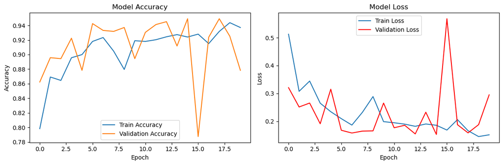

```python
def plot_accuracy_loss(history):

    # Extract values from the history
    accuracy = history.history['accuracy']
    val_accuracy = history.history['val_accuracy']
    loss = history.history['loss']
    val_loss = history.history['val_loss']

    # Get the number of epochs
    epochs = range(1, len(accuracy) + 1)

    # Create the plots
    plt.figure(figsize=(12, 4))

    # Plot training and validation accuracy
    plt.subplot(1, 2, 1)
    plt.plot(accuracy, label='Train Accuracy')
    plt.plot(val_accuracy, label='Validation Accuracy')
    plt.title('Model Accuracy')
    plt.xlabel('Epoch')
    plt.ylabel('Accuracy')
    # plt.ylim(0.65, 0.95)  # Set y-axis limits
    plt.legend(loc='best')
    # plt.grid()

    # Plot training and validation loss
    plt.subplot(1, 2, 2)
    plt.plot(loss, label='Train Loss')
    plt.plot(val_loss, 'r-', label='Validation Loss')
    plt.title('Model Loss')
    plt.xlabel('Epoch')
    plt.ylabel('Loss')
    plt.legend(loc='best')
    # plt.grid()

    plt.tight_layout()
    plt.show()

# Plot the graphs
plot_accuracy_loss(history)
```

The baseline model significantly outperforms the naive baseline. With a test accuracy of 87.3%, the model demonstrates a substantial improvement over the naive baseline accuracy of 74%. This indicates that the model is effectively distinguishing between the two classes (No Pneumonia and Pneumonia) beyond the simple majority class prediction of the naive baseline.

Precision: The model shows a very high precision of 99.0%, suggesting that when it predicts pneumonia, it is highly accurate in its predictions. This high precision indicates that the model is very effective in minimizing false positives.

Recall: The recall is 83.6%, reflecting the model's ability to correctly identify actual cases of pneumonia. Although not as high as the precision, this recall value indicates that the model is reasonably effective at detecting positive cases.

F1 Score: The F1 Score of 90.6% balances precision and recall, providing a comprehensive measure of the model's performance. This score is particularly important for evaluating the model in the context of imbalanced datasets.

## 6. Scaling Up

Scaling up the model involves enhancing its complexity to potentially improve performance on more intricate tasks or datasets. This can be achieved by increasing the number of layers or units in the neural network.

In this project, we will create a more complex model designed to potentially overfit the training data. This overfitting model will help us analyze the effects of increased network complexity on performance. By intentionally pushing the model to overfit, we can better understand how additional layers and units impact the model’s learning and generalization capabilities. This analysis will help us in finding the right balance between model complexity and generalization to achieve optimal performance.

### 6.1 Overfitting

Overfitting occurs when a model has learned the training data excessively, capturing not only the underlying patterns but also the noise and outliers. This results in excellent performance on the training data but poor generalization to new, unseen data. Our aim here is to investigate how to detect overfitting and implement strategies to address it.

Below is a model designed to overfit. The model includes multiple hidden layers with a substantial number of units, creating a complex network architecture that is prone to overfitting. We will analyze its performance and examine methods to mitigate overfitting in subsequent steps.This model includes multiple hidden layers with a substantial number of units, creating a complex network architecture that is prone to overfitting. We will analyze its performance and examine methods to mitigate overfitting in subsequent steps.

```python
# Define the overfitting model with more hidden layers
overfitting_model = Sequential([
    Flatten(input_shape=(64, 64, 3)),  # Flatten the 3D image to 1D
    Dense(256, activation='relu'),  # Second dense layer with 256 units
    Dense(128, activation='relu'),  # Third dense layer with 128 units
    Dense(64, activation='relu'),   # Fourth dense layer with 64 units
    Dense(32, activation='relu'),   # Fifth dense layer with 32 units
    Dense(1, activation='sigmoid')  # Single output neuron for binary classification
])

# Compile the model
overfitting_model.compile(optimizer=Adam(learning_rate=0.001), loss='binary_crossentropy',
                   metrics=['accuracy', Precision(name='precision'), Recall(name='recall'), F1Score(name='f1', average='micro')])

# Print the model summary to check the structure
overfitting_model.summary()
```

```
Model: "sequential_14"
```

```
┏━━━━━━━━━━━━━━━━━━━━━━━━━━━━━━━━━┳━━━━━━━━━━━━━━━━━━━━━━━━┳━━━━━━━━━━━━━━━┓
┃ Layer (type)                    ┃ Output Shape           ┃       Param # ┃
┡━━━━━━━━━━━━━━━━━━━━━━━━━━━━━━━━━╇━━━━━━━━━━━━━━━━━━━━━━━━╇━━━━━━━━━━━━━━━┩
│ flatten_14 (Flatten)            │ (None, 12288)          │             0 │
├─────────────────────────────────┼────────────────────────┼───────────────┤
│ dense_67 (Dense)                │ (None, 256)            │     3,145,984 │
├─────────────────────────────────┼────────────────────────┼───────────────┤
│ dense_68 (Dense)                │ (None, 128)            │        32,896 │
├─────────────────────────────────┼────────────────────────┼───────────────┤
│ dense_69 (Dense)                │ (None, 64)             │         8,256 │
├─────────────────────────────────┼────────────────────────┼───────────────┤
│ dense_70 (Dense)                │ (None, 32)             │         2,080 │
├─────────────────────────────────┼────────────────────────┼───────────────┤
│ dense_71 (Dense)                │ (None, 1)              │            33 │
└─────────────────────────────────┴────────────────────────┴───────────────┘
```

```
 Total params: 3,189,249 (12.17 MB)
```

```
 Trainable params: 3,189,249 (12.17 MB)
```

```
 Non-trainable params: 0 (0.00 B)
```

```python
# Train the overfitting model
history_overfit = overfitting_model.fit(
    train_images,
    train_binary_labels,
    validation_data=(val_images, val_binary_labels),
    epochs=50,  # Train for more epochs to encourage overfitting
    batch_size=16,  # Smaller batch size can also contribute to overfitting
    verbose=2
)
```

```
187/187 - 7s - 38ms/step - accuracy: 0.8187 - f1: 0.8488 - loss: 0.4588 - precision: 0.8635 - recall: 0.8956 - val_accuracy: 0.8302 - val_f1: 0.8492 - val_loss: 0.4275 - val_precision: 0.8139 - val_recall: 0.9982
187/187 - 4s - 21ms/step - accuracy: 0.8949 - f1: 0.8488 - loss: 0.2450 - precision: 0.9200 - recall: 0.9392 - val_accuracy: 0.9398 - val_f1: 0.8492 - val_loss: 0.1779 - val_precision: 0.9393 - val_recall: 0.9819
187/187 - 4s - 21ms/step - accuracy: 0.9107 - f1: 0.8488 - loss: 0.2243 - precision: 0.9349 - recall: 0.9446 - val_accuracy: 0.9078 - val_f1: 0.8492 - val_loss: 0.2066 - val_precision: 0.9726 - val_recall: 0.9004
187/187 - 4s - 21ms/step - accuracy: 0.9237 - f1: 0.8488 - loss: 0.1922 - precision: 0.9434 - recall: 0.9537 - val_accuracy: 0.9265 - val_f1: 0.8492 - val_loss: 0.1914 - val_precision: 0.9149 - val_recall: 0.9928
187/187 - 4s - 21ms/step - accuracy: 0.9160 - f1: 0.8488 - loss: 0.2098 - precision: 0.9334 - recall: 0.9542 - val_accuracy: 0.9278 - val_f1: 0.8492 - val_loss: 0.1800 - val_precision: 0.9752 - val_recall: 0.9257
187/187 - 4s - 21ms/step - accuracy: 0.9100 - f1: 0.8488 - loss: 0.2077 - precision: 0.9344 - recall: 0.9442 - val_accuracy: 0.9398 - val_f1: 0.8492 - val_loss: 0.1748 - val_precision: 0.9363 - val_recall: 0.9855
187/187 - 4s - 21ms/step - accuracy: 0.9301 - f1: 0.8488 - loss: 0.1867 - precision: 0.9483 - recall: 0.9574 - val_accuracy: 0.9465 - val_f1: 0.8492 - val_loss: 0.1702 - val_precision: 0.9604 - val_recall: 0.9674
187/187 - 4s - 22ms/step - accuracy: 0.9321 - f1: 0.8488 - loss: 0.1721 - precision: 0.9477 - recall: 0.9610 - val_accuracy: 0.9398 - val_f1: 0.8492 - val_loss: 0.1584 - val_precision: 0.9686 - val_recall: 0.9493
187/187 - 4s - 20ms/step - accuracy: 0.9277 - f1: 0.8488 - loss: 0.1853 - precision: 0.9414 - recall: 0.9619 - val_accuracy: 0.9439 - val_f1: 0.8492 - val_loss: 0.1523 - val_precision: 0.9554 - val_recall: 0.9692
187/187 - 4s - 21ms/step - accuracy: 0.9271 - f1: 0.8488 - loss: 0.1857 - precision: 0.9429 - recall: 0.9592 - val_accuracy: 0.9412 - val_f1: 0.8492 - val_loss: 0.1527 - val_precision: 0.9536 - val_recall: 0.9674
187/187 - 4s - 21ms/step - accuracy: 0.9404 - f1: 0.8488 - loss: 0.1612 - precision: 0.9530 - recall: 0.9669 - val_accuracy: 0.9425 - val_f1: 0.8492 - val_loss: 0.1853 - val_precision: 0.9336 - val_recall: 0.9928
187/187 - 4s - 20ms/step - accuracy: 0.9297 - f1: 0.8488 - loss: 0.1806 - precision: 0.9451 - recall: 0.9605 - val_accuracy: 0.9332 - val_f1: 0.8492 - val_loss: 0.1842 - val_precision: 0.9197 - val_recall: 0.9964
187/187 - 4s - 21ms/step - accuracy: 0.9324 - f1: 0.8488 - loss: 0.1661 - precision: 0.9453 - recall: 0.9642 - val_accuracy: 0.9051 - val_f1: 0.8492 - val_loss: 0.2172 - val_precision: 0.8873 - val_recall: 0.9982
187/187 - 4s - 21ms/step - accuracy: 0.9297 - f1: 0.8488 - loss: 0.1732 - precision: 0.9400 - recall: 0.9664 - val_accuracy: 0.9011 - val_f1: 0.8492 - val_loss: 0.2429 - val_precision: 0.9799 - val_recall: 0.8841
187/187 - 4s - 20ms/step - accuracy: 0.9368 - f1: 0.8488 - loss: 0.1651 - precision: 0.9520 - recall: 0.9628 - val_accuracy: 0.9251 - val_f1: 0.8492 - val_loss: 0.1702 - val_precision: 0.9715 - val_recall: 0.9257
187/187 - 4s - 20ms/step - accuracy: 0.9317 - f1: 0.8488 - loss: 0.1689 - precision: 0.9488 - recall: 0.9592 - val_accuracy: 0.9318 - val_f1: 0.8492 - val_loss: 0.1674 - val_precision: 0.9718 - val_recall: 0.9348
187/187 - 4s - 20ms/step - accuracy: 0.9381 - f1: 0.8488 - loss: 0.1612 - precision: 0.9493 - recall: 0.9678 - val_accuracy: 0.9118 - val_f1: 0.8492 - val_loss: 0.2352 - val_precision: 0.9821 - val_recall: 0.8967
187/187 - 4s - 20ms/step - accuracy: 0.9518 - f1: 0.8488 - loss: 0.1447 - precision: 0.9631 - recall: 0.9719 - val_accuracy: 0.9345 - val_f1: 0.8492 - val_loss: 0.1822 - val_precision: 0.9270 - val_recall: 0.9891
187/187 - 4s - 21ms/step - accuracy: 0.9415 - f1: 0.8488 - loss: 0.1529 - precision: 0.9519 - recall: 0.9696 - val_accuracy: 0.9372 - val_f1: 0.8492 - val_loss: 0.2003 - val_precision: 0.9272 - val_recall: 0.9928
187/187 - 4s - 21ms/step - accuracy: 0.9431 - f1: 0.8488 - loss: 0.1455 - precision: 0.9540 - recall: 0.9696 - val_accuracy: 0.9505 - val_f1: 0.8492 - val_loss: 0.1457 - val_precision: 0.9623 - val_recall: 0.9710
187/187 - 4s - 21ms/step - accuracy: 0.9351 - f1: 0.8488 - loss: 0.1644 - precision: 0.9479 - recall: 0.9651 - val_accuracy: 0.9278 - val_f1: 0.8492 - val_loss: 0.1715 - val_precision: 0.9752 - val_recall: 0.9257
187/187 - 4s - 20ms/step - accuracy: 0.9415 - f1: 0.8488 - loss: 0.1474 - precision: 0.9543 - recall: 0.9669 - val_accuracy: 0.8984 - val_f1: 0.8492 - val_loss: 0.2391 - val_precision: 0.9837 - val_recall: 0.8768
```

[output cut: 28 more lines]

```python
# Evaluate the overfitting model on the test set
overfitting_metrics = overfitting_model.evaluate(test_images, test_binary_labels, verbose=0)
print(f"Test Loss: {overfitting_metrics[0]:.3f}")
print(f"Test Accuracy: {overfitting_metrics[1]:.3f}")
print(f"Test Precision: {overfitting_metrics[2]:.3f}")
print(f"Test Recall: {overfitting_metrics[3]:.3f}")
print(f"Test F1 Score: {overfitting_metrics[4]:.3f}")
```

```
Test Loss: 0.187
Test Accuracy: 0.930
Test Precision: 0.923
Test Recall: 0.988
Test F1 Score: 0.954
```

The overfitting model achieves high performance metrics with a test accuracy of 93.0%, precision of 92.3%, recall of 98.8%, and an F1 score of 95.4%. The accuracy and precision are relatively high, and recall ad f1 scores are very high indicating good performance on the test data.

[figure not shown]

```python
# Plot training and validation accuracy and loss graphs
plot_accuracy_loss(history_overfit)
```

The accuracy graph shows a gradual increase in performance, which eventually levels off, with occasional outliers. This suggests that while the model initially learns and improves, it eventually reaches a plateau where further training yields diminishing returns.

The loss graph shows that the validation loss starts below the training loss and decreases to approximately 0.15 around epoch 10. This indicates that the model initially generalizes well. After this, the validation loss begins to rise, eventually surpassing the training loss around epoch 15. This is a clear indicator of overfitting, where the model starts to memorize the training data, leading to worse performance on the validation set. In summary, the overfitting model demonstrates high accuracy and low loss on the training data, but its generalization performance deteriorates as evidenced by the rising validation loss. This analysis highlights the need to implement regularization techniques or simplify the model to prevent overfitting and enhance generalization.

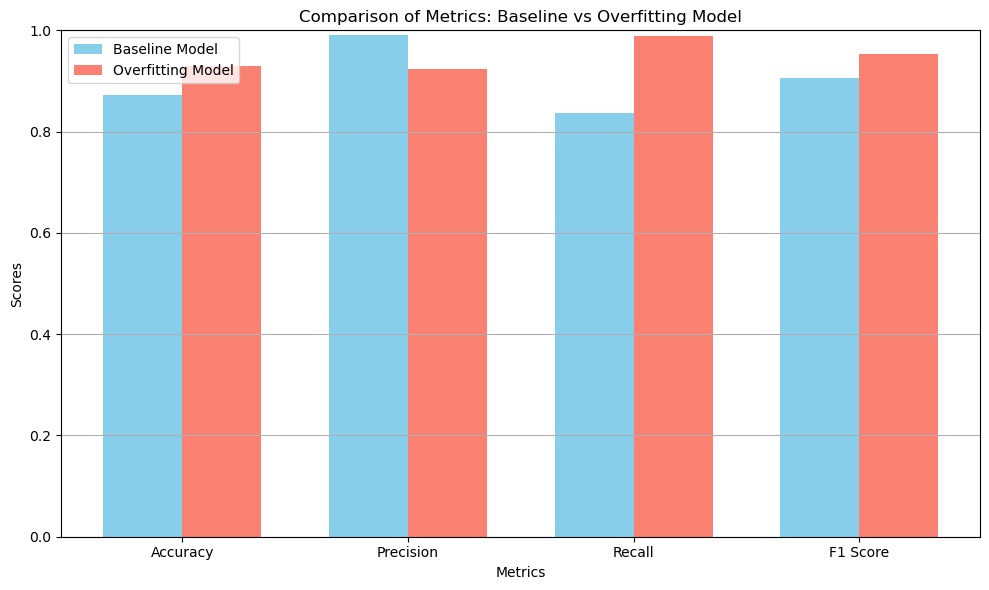

```python
# Extracting relevant Metric Scores
baseline_scores = {'Accuracy': baseline_metrics[1], 'Precision': baseline_metrics[2], 'Recall': baseline_metrics[3], 'F1 Score': baseline_metrics[4]}
overfitting_scores = {'Accuracy': overfitting_metrics[1], 'Precision': overfitting_metrics[2], 'Recall': overfitting_metrics[3], 'F1 Score': overfitting_metrics[4]}

# Extract metric names and their values
metrics = list(baseline_scores.keys())
baseline_values = list(baseline_scores.values())
overfit_values = list(overfitting_scores.values())

# Create an index for the groups
x = np.arange(len(metrics))

# Define the width of the bars
width = 0.35

# Plotting the bar chart
plt.figure(figsize=(10, 6))
plt.bar(x - width/2, baseline_values, width, label='Baseline Model', color='skyblue')
plt.bar(x + width/2, overfit_values, width, label='Overfitting Model', color='salmon')

# Adding labels and title
plt.xlabel('Metrics')
plt.ylabel('Scores')
plt.title('Comparison of Metrics: Baseline vs Overfitting Model')
plt.xticks(x, metrics)
plt.ylim(0, 1)  # Limits from 0 to 1 for better visualization of percentage-based scores
plt.legend(loc='best')

plt.grid(axis='y')
plt.tight_layout()
plt.show()
```

## 7. Regularizing your model and tuning your hyperparameters

This section aims to enhance the model's performance by refining its architecture and adjusting hyperparameters through an iterative process. This involves repeatedly modifying the model, training it, and evaluating it on a validation set until the optimal performance is achieved. We'll explore various strategies, such as applying regularization techniques, experimenting with different model architectures, adjusting hyperparameters, and implementing K-Fold cross-validation.

To create a well-optimized model for our data, we will conduct several tests in the following sections:

- Regularization Techniques: Implementing dropout, L1, and L2 regularization.
- Experimenting with Different Architectures: Testing various numbers of hidden layers and neurons, incorporating wider and deeper architectures, using early stopping and trying different learning rate optimizers and epoch counts.
- Hyperparameter Tuning with K-Fold Cross-Validation: Fine-tuning the model to identify the best-performing combination of hyperparameters.

### 7.1 Regularization Techniques

#### 7.1.1 Dropout Regularization

Dropout is a straightforward and effective method for minimizing overfitting. It works by randomly setting a portion of the input units to zero during each training update, preventing the model from becoming overly dependent on particular neurons. In the next model, I have incorporated two dropout layers to apply this technique.

```python
# Define model with Dropout Layers
dropout_model = Sequential([
    Flatten(input_shape=(64, 64, 3)),
    Dense(128, activation='relu'), # First dense layer with 128 units
    Dropout(0.3),  # Dropout rate of 30%
    Dense(64, activation='relu'), # Second dense layer with 64 units
    Dropout(0.3), # Another dropout layer
    Dense(1, activation='sigmoid') # Single output neuron for binary classification
])

# Compile the model
dropout_model.compile(optimizer=Adam(learning_rate=0.001), loss='binary_crossentropy',
                   metrics=['accuracy', Precision(name='precision'), Recall(name='recall'), F1Score(name='f1', average='micro')])
```

```python
# Train the dropout model
history_dropout = dropout_model.fit(
    train_images,
    train_binary_labels,
    validation_data=(val_images, val_binary_labels),
    epochs=20,
    batch_size=32,
    verbose=2,
    class_weight=class_weights_dict
)
```

```
94/94 - 3s - 37ms/step - accuracy: 0.7093 - f1: 0.8488 - loss: 0.8151 - precision: 0.8739 - recall: 0.7078 - val_accuracy: 0.8663 - val_f1: 0.8492 - val_loss: 0.3238 - val_precision: 0.9612 - val_recall: 0.8533
94/94 - 1s - 12ms/step - accuracy: 0.8354 - f1: 0.8488 - loss: 0.3894 - precision: 0.9310 - recall: 0.8389 - val_accuracy: 0.9118 - val_f1: 0.8492 - val_loss: 0.2764 - val_precision: 0.9620 - val_recall: 0.9167
94/94 - 1s - 12ms/step - accuracy: 0.8525 - f1: 0.8488 - loss: 0.3318 - precision: 0.9445 - recall: 0.8498 - val_accuracy: 0.9037 - val_f1: 0.8492 - val_loss: 0.2297 - val_precision: 0.9724 - val_recall: 0.8949
94/94 - 1s - 11ms/step - accuracy: 0.8060 - f1: 0.8488 - loss: 0.3453 - precision: 0.9481 - recall: 0.7795 - val_accuracy: 0.8249 - val_f1: 0.8492 - val_loss: 0.4168 - val_precision: 0.9839 - val_recall: 0.7754
94/94 - 1s - 12ms/step - accuracy: 0.8063 - f1: 0.8488 - loss: 0.4355 - precision: 0.8729 - recall: 0.8630 - val_accuracy: 0.9385 - val_f1: 0.8492 - val_loss: 0.4529 - val_precision: 0.9534 - val_recall: 0.9638
94/94 - 1s - 12ms/step - accuracy: 0.8274 - f1: 0.8488 - loss: 0.4524 - precision: 0.8660 - recall: 0.9061 - val_accuracy: 0.8717 - val_f1: 0.8492 - val_loss: 0.3451 - val_precision: 0.9851 - val_recall: 0.8388
94/94 - 1s - 12ms/step - accuracy: 0.8618 - f1: 0.8488 - loss: 0.3646 - precision: 0.8842 - recall: 0.9351 - val_accuracy: 0.9425 - val_f1: 0.8492 - val_loss: 0.1942 - val_precision: 0.9520 - val_recall: 0.9710
94/94 - 1s - 12ms/step - accuracy: 0.8568 - f1: 0.8488 - loss: 0.3796 - precision: 0.8756 - recall: 0.9392 - val_accuracy: 0.9465 - val_f1: 0.8492 - val_loss: 0.1739 - val_precision: 0.9539 - val_recall: 0.9746
94/94 - 1s - 12ms/step - accuracy: 0.8628 - f1: 0.8488 - loss: 0.4473 - precision: 0.8788 - recall: 0.9442 - val_accuracy: 0.8890 - val_f1: 0.8492 - val_loss: 0.5229 - val_precision: 0.9875 - val_recall: 0.8605
94/94 - 1s - 12ms/step - accuracy: 0.8612 - f1: 0.8488 - loss: 0.4369 - precision: 0.8757 - recall: 0.9460 - val_accuracy: 0.9078 - val_f1: 0.8492 - val_loss: 0.2699 - val_precision: 0.9763 - val_recall: 0.8967
94/94 - 1s - 12ms/step - accuracy: 0.8397 - f1: 0.8488 - loss: 0.4337 - precision: 0.8490 - recall: 0.9519 - val_accuracy: 0.8449 - val_f1: 0.8492 - val_loss: 0.3433 - val_precision: 0.8263 - val_recall: 1.0000
94/94 - 1s - 12ms/step - accuracy: 0.8581 - f1: 0.8488 - loss: 0.3841 - precision: 0.8739 - recall: 0.9437 - val_accuracy: 0.9238 - val_f1: 0.8492 - val_loss: 0.1807 - val_precision: 0.9732 - val_recall: 0.9221
94/94 - 1s - 11ms/step - accuracy: 0.8592 - f1: 0.8488 - loss: 0.3668 - precision: 0.8786 - recall: 0.9387 - val_accuracy: 0.9532 - val_f1: 0.8492 - val_loss: 0.2681 - val_precision: 0.9608 - val_recall: 0.9764
94/94 - 1s - 11ms/step - accuracy: 0.8585 - f1: 0.8488 - loss: 0.3787 - precision: 0.8743 - recall: 0.9437 - val_accuracy: 0.9465 - val_f1: 0.8492 - val_loss: 0.3194 - val_precision: 0.9621 - val_recall: 0.9656
94/94 - 1s - 11ms/step - accuracy: 0.8632 - f1: 0.8488 - loss: 0.3656 - precision: 0.8805 - recall: 0.9424 - val_accuracy: 0.9305 - val_f1: 0.8492 - val_loss: 0.1730 - val_precision: 0.9682 - val_recall: 0.9366
94/94 - 1s - 11ms/step - accuracy: 0.8531 - f1: 0.8488 - loss: 0.3669 - precision: 0.8694 - recall: 0.9424 - val_accuracy: 0.8690 - val_f1: 0.8492 - val_loss: 0.3022 - val_precision: 0.9850 - val_recall: 0.8351
94/94 - 1s - 11ms/step - accuracy: 0.8786 - f1: 0.8488 - loss: 0.3345 - precision: 0.8983 - recall: 0.9419 - val_accuracy: 0.9011 - val_f1: 0.8492 - val_loss: 0.2374 - val_precision: 0.9838 - val_recall: 0.8804
94/94 - 1s - 11ms/step - accuracy: 0.8508 - f1: 0.8488 - loss: 0.3144 - precision: 0.9085 - recall: 0.8870 - val_accuracy: 0.9198 - val_f1: 0.8492 - val_loss: 0.1781 - val_precision: 0.9731 - val_recall: 0.9167
94/94 - 1s - 11ms/step - accuracy: 0.8484 - f1: 0.8488 - loss: 0.2916 - precision: 0.9684 - recall: 0.8212 - val_accuracy: 0.9251 - val_f1: 0.8492 - val_loss: 0.1731 - val_precision: 0.9751 - val_recall: 0.9221
94/94 - 1s - 12ms/step - accuracy: 0.8334 - f1: 0.8488 - loss: 0.3026 - precision: 0.9718 - recall: 0.7972 - val_accuracy: 0.8810 - val_f1: 0.8492 - val_loss: 0.2842 - val_precision: 0.9853 - val_recall: 0.8514
```

```python
# Evaluate the model on the test set
dropout_metrics = dropout_model.evaluate(test_images, test_binary_labels, verbose=0)
print(f"Test Loss: {dropout_metrics[0]:.3f}")
print(f"Test Accuracy: {dropout_metrics[1]:.3f}")
print(f"Test Precision: {dropout_metrics[2]:.3f}")
print(f"Test Recall: {dropout_metrics[3]:.3f}")
print(f"Test F1 Score: {dropout_metrics[4]:.3f}")
```

```
Test Loss: 0.290
Test Accuracy: 0.873
Test Precision: 0.991
Test Recall: 0.835
Test F1 Score: 0.906
```

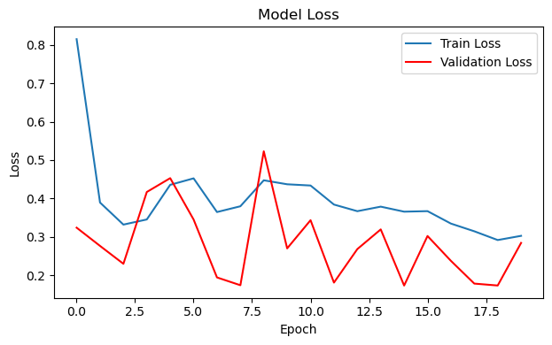

```python
# Plot training and validation loss graphs
def plot_loss(history):

    # Extract values from the history
    loss = history.history['loss']
    val_loss = history.history['val_loss']

    # Get the number of epochs
    epochs = range(1, len(loss) + 1)

    # Create the plots
    plt.figure(figsize=(12, 4))

    # Plot training and validation loss
    plt.subplot(1, 2, 1)
    plt.plot(loss, label='Train Loss')
    plt.plot(val_loss, 'r-', label='Validation Loss')
    plt.title('Model Loss')
    plt.xlabel('Epoch')
    plt.ylabel('Loss')
    plt.legend(loc='best')
    # plt.grid()

    plt.tight_layout()
    plt.show()

plot_loss(history_dropout)
```

The dropout model's results are still quite strong, with a test accuracy of 87.3%, a precision of 99.1%, a recall of 83.5%, and an F1 score of 90.6%. These metrics indicate that the model is performing well, and dropout has effectively reduced overfitting without significantly compromising performance. However, the loss graph shows numerous outliers and appears quite erratic, suggesting that further tuning or additional regularization might be needed. Given these results, dropout will continue to be utilized in the next section to refine the model further.

#### 7.1.2 L1 and L2 Regularization

L1 and L2 regularization introduce penalties to the loss function by incorporating either the absolute values (L1) or the squared values (L2) of the model's weights. These penalties help prevent the model from learning overly complex patterns that may not generalize effectively to unseen data. I will proceed to test 3 different models, using only L1, using only L2 then a combined model to see which is the most effective.

##### 7.1.2.1 L1 model

```python
# Define model with l1 regularizer
l1_model = Sequential([
    Flatten(input_shape=(64, 64, 3)),
    Dense(128, activation='relu', kernel_regularizer=l1(0.01)),  # L1 regularization
    Dense(64, activation='relu'),
    Dense(1, activation='sigmoid')
])

# Compile the model
l1_model.compile(optimizer=Adam(learning_rate=0.001), loss='binary_crossentropy',
                   metrics=['accuracy', Precision(name='precision'), Recall(name='recall'), F1Score(name='f1', average='micro')])
```

```python
# Train the model
history_l1 = l1_model.fit(
    train_images,
    train_binary_labels,
    validation_data=(val_images, val_binary_labels),
    epochs=20,
    batch_size=32,
    verbose=2,
    class_weight=class_weights_dict
)
```

```
94/94 - 4s - 39ms/step - accuracy: 0.5644 - f1: 0.8488 - loss: 22.5320 - precision: 0.7701 - recall: 0.5835 - val_accuracy: 0.7380 - val_f1: 0.8492 - val_loss: 3.5579 - val_precision: 0.7380 - val_recall: 1.0000
94/94 - 1s - 15ms/step - accuracy: 0.4968 - f1: 0.8488 - loss: 3.2543 - precision: 0.7340 - recall: 0.4982 - val_accuracy: 0.2620 - val_f1: 0.8492 - val_loss: 2.9670 - val_precision: 0.0000e+00 - val_recall: 0.0000e+00
94/94 - 1s - 15ms/step - accuracy: 0.5135 - f1: 0.8488 - loss: 2.8918 - precision: 0.7619 - recall: 0.4950 - val_accuracy: 0.7380 - val_f1: 0.8492 - val_loss: 2.7535 - val_precision: 0.7380 - val_recall: 1.0000
94/94 - 1s - 15ms/step - accuracy: 0.4788 - f1: 0.8488 - loss: 2.7945 - precision: 0.7432 - recall: 0.4478 - val_accuracy: 0.2620 - val_f1: 0.8492 - val_loss: 3.1616 - val_precision: 0.0000e+00 - val_recall: 0.0000e+00
94/94 - 1s - 15ms/step - accuracy: 0.5042 - f1: 0.8488 - loss: 2.9174 - precision: 0.7497 - recall: 0.4918 - val_accuracy: 0.2620 - val_f1: 0.8492 - val_loss: 2.9684 - val_precision: 0.0000e+00 - val_recall: 0.0000e+00
94/94 - 1s - 15ms/step - accuracy: 0.4711 - f1: 0.8488 - loss: 2.8744 - precision: 0.7466 - recall: 0.4279 - val_accuracy: 0.7380 - val_f1: 0.8492 - val_loss: 2.7398 - val_precision: 0.7380 - val_recall: 1.0000
94/94 - 1s - 15ms/step - accuracy: 0.5119 - f1: 0.8488 - loss: 2.8411 - precision: 0.7610 - recall: 0.4927 - val_accuracy: 0.7380 - val_f1: 0.8492 - val_loss: 2.7196 - val_precision: 0.7380 - val_recall: 1.0000
94/94 - 1s - 14ms/step - accuracy: 0.4928 - f1: 0.8488 - loss: 2.8286 - precision: 0.7324 - recall: 0.4918 - val_accuracy: 0.7380 - val_f1: 0.8492 - val_loss: 2.8735 - val_precision: 0.7380 - val_recall: 1.0000
94/94 - 1s - 14ms/step - accuracy: 0.5376 - f1: 0.8488 - loss: 2.8284 - precision: 0.7641 - recall: 0.5395 - val_accuracy: 0.7380 - val_f1: 0.8492 - val_loss: 2.6936 - val_precision: 0.7380 - val_recall: 1.0000
94/94 - 1s - 14ms/step - accuracy: 0.5457 - f1: 0.8488 - loss: 2.7418 - precision: 0.7533 - recall: 0.5708 - val_accuracy: 0.2620 - val_f1: 0.8492 - val_loss: 2.7042 - val_precision: 0.0000e+00 - val_recall: 0.0000e+00
94/94 - 1s - 14ms/step - accuracy: 0.5383 - f1: 0.8488 - loss: 2.7895 - precision: 0.7458 - recall: 0.5672 - val_accuracy: 0.2620 - val_f1: 0.8492 - val_loss: 2.7262 - val_precision: 0.0000e+00 - val_recall: 0.0000e+00
94/94 - 1s - 15ms/step - accuracy: 0.5079 - f1: 0.8488 - loss: 2.7021 - precision: 0.7468 - recall: 0.5032 - val_accuracy: 0.2620 - val_f1: 0.8492 - val_loss: 2.9123 - val_precision: 0.0000e+00 - val_recall: 0.0000e+00
94/94 - 1s - 14ms/step - accuracy: 0.5069 - f1: 0.8488 - loss: 2.7045 - precision: 0.7517 - recall: 0.4946 - val_accuracy: 0.7380 - val_f1: 0.8492 - val_loss: 2.6904 - val_precision: 0.7380 - val_recall: 1.0000
94/94 - 1s - 15ms/step - accuracy: 0.5326 - f1: 0.8488 - loss: 2.6708 - precision: 0.7378 - recall: 0.5681 - val_accuracy: 0.8075 - val_f1: 0.8492 - val_loss: 2.6508 - val_precision: 0.8100 - val_recall: 0.9656
94/94 - 1s - 15ms/step - accuracy: 0.5320 - f1: 0.8488 - loss: 2.6966 - precision: 0.7453 - recall: 0.5549 - val_accuracy: 0.7380 - val_f1: 0.8492 - val_loss: 2.6214 - val_precision: 0.7380 - val_recall: 1.0000
94/94 - 1s - 15ms/step - accuracy: 0.5276 - f1: 0.8488 - loss: 2.6591 - precision: 0.7324 - recall: 0.5662 - val_accuracy: 0.7380 - val_f1: 0.8492 - val_loss: 2.6353 - val_precision: 0.7380 - val_recall: 1.0000
94/94 - 1s - 15ms/step - accuracy: 0.5390 - f1: 0.8488 - loss: 2.6430 - precision: 0.7393 - recall: 0.5789 - val_accuracy: 0.7380 - val_f1: 0.8492 - val_loss: 2.5975 - val_precision: 0.7380 - val_recall: 1.0000
94/94 - 1s - 15ms/step - accuracy: 0.5373 - f1: 0.8488 - loss: 2.6510 - precision: 0.7511 - recall: 0.5572 - val_accuracy: 0.2874 - val_f1: 0.8492 - val_loss: 2.6621 - val_precision: 1.0000 - val_recall: 0.0344
94/94 - 1s - 15ms/step - accuracy: 0.5671 - f1: 0.8488 - loss: 2.6060 - precision: 0.7462 - recall: 0.6257 - val_accuracy: 0.7500 - val_f1: 0.8492 - val_loss: 2.5923 - val_precision: 0.7490 - val_recall: 0.9946
94/94 - 1s - 15ms/step - accuracy: 0.5206 - f1: 0.8488 - loss: 2.6289 - precision: 0.7285 - recall: 0.5576 - val_accuracy: 0.3783 - val_f1: 0.8492 - val_loss: 2.5768 - val_precision: 0.8991 - val_recall: 0.1775
```

```python
# Evaluate the model on the test set
l1_metrics = l1_model.evaluate(test_images, test_binary_labels, verbose=0)
print(f"Test Loss: {l1_metrics[0]:.3f}")
print(f"Test Accuracy: {l1_metrics[1]:.3f}")
print(f"Test Precision: {l1_metrics[2]:.3f}")
print(f"Test Recall: {l1_metrics[3]:.3f}")
print(f"Test F1 Score: {l1_metrics[4]:.3f}")
```

```
Test Loss: 2.576
Test Accuracy: 0.384
Test Precision: 0.959
Test Recall: 0.171
Test F1 Score: 0.290
```

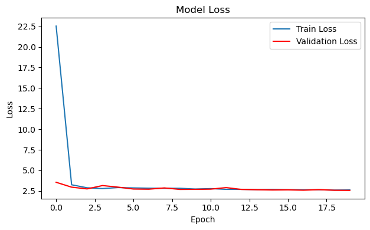

```python
# Plot training and validation loss graphs
plot_loss(history_l1)
```

The L1 regularization model shows a high test loss of 2.576, indicating that it struggles to fit the data effectively. The test accuracy is quite low at 0.384, which suggests poor overall performance. Precision is relatively high at 0.959, but this is counterbalanced by a very low recall of 0.171, reflecting that the model is overly conservative in its predictions, missing many true positives. The F1 score of 0.290, which balances precision and recall, is also low. The validation loss curve stagnates at around 2.5, indicating that the model fails to learn beyond a certain point, likely due to the strong penalty imposed by L1 regularization.

##### 7.1.2.2 L2 model

```python
# Define model with l2 regularizer
l2_model = Sequential([
    Flatten(input_shape=(64, 64, 3)),
    Dense(128, activation='relu', kernel_regularizer=l2(0.01)),  # L2 regularization
    Dense(64, activation='relu'),
    Dense(1, activation='sigmoid')
])

# Compile the model
l2_model.compile(optimizer=Adam(learning_rate=0.001), loss='binary_crossentropy',
                   metrics=['accuracy', Precision(name='precision'), Recall(name='recall'), F1Score(name='f1', average='micro')])
```

```python
# Train the model
history_l2 = l2_model.fit(
    train_images,
    train_binary_labels,
    validation_data=(val_images, val_binary_labels),
    epochs=20,
    batch_size=32,
    verbose=2,
    class_weight=class_weights_dict
)
```

```
94/94 - 4s - 44ms/step - accuracy: 0.7427 - f1: 0.8488 - loss: 1.8328 - precision: 0.8902 - recall: 0.7427 - val_accuracy: 0.8476 - val_f1: 0.8492 - val_loss: 1.0210 - val_precision: 0.8298 - val_recall: 0.9982
94/94 - 1s - 14ms/step - accuracy: 0.8414 - f1: 0.8488 - loss: 0.8703 - precision: 0.9373 - recall: 0.8412 - val_accuracy: 0.9144 - val_f1: 0.8492 - val_loss: 0.5057 - val_precision: 0.9656 - val_recall: 0.9167
94/94 - 1s - 15ms/step - accuracy: 0.8852 - f1: 0.8488 - loss: 0.5097 - precision: 0.9541 - recall: 0.8870 - val_accuracy: 0.8890 - val_f1: 0.8492 - val_loss: 0.4346 - val_precision: 0.9815 - val_recall: 0.8659
94/94 - 1s - 15ms/step - accuracy: 0.9006 - f1: 0.8488 - loss: 0.3983 - precision: 0.9609 - recall: 0.9020 - val_accuracy: 0.7634 - val_f1: 0.8492 - val_loss: 0.6882 - val_precision: 0.9921 - val_recall: 0.6848
94/94 - 1s - 15ms/step - accuracy: 0.8722 - f1: 0.8488 - loss: 0.4285 - precision: 0.9532 - recall: 0.8693 - val_accuracy: 0.9412 - val_f1: 0.8492 - val_loss: 0.2920 - val_precision: 0.9504 - val_recall: 0.9710
94/94 - 1s - 14ms/step - accuracy: 0.8946 - f1: 0.8488 - loss: 0.3557 - precision: 0.9583 - recall: 0.8961 - val_accuracy: 0.9171 - val_f1: 0.8492 - val_loss: 0.2900 - val_precision: 0.9730 - val_recall: 0.9130
94/94 - 1s - 14ms/step - accuracy: 0.8996 - f1: 0.8488 - loss: 0.3295 - precision: 0.9621 - recall: 0.8993 - val_accuracy: 0.7928 - val_f1: 0.8492 - val_loss: 0.5809 - val_precision: 0.9853 - val_recall: 0.7301
94/94 - 1s - 15ms/step - accuracy: 0.9013 - f1: 0.8488 - loss: 0.2979 - precision: 0.9636 - recall: 0.9002 - val_accuracy: 0.9011 - val_f1: 0.8492 - val_loss: 0.3109 - val_precision: 0.9780 - val_recall: 0.8859
94/94 - 1s - 15ms/step - accuracy: 0.8970 - f1: 0.8488 - loss: 0.3028 - precision: 0.9615 - recall: 0.8961 - val_accuracy: 0.9037 - val_f1: 0.8492 - val_loss: 0.2892 - val_precision: 0.9781 - val_recall: 0.8895
94/94 - 1s - 15ms/step - accuracy: 0.8903 - f1: 0.8488 - loss: 0.3049 - precision: 0.9598 - recall: 0.8884 - val_accuracy: 0.9345 - val_f1: 0.8492 - val_loss: 0.2370 - val_precision: 0.9564 - val_recall: 0.9547
94/94 - 1s - 14ms/step - accuracy: 0.9110 - f1: 0.8488 - loss: 0.2783 - precision: 0.9672 - recall: 0.9102 - val_accuracy: 0.9332 - val_f1: 0.8492 - val_loss: 0.2268 - val_precision: 0.9665 - val_recall: 0.9420
94/94 - 1s - 14ms/step - accuracy: 0.9016 - f1: 0.8488 - loss: 0.3081 - precision: 0.9622 - recall: 0.9020 - val_accuracy: 0.8810 - val_f1: 0.8492 - val_loss: 0.3579 - val_precision: 0.9853 - val_recall: 0.8514
94/94 - 1s - 15ms/step - accuracy: 0.9050 - f1: 0.8488 - loss: 0.2852 - precision: 0.9674 - recall: 0.9015 - val_accuracy: 0.8155 - val_f1: 0.8492 - val_loss: 0.4945 - val_precision: 0.9859 - val_recall: 0.7609
94/94 - 1s - 15ms/step - accuracy: 0.9053 - f1: 0.8488 - loss: 0.2685 - precision: 0.9638 - recall: 0.9056 - val_accuracy: 0.9372 - val_f1: 0.8492 - val_loss: 0.2208 - val_precision: 0.9702 - val_recall: 0.9438
94/94 - 1s - 15ms/step - accuracy: 0.8946 - f1: 0.8488 - loss: 0.3036 - precision: 0.9623 - recall: 0.8920 - val_accuracy: 0.8182 - val_f1: 0.8492 - val_loss: 0.5148 - val_precision: 0.8023 - val_recall: 1.0000
94/94 - 1s - 15ms/step - accuracy: 0.9110 - f1: 0.8488 - loss: 0.2946 - precision: 0.9654 - recall: 0.9120 - val_accuracy: 0.9452 - val_f1: 0.8492 - val_loss: 0.2277 - val_precision: 0.9459 - val_recall: 0.9819
94/94 - 1s - 15ms/step - accuracy: 0.8822 - f1: 0.8488 - loss: 0.3372 - precision: 0.9557 - recall: 0.8811 - val_accuracy: 0.8583 - val_f1: 0.8492 - val_loss: 0.3958 - val_precision: 0.9848 - val_recall: 0.8207
94/94 - 1s - 15ms/step - accuracy: 0.9060 - f1: 0.8488 - loss: 0.2795 - precision: 0.9656 - recall: 0.9047 - val_accuracy: 0.8195 - val_f1: 0.8492 - val_loss: 0.4763 - val_precision: 0.9883 - val_recall: 0.7645
94/94 - 1s - 15ms/step - accuracy: 0.8966 - f1: 0.8488 - loss: 0.3035 - precision: 0.9597 - recall: 0.8975 - val_accuracy: 0.8623 - val_f1: 0.8492 - val_loss: 0.4029 - val_precision: 0.9870 - val_recall: 0.8243
94/94 - 1s - 15ms/step - accuracy: 0.9093 - f1: 0.8488 - loss: 0.2924 - precision: 0.9685 - recall: 0.9065 - val_accuracy: 0.8783 - val_f1: 0.8492 - val_loss: 0.3606 - val_precision: 0.9832 - val_recall: 0.8496
```

```python
# Evaluate the model on the test set
l2_metrics = l2_model.evaluate(test_images, test_binary_labels, verbose=0)
print(f"Test Loss: {l2_metrics[0]:.3f}")
print(f"Test Accuracy: {l2_metrics[1]:.3f}")
print(f"Test Precision: {l2_metrics[2]:.3f}")
print(f"Test Recall: {l2_metrics[3]:.3f}")
print(f"Test F1 Score: {l2_metrics[4]:.3f}")
```

```
Test Loss: 0.364
Test Accuracy: 0.870
Test Precision: 0.988
Test Recall: 0.833
Test F1 Score: 0.904
```

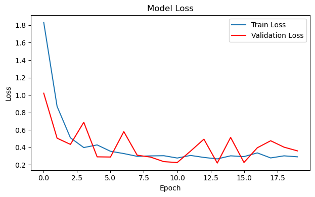

```python
# Plot training and validation loss graphs
plot_loss(history_l2)
```

##### 7.1.2.3 Combined L1 and L2 model

```python
# Define model with l1 and l2 regularizer combined
l1_2_combined_model = Sequential([
    Flatten(input_shape=(64, 64, 3)),
    Dense(128, activation='relu', kernel_regularizer=l1(0.01)),  # L1 regularization
    Dense(64, activation='relu', kernel_regularizer=l2(0.01)),  # L2 regularization
    Dense(1, activation='sigmoid')
])

# Compile the model
l1_2_combined_model.compile(optimizer=Adam(learning_rate=0.001), loss='binary_crossentropy',
                   metrics=['accuracy', Precision(name='precision'), Recall(name='recall'), F1Score(name='f1', average='micro')])
```

```python
# Train the model
history_l1_2_combined = l1_2_combined_model.fit(
    train_images,
    train_binary_labels,
    validation_data=(val_images, val_binary_labels),
    epochs=20,
    batch_size=32,
    verbose=2,
    class_weight=class_weights_dict
)
```

```
94/94 - 1s - 15ms/step - accuracy: 0.6598 - f1: 0.8488 - loss: 2.3927 - precision: 0.7458 - recall: 0.8172 - val_accuracy: 0.7380 - val_f1: 0.8492 - val_loss: 2.3808 - val_precision: 0.7380 - val_recall: 1.0000
94/94 - 1s - 14ms/step - accuracy: 0.5627 - f1: 0.8488 - loss: 2.3897 - precision: 0.7387 - recall: 0.6298 - val_accuracy: 0.7380 - val_f1: 0.8492 - val_loss: 2.3860 - val_precision: 0.7380 - val_recall: 1.0000
94/94 - 1s - 14ms/step - accuracy: 0.6046 - f1: 0.8488 - loss: 2.3874 - precision: 0.7368 - recall: 0.7214 - val_accuracy: 0.7380 - val_f1: 0.8492 - val_loss: 2.3827 - val_precision: 0.7380 - val_recall: 1.0000
94/94 - 1s - 14ms/step - accuracy: 0.6179 - f1: 0.8488 - loss: 2.3804 - precision: 0.7422 - recall: 0.7382 - val_accuracy: 0.6430 - val_f1: 0.8492 - val_loss: 2.3764 - val_precision: 0.7833 - val_recall: 0.7138
94/94 - 1s - 14ms/step - accuracy: 0.5942 - f1: 0.8488 - loss: 2.3739 - precision: 0.7372 - recall: 0.6987 - val_accuracy: 0.7380 - val_f1: 0.8492 - val_loss: 2.3724 - val_precision: 0.7380 - val_recall: 1.0000
94/94 - 1s - 15ms/step - accuracy: 0.6069 - f1: 0.8488 - loss: 2.3678 - precision: 0.7385 - recall: 0.7228 - val_accuracy: 0.7380 - val_f1: 0.8492 - val_loss: 2.3537 - val_precision: 0.7380 - val_recall: 1.0000
94/94 - 1s - 15ms/step - accuracy: 0.5018 - f1: 0.8488 - loss: 2.3663 - precision: 0.7385 - recall: 0.5023 - val_accuracy: 0.7380 - val_f1: 0.8492 - val_loss: 2.3607 - val_precision: 0.7380 - val_recall: 1.0000
94/94 - 1s - 15ms/step - accuracy: 0.6641 - f1: 0.8488 - loss: 2.3623 - precision: 0.7475 - recall: 0.8221 - val_accuracy: 0.7366 - val_f1: 0.8492 - val_loss: 2.3686 - val_precision: 0.7376 - val_recall: 0.9982
94/94 - 1s - 15ms/step - accuracy: 0.6035 - f1: 0.8488 - loss: 2.3662 - precision: 0.7427 - recall: 0.7074 - val_accuracy: 0.2620 - val_f1: 0.8492 - val_loss: 2.3757 - val_precision: 0.0000e+00 - val_recall: 0.0000e+00
94/94 - 1s - 14ms/step - accuracy: 0.5785 - f1: 0.8488 - loss: 2.3642 - precision: 0.7466 - recall: 0.6484 - val_accuracy: 0.7380 - val_f1: 0.8492 - val_loss: 2.3574 - val_precision: 0.7380 - val_recall: 1.0000
94/94 - 1s - 14ms/step - accuracy: 0.5303 - f1: 0.8488 - loss: 2.3591 - precision: 0.7364 - recall: 0.5653 - val_accuracy: 0.7380 - val_f1: 0.8492 - val_loss: 2.3591 - val_precision: 0.7380 - val_recall: 1.0000
94/94 - 1s - 14ms/step - accuracy: 0.5430 - f1: 0.8488 - loss: 2.3563 - precision: 0.7362 - recall: 0.5926 - val_accuracy: 0.3556 - val_f1: 0.8492 - val_loss: 2.3497 - val_precision: 0.8723 - val_recall: 0.1486
94/94 - 1s - 14ms/step - accuracy: 0.6183 - f1: 0.8488 - loss: 2.3461 - precision: 0.7469 - recall: 0.7296 - val_accuracy: 0.7380 - val_f1: 0.8492 - val_loss: 2.3475 - val_precision: 0.7380 - val_recall: 1.0000
94/94 - 1s - 14ms/step - accuracy: 0.3941 - f1: 0.8488 - loss: 2.3507 - precision: 0.7196 - recall: 0.2922 - val_accuracy: 0.7380 - val_f1: 0.8492 - val_loss: 2.3490 - val_precision: 0.7380 - val_recall: 1.0000
94/94 - 1s - 14ms/step - accuracy: 0.5473 - f1: 0.8488 - loss: 2.3506 - precision: 0.7516 - recall: 0.5767 - val_accuracy: 0.7380 - val_f1: 0.8492 - val_loss: 2.3486 - val_precision: 0.7380 - val_recall: 1.0000
94/94 - 1s - 14ms/step - accuracy: 0.6035 - f1: 0.8488 - loss: 2.3491 - precision: 0.7358 - recall: 0.7214 - val_accuracy: 0.7380 - val_f1: 0.8492 - val_loss: 2.3463 - val_precision: 0.7380 - val_recall: 1.0000
94/94 - 1s - 15ms/step - accuracy: 0.6035 - f1: 0.8488 - loss: 2.3504 - precision: 0.7402 - recall: 0.7123 - val_accuracy: 0.7380 - val_f1: 0.8492 - val_loss: 2.3487 - val_precision: 0.7380 - val_recall: 1.0000
94/94 - 1s - 15ms/step - accuracy: 0.4607 - f1: 0.8488 - loss: 2.3482 - precision: 0.7438 - recall: 0.4097 - val_accuracy: 0.7380 - val_f1: 0.8492 - val_loss: 2.3398 - val_precision: 0.7380 - val_recall: 1.0000
94/94 - 1s - 14ms/step - accuracy: 0.6768 - f1: 0.8488 - loss: 2.3426 - precision: 0.7401 - recall: 0.8657 - val_accuracy: 0.7380 - val_f1: 0.8492 - val_loss: 2.3355 - val_precision: 0.7380 - val_recall: 1.0000
94/94 - 1s - 14ms/step - accuracy: 0.5979 - f1: 0.8488 - loss: 2.3394 - precision: 0.7404 - recall: 0.7001 - val_accuracy: 0.7380 - val_f1: 0.8492 - val_loss: 2.3376 - val_precision: 0.7380 - val_recall: 1.0000
```

```python
# Evaluate the model on the test set
l1_2_combined_metrics = l1_2_combined_model.evaluate(test_images, test_binary_labels, verbose=0)
print(f"Test Loss: {l1_2_combined_metrics[0]:.3f}")
print(f"Test Accuracy: {l1_2_combined_metrics[1]:.3f}")
print(f"Test Precision: {l1_2_combined_metrics[2]:.3f}")
print(f"Test Recall: {l1_2_combined_metrics[3]:.3f}")
print(f"Test F1 Score: {l1_2_combined_metrics[4]:.3f}")
```

```
Test Loss: 2.338
Test Accuracy: 0.737
Test Precision: 0.737
Test Recall: 1.000
Test F1 Score: 0.849
```

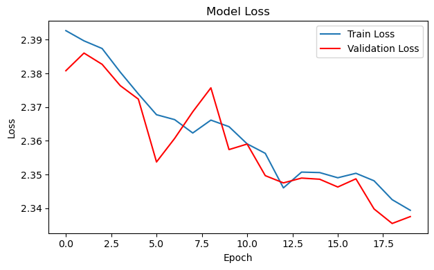

```python
# Plot training and validation loss graphs
plot_loss(history_l1_2_combined)
```

The combined L1 and L2 regularization model shows a high test loss of 2.338, which indicates that the model struggles with generalization. The test accuracy is 0.737, suggesting a moderate ability to classify correctly. While the recall is perfect at 1.000, meaning the model correctly identifies all positive cases, the precision is 0.737, which suggests a high number of false positives. The F1 score of 0.849 shows a decent balance between precision and recall but also reflects the trade-off due to the model's imbalance in performance. The validation loss graph is erratic, with significant fluctuations, but it trends downward and closely follows the training loss graph, suggesting that while the model may be learning, its performance is unstable and inconsistent across different parts of the dataset.

##### Plotting metrics graph

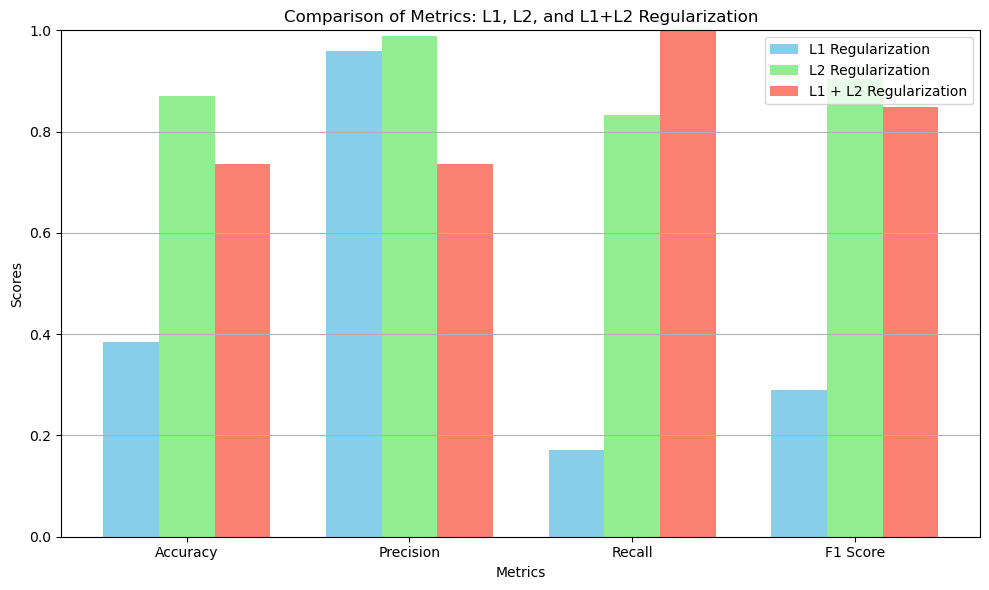

```python
# Extracting relevant Metric Scores
l1_scores = {'Accuracy': l1_metrics[1], 'Precision': l1_metrics[2], 'Recall': l1_metrics[3], 'F1 Score': l1_metrics[4]}
l2_scores = {'Accuracy': l2_metrics[1], 'Precision': l2_metrics[2], 'Recall': l2_metrics[3], 'F1 Score': l2_metrics[4]}
l1_2_scores = {'Accuracy': l1_2_combined_metrics[1], 'Precision': l1_2_combined_metrics[2], 'Recall': l1_2_combined_metrics[3], 'F1 Score': l1_2_combined_metrics[4]}

# Extract metric names and their values
metrics = list(l1_scores.keys())
l1_values = list(l1_scores.values())
l2_values = list(l2_scores.values())
l1_2_values = list(l1_2_scores.values())

# Create an index for the groups
x = np.arange(len(metrics))

# Define the width of the bars
width = 0.25

# Plotting the bar chart
plt.figure(figsize=(10, 6))
plt.bar(x - width, l1_values, width, label='L1 Regularization', color='skyblue')
plt.bar(x, l2_values, width, label='L2 Regularization', color='lightgreen')
plt.bar(x + width, l1_2_values, width, label='L1 + L2 Regularization', color='salmon')

# Adding labels and title
plt.xlabel('Metrics')
plt.ylabel('Scores')
plt.title('Comparison of Metrics: L1, L2, and L1+L2 Regularization')
plt.xticks(x, metrics)
plt.ylim(0, 1)  # Limits from 0 to 1 for better visualization of percentage-based scores
plt.legend(loc='best')

plt.grid(axis='y')
plt.tight_layout()
plt.show()
```

Based on the performance metrics from the three models, I decided to proceed with L2 regularization. The L2 model demonstrates a balanced performance with a lower test loss (0.364) and high test accuracy (0.870) compared to the L1 and combined L1/L2 models. The precision (0.988) and recall (0.833) values indicate that the L2 model effectively identifies positive cases with fewer false positives, leading to a strong F1 score (0.904). Despite some outliers in the validation loss graph, the overall trend suggests more stable learning than the L1 or combined regularization models. Given these observations, L2 regularization appears to provide the most consistent and reliable results, thus, I have chosen to continue further testing in the following sections using the L2 regularization.

### 7.2 Exploring Different Architectures

Experimenting with different model architectures allows us to identify the best configuration for the given task. This exploration can involve several adjustments such as adjusting the number of layers and neurons etc to get the best results.

To determine the optimal architecture, I will experiment with wider, deeper, and combined models. Additionally, I will explore early stopping methods to prevent overfitting and test various learning rate optimizers (SGD, RMSprop, Adam). Finally, I will evaluate the impact of different numbers of epochs on the model's performance.

#### 7.2.1 Deeper Model

The first model I will create is a deeper model, characterized by having more layers but with fewer neurons in each layer. This architecture enables the model to learn hierarchical representations, making it well-suited for data with patterns that exist across multiple levels.

```python
# Define the deeper model with more layers
deeper_model = Sequential([
        Flatten(input_shape=(64, 64, 3)),  # Flatten the input layer for fully connected layers
        Dense(256, activation='relu', kernel_regularizer=l2(0.01)),  # First hidden layer with L2 regularization
        Dropout(0.3),  # Dropout layer to prevent overfitting
        Dense(128, activation='relu', kernel_regularizer=l2(0.01)),  # Second hidden layer with L2 regularization
        Dropout(0.3),  # Dropout layer to prevent overfitting
        Dense(64, activation='relu', kernel_regularizer=l2(0.01)),  # Third hidden layer with L2 regularization
        Dropout(0.3),  # Dropout layer to prevent overfitting
        Dense(32, activation='relu', kernel_regularizer=l2(0.01)),  # Fourth hidden layer with L2 regularization
        Dropout(0.3),  # Dropout layer to prevent overfitting
        Dense(1, activation='sigmoid')  # Output layer for binary classification
    ])

# Compile the model
deeper_model.compile(optimizer=Adam(learning_rate=0.001), loss='binary_crossentropy',
                   metrics=['accuracy', Precision(name='precision'), Recall(name='recall'), F1Score(name='f1', average='micro')])
```

```python
# Train the model
history_deeper = deeper_model.fit(
    train_images,
    train_binary_labels,
    validation_data=(val_images, val_binary_labels),
    epochs=20,
    batch_size=32,
    verbose=2,
    class_weight=class_weights_dict
)
```

```
94/94 - 6s - 68ms/step - accuracy: 0.5313 - f1: 0.8486 - loss: 5.1244 - precision: 0.7508 - recall: 0.5454 - val_accuracy: 0.2620 - val_f1: 0.8492 - val_loss: 3.0007 - val_precision: 0.0000e+00 - val_recall: 0.0000e+00
94/94 - 3s - 27ms/step - accuracy: 0.5309 - f1: 0.8488 - loss: 2.4575 - precision: 0.7754 - recall: 0.5123 - val_accuracy: 0.8316 - val_f1: 0.8492 - val_loss: 2.0065 - val_precision: 0.8189 - val_recall: 0.9909
94/94 - 3s - 27ms/step - accuracy: 0.7109 - f1: 0.8488 - loss: 1.8931 - precision: 0.8614 - recall: 0.7246 - val_accuracy: 0.5909 - val_f1: 0.8492 - val_loss: 1.9493 - val_precision: 0.9843 - val_recall: 0.4529
94/94 - 3s - 27ms/step - accuracy: 0.7384 - f1: 0.8488 - loss: 1.6550 - precision: 0.8774 - recall: 0.7500 - val_accuracy: 0.9158 - val_f1: 0.8492 - val_loss: 1.6134 - val_precision: 0.9223 - val_recall: 0.9674
94/94 - 3s - 27ms/step - accuracy: 0.7755 - f1: 0.8488 - loss: 1.4789 - precision: 0.8648 - recall: 0.8244 - val_accuracy: 0.8957 - val_f1: 0.8492 - val_loss: 1.1933 - val_precision: 0.8810 - val_recall: 0.9928
94/94 - 3s - 27ms/step - accuracy: 0.8116 - f1: 0.8488 - loss: 1.2833 - precision: 0.8678 - recall: 0.8784 - val_accuracy: 0.8810 - val_f1: 0.8492 - val_loss: 1.1406 - val_precision: 0.9793 - val_recall: 0.8569
94/94 - 3s - 27ms/step - accuracy: 0.8310 - f1: 0.8488 - loss: 1.1285 - precision: 0.8724 - recall: 0.9029 - val_accuracy: 0.9305 - val_f1: 0.8492 - val_loss: 0.8501 - val_precision: 0.9545 - val_recall: 0.9511
94/94 - 3s - 27ms/step - accuracy: 0.8177 - f1: 0.8488 - loss: 1.0349 - precision: 0.8793 - recall: 0.8725 - val_accuracy: 0.7874 - val_f1: 0.8492 - val_loss: 0.9928 - val_precision: 0.9852 - val_recall: 0.7228
94/94 - 3s - 27ms/step - accuracy: 0.8294 - f1: 0.8488 - loss: 0.9706 - precision: 0.8718 - recall: 0.9011 - val_accuracy: 0.8957 - val_f1: 0.8492 - val_loss: 0.8391 - val_precision: 0.8774 - val_recall: 0.9982
94/94 - 3s - 27ms/step - accuracy: 0.8324 - f1: 0.8488 - loss: 0.8949 - precision: 0.8662 - recall: 0.9138 - val_accuracy: 0.6711 - val_f1: 0.8492 - val_loss: 1.1009 - val_precision: 0.9935 - val_recall: 0.5580
94/94 - 3s - 28ms/step - accuracy: 0.8197 - f1: 0.8488 - loss: 0.8289 - precision: 0.8722 - recall: 0.8852 - val_accuracy: 0.9425 - val_f1: 0.8492 - val_loss: 0.6799 - val_precision: 0.9426 - val_recall: 0.9819
94/94 - 3s - 27ms/step - accuracy: 0.8394 - f1: 0.8488 - loss: 0.7686 - precision: 0.8761 - recall: 0.9111 - val_accuracy: 0.8703 - val_f1: 0.8492 - val_loss: 0.6753 - val_precision: 0.8516 - val_recall: 0.9982
94/94 - 3s - 27ms/step - accuracy: 0.8321 - f1: 0.8488 - loss: 0.7823 - precision: 0.8643 - recall: 0.9161 - val_accuracy: 0.8209 - val_f1: 0.8492 - val_loss: 0.7715 - val_precision: 0.9860 - val_recall: 0.7681
94/94 - 3s - 27ms/step - accuracy: 0.8575 - f1: 0.8488 - loss: 0.6974 - precision: 0.8819 - recall: 0.9315 - val_accuracy: 0.8850 - val_f1: 0.8492 - val_loss: 0.6539 - val_precision: 0.9834 - val_recall: 0.8587
94/94 - 3s - 27ms/step - accuracy: 0.8585 - f1: 0.8488 - loss: 0.6535 - precision: 0.8827 - recall: 0.9319 - val_accuracy: 0.9452 - val_f1: 0.8492 - val_loss: 0.5020 - val_precision: 0.9522 - val_recall: 0.9746
94/94 - 3s - 27ms/step - accuracy: 0.8575 - f1: 0.8488 - loss: 0.6224 - precision: 0.8848 - recall: 0.9274 - val_accuracy: 0.9051 - val_f1: 0.8492 - val_loss: 0.5041 - val_precision: 0.9670 - val_recall: 0.9022
94/94 - 3s - 27ms/step - accuracy: 0.8488 - f1: 0.8488 - loss: 0.6192 - precision: 0.8763 - recall: 0.9256 - val_accuracy: 0.9439 - val_f1: 0.8492 - val_loss: 0.5080 - val_precision: 0.9427 - val_recall: 0.9837
94/94 - 3s - 28ms/step - accuracy: 0.8494 - f1: 0.8488 - loss: 0.6075 - precision: 0.8751 - recall: 0.9283 - val_accuracy: 0.8690 - val_f1: 0.8492 - val_loss: 0.5472 - val_precision: 0.8503 - val_recall: 0.9982
94/94 - 3s - 27ms/step - accuracy: 0.8508 - f1: 0.8488 - loss: 0.5995 - precision: 0.8681 - recall: 0.9406 - val_accuracy: 0.9051 - val_f1: 0.8492 - val_loss: 0.4894 - val_precision: 0.9762 - val_recall: 0.8931
94/94 - 3s - 27ms/step - accuracy: 0.8414 - f1: 0.8488 - loss: 0.5930 - precision: 0.8719 - recall: 0.9201 - val_accuracy: 0.9064 - val_f1: 0.8492 - val_loss: 0.4907 - val_precision: 0.9820 - val_recall: 0.8895
```

```python
# Evaluate the model on the test set
deeper_metrics = deeper_model.evaluate(test_images, test_binary_labels, verbose=0)
print(f"Test Loss: {deeper_metrics[0]:.3f}")
print(f"Test Accuracy: {deeper_metrics[1]:.3f}")
print(f"Test Precision: {deeper_metrics[2]:.3f}")
print(f"Test Recall: {deeper_metrics[3]:.3f}")
print(f"Test F1 Score: {deeper_metrics[4]:.3f}")
```

```
Test Loss: 0.487
Test Accuracy: 0.902
Test Precision: 0.981
Test Recall: 0.884
Test F1 Score: 0.930
```

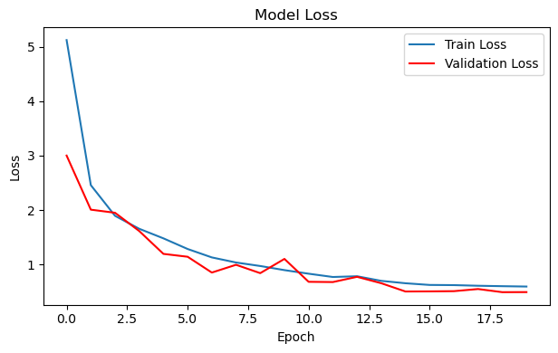

```python
# Plot training and validation loss graphs
plot_loss(history_deeper)
```

The deeper model demonstrates solid performance across all metrics, with a test accuracy of 90.2%, a high precision of 98.1%, and a recall of 88.4%, leading to an F1 score of 93.0%. The loss graph shows a steady decline, staying below the training loss curve with minimal fluctuations, indicating that the model is learning effectively without significant overfitting. Only one or two outliers are present, suggesting that this architecture is well-suited for capturing the underlying patterns in the data while maintaining good generalization.

#### 7.2.2 Wider Model

A wider model involves increasing the number of neurons in each layer while reducing the total number of layers. This approach is effective when the input data is complex, but the task does not necessitate learning multiple levels of abstraction. By having more neurons in each layer, the model can capture complex details and patterns within the data. This is good for problems where the relationships between features are dense and require a broader capacity for learning in each layer.

```python
# Define the wider model with more neurons
wider_model = Sequential([
        Flatten(input_shape=(64, 64, 3)),  # Flatten the input layer for fully connected layers
        Dense(512, activation='relu', kernel_regularizer=l2(0.01)),  # First hidden layer with L2 regularization
        Dropout(0.3),  # Dropout layer to prevent overfitting
        Dense(256, activation='relu', kernel_regularizer=l2(0.01)),  # Second hidden layer with L2 regularization
        Dropout(0.3),  # Dropout layer to prevent overfitting
        Dense(1, activation='sigmoid')  # Output layer for binary classification
    ])

# Compile the model
wider_model.compile(optimizer=Adam(learning_rate=0.001), loss='binary_crossentropy',
                   metrics=['accuracy', Precision(name='precision'), Recall(name='recall'), F1Score(name='f1', average='micro')])
```

```python
# Train the model
history_wider = wider_model.fit(
    train_images,
    train_binary_labels,
    validation_data=(val_images, val_binary_labels),
    epochs=20,
    batch_size=32,
    verbose=2,
    class_weight=class_weights_dict
)
```

```
94/94 - 7s - 80ms/step - accuracy: 0.6638 - f1: 0.8468 - loss: 6.3444 - precision: 0.8512 - recall: 0.6593 - val_accuracy: 0.8984 - val_f1: 0.8492 - val_loss: 2.4826 - val_precision: 0.9132 - val_recall: 0.9529
94/94 - 5s - 51ms/step - accuracy: 0.7999 - f1: 0.8488 - loss: 2.0212 - precision: 0.9143 - recall: 0.8040 - val_accuracy: 0.9131 - val_f1: 0.8492 - val_loss: 1.4929 - val_precision: 0.9603 - val_recall: 0.9203
94/94 - 5s - 52ms/step - accuracy: 0.8267 - f1: 0.8488 - loss: 1.4212 - precision: 0.9319 - recall: 0.8253 - val_accuracy: 0.9171 - val_f1: 0.8492 - val_loss: 1.0639 - val_precision: 0.9605 - val_recall: 0.9257
94/94 - 5s - 51ms/step - accuracy: 0.8220 - f1: 0.8488 - loss: 1.1972 - precision: 0.9327 - recall: 0.8176 - val_accuracy: 0.9265 - val_f1: 0.8492 - val_loss: 0.9213 - val_precision: 0.9576 - val_recall: 0.9420
94/94 - 5s - 51ms/step - accuracy: 0.8438 - f1: 0.8488 - loss: 1.0208 - precision: 0.9447 - recall: 0.8371 - val_accuracy: 0.9385 - val_f1: 0.8492 - val_loss: 0.8066 - val_precision: 0.9454 - val_recall: 0.9728
94/94 - 5s - 51ms/step - accuracy: 0.8300 - f1: 0.8488 - loss: 0.9569 - precision: 0.9279 - recall: 0.8344 - val_accuracy: 0.8944 - val_f1: 0.8492 - val_loss: 0.7731 - val_precision: 0.9759 - val_recall: 0.8786
94/94 - 5s - 51ms/step - accuracy: 0.8173 - f1: 0.8488 - loss: 0.8866 - precision: 0.9282 - recall: 0.8153 - val_accuracy: 0.9318 - val_f1: 0.8492 - val_loss: 0.6809 - val_precision: 0.9514 - val_recall: 0.9565
94/94 - 5s - 51ms/step - accuracy: 0.8344 - f1: 0.8488 - loss: 0.7823 - precision: 0.9292 - recall: 0.8394 - val_accuracy: 0.9251 - val_f1: 0.8492 - val_loss: 0.6329 - val_precision: 0.9697 - val_recall: 0.9275
94/94 - 5s - 52ms/step - accuracy: 0.7762 - f1: 0.8488 - loss: 0.7891 - precision: 0.9146 - recall: 0.7681 - val_accuracy: 0.9211 - val_f1: 0.8492 - val_loss: 0.6362 - val_precision: 0.9573 - val_recall: 0.9348
94/94 - 5s - 51ms/step - accuracy: 0.8157 - f1: 0.8488 - loss: 0.7074 - precision: 0.9185 - recall: 0.8230 - val_accuracy: 0.9051 - val_f1: 0.8492 - val_loss: 0.5245 - val_precision: 0.9706 - val_recall: 0.8986
94/94 - 5s - 52ms/step - accuracy: 0.7882 - f1: 0.8488 - loss: 0.7022 - precision: 0.8953 - recall: 0.8072 - val_accuracy: 0.9291 - val_f1: 0.8492 - val_loss: 0.6138 - val_precision: 0.9179 - val_recall: 0.9928
94/94 - 5s - 53ms/step - accuracy: 0.7738 - f1: 0.8488 - loss: 0.7295 - precision: 0.8987 - recall: 0.7813 - val_accuracy: 0.9305 - val_f1: 0.8492 - val_loss: 0.5951 - val_precision: 0.9647 - val_recall: 0.9402
94/94 - 5s - 52ms/step - accuracy: 0.7932 - f1: 0.8488 - loss: 0.6524 - precision: 0.9113 - recall: 0.7972 - val_accuracy: 0.8890 - val_f1: 0.8492 - val_loss: 0.4836 - val_precision: 0.9796 - val_recall: 0.8678
94/94 - 5s - 50ms/step - accuracy: 0.7742 - f1: 0.8488 - loss: 0.6426 - precision: 0.8875 - recall: 0.7945 - val_accuracy: 0.8342 - val_f1: 0.8492 - val_loss: 0.5799 - val_precision: 0.9864 - val_recall: 0.7862
94/94 - 5s - 51ms/step - accuracy: 0.8106 - f1: 0.8488 - loss: 0.5673 - precision: 0.8949 - recall: 0.8421 - val_accuracy: 0.8275 - val_f1: 0.8492 - val_loss: 0.4821 - val_precision: 0.8106 - val_recall: 1.0000
94/94 - 5s - 51ms/step - accuracy: 0.7862 - f1: 0.8488 - loss: 0.5825 - precision: 0.8907 - recall: 0.8094 - val_accuracy: 0.9372 - val_f1: 0.8492 - val_loss: 0.3381 - val_precision: 0.9599 - val_recall: 0.9547
94/94 - 5s - 51ms/step - accuracy: 0.8076 - f1: 0.8488 - loss: 0.5273 - precision: 0.8983 - recall: 0.8335 - val_accuracy: 0.8971 - val_f1: 0.8492 - val_loss: 0.3978 - val_precision: 0.9817 - val_recall: 0.8768
94/94 - 5s - 51ms/step - accuracy: 0.8207 - f1: 0.8488 - loss: 0.5084 - precision: 0.8901 - recall: 0.8634 - val_accuracy: 0.8944 - val_f1: 0.8492 - val_loss: 0.4202 - val_precision: 0.8760 - val_recall: 0.9982
94/94 - 5s - 51ms/step - accuracy: 0.7538 - f1: 0.8488 - loss: 0.5223 - precision: 0.8993 - recall: 0.7500 - val_accuracy: 0.9118 - val_f1: 0.8492 - val_loss: 0.3196 - val_precision: 0.9691 - val_recall: 0.9094
94/94 - 5s - 53ms/step - accuracy: 0.7407 - f1: 0.8488 - loss: 0.4891 - precision: 0.9333 - recall: 0.6983 - val_accuracy: 0.8596 - val_f1: 0.8492 - val_loss: 0.4322 - val_precision: 0.9869 - val_recall: 0.8207
```

```python
# Evaluate the model on the test set
wider_metrics = wider_model.evaluate(test_images, test_binary_labels, verbose=0)
print(f"Test Loss: {wider_metrics[0]:.3f}")
print(f"Test Accuracy: {wider_metrics[1]:.3f}")
print(f"Test Precision: {wider_metrics[2]:.3f}")
print(f"Test Recall: {wider_metrics[3]:.3f}")
print(f"Test F1 Score: {wider_metrics[4]:.3f}")
```

```
Test Loss: 0.449
Test Accuracy: 0.851
Test Precision: 0.991
Test Recall: 0.806
Test F1 Score: 0.889
```

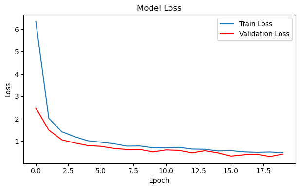

```python
# Plot training and validation loss graphs
plot_loss(history_wider)
```

The wider model shows a test loss of 0.449 and a test accuracy of 0.851. The precision is high at 0.991, indicating that the model is very good at correctly identifying positive cases. However, the recall is 0.806, suggesting that it misses some positive cases. The F1 Score is 0.889, balancing both precision and recall, but it is lower than the deeper model.  
The loss graph shows a steady decline, remaining below the training loss, indicating stable generalization. However, compared to the deeper model, it may lack the depth needed to capture more complex patterns in the data.

#### 7.2.3 Combined Deeper and Wider Model

This model merges deep and wide architectures to utilize their strengths. The deeper branch consists of layers with fewer neurons (128, 64, 32) and dropout for capturing hierarchical patterns. The wider branch features layers with more neurons (512, 256) and dropout to learn complex representations. By concatenating both branches, the model combines the deep hierarchical features with the broad, complex representations. After merging, additional layers (128, 64 neurons) and dropout regularization are applied to further enhance learning and prevent overfitting. The final output layer uses a sigmoid activation function for binary classification.

```python
# Define the input layer
input_layer = Input(shape=(64, 64, 3))

# Flatten the input
flattened_input = Flatten()(input_layer)

# Define the deeper model branch
x_deep = Dense(128, activation='relu', kernel_regularizer=l2(0.01))(flattened_input)
x_deep = Dropout(0.3)(x_deep)
x_deep = Dense(64, activation='relu', kernel_regularizer=l2(0.01))(x_deep)
x_deep = Dropout(0.3)(x_deep)
x_deep = Dense(32, activation='relu', kernel_regularizer=l2(0.01))(x_deep)
x_deep = Dropout(0.3)(x_deep)

# Define the wider model branch
x_wide = Dense(512, activation='relu', kernel_regularizer=l2(0.01))(flattened_input)
x_wide = Dropout(0.3)(x_wide)
x_wide = Dense(256, activation='relu', kernel_regularizer=l2(0.01))(x_wide)
x_wide = Dropout(0.3)(x_wide)

# Concatenate the deeper and wider branches
merged_deep_wide = concatenate([x_deep, x_wide])

# Additional layers after concatenation
combined_output = Dense(128, activation='relu', kernel_regularizer=l2(0.01))(merged_deep_wide)
combined_output = Dropout(0.3)(combined_output)
combined_output = Dense(64, activation='relu', kernel_regularizer=l2(0.01))(combined_output)
combined_output = Dropout(0.3)(combined_output)

# Final output layer for binary classification
final_output = Dense(1, activation='sigmoid')(combined_output)

# Create the combined deep and wide model
combined_deep_wide_model = Model(inputs=input_layer, outputs=final_output)

# Compile the model
combined_deep_wide_model.compile(optimizer=Adam(learning_rate=0.001), loss='binary_crossentropy',
                   metrics=['accuracy', Precision(name='precision'), Recall(name='recall'), F1Score(name='f1', average='micro')])

# Print the model summary
combined_deep_wide_model.summary()
```

```
Model: "functional_20"
```

```
┏━━━━━━━━━━━━━━━━━━━━━┳━━━━━━━━━━━━━━━━━━━┳━━━━━━━━━━━━┳━━━━━━━━━━━━━━━━━━━┓
┃ Layer (type)        ┃ Output Shape      ┃    Param # ┃ Connected to      ┃
┡━━━━━━━━━━━━━━━━━━━━━╇━━━━━━━━━━━━━━━━━━━╇━━━━━━━━━━━━╇━━━━━━━━━━━━━━━━━━━┩
│ input_layer_19      │ (None, 64, 64, 3) │          0 │ -                 │
│ (InputLayer)        │                   │            │                   │
├─────────────────────┼───────────────────┼────────────┼───────────────────┤
│ flatten_19          │ (None, 12288)     │          0 │ input_layer_19[0… │
│ (Flatten)           │                   │            │                   │
├─────────────────────┼───────────────────┼────────────┼───────────────────┤
│ dense_66 (Dense)    │ (None, 128)       │  1,572,992 │ flatten_19[0][0]  │
├─────────────────────┼───────────────────┼────────────┼───────────────────┤
│ dropout_28          │ (None, 128)       │          0 │ dense_66[0][0]    │
│ (Dropout)           │                   │            │                   │
├─────────────────────┼───────────────────┼────────────┼───────────────────┤
│ dense_67 (Dense)    │ (None, 64)        │      8,256 │ dropout_28[0][0]  │
├─────────────────────┼───────────────────┼────────────┼───────────────────┤
│ dense_69 (Dense)    │ (None, 512)       │  6,291,968 │ flatten_19[0][0]  │
├─────────────────────┼───────────────────┼────────────┼───────────────────┤
│ dropout_29          │ (None, 64)        │          0 │ dense_67[0][0]    │
│ (Dropout)           │                   │            │                   │
├─────────────────────┼───────────────────┼────────────┼───────────────────┤
│ dropout_31          │ (None, 512)       │          0 │ dense_69[0][0]    │
│ (Dropout)           │                   │            │                   │
├─────────────────────┼───────────────────┼────────────┼───────────────────┤
│ dense_68 (Dense)    │ (None, 32)        │      2,080 │ dropout_29[0][0]  │
├─────────────────────┼───────────────────┼────────────┼───────────────────┤
│ dense_70 (Dense)    │ (None, 256)       │    131,328 │ dropout_31[0][0]  │
├─────────────────────┼───────────────────┼────────────┼───────────────────┤
│ dropout_30          │ (None, 32)        │          0 │ dense_68[0][0]    │
│ (Dropout)           │                   │            │                   │
├─────────────────────┼───────────────────┼────────────┼───────────────────┤
│ dropout_32          │ (None, 256)       │          0 │ dense_70[0][0]    │
│ (Dropout)           │                   │            │                   │
├─────────────────────┼───────────────────┼────────────┼───────────────────┤
│ concatenate_1       │ (None, 288)       │          0 │ dropout_30[0][0], │
│ (Concatenate)       │                   │            │ dropout_32[0][0]  │
├─────────────────────┼───────────────────┼────────────┼───────────────────┤
│ dense_71 (Dense)    │ (None, 128)       │     36,992 │ concatenate_1[0]… │
├─────────────────────┼───────────────────┼────────────┼───────────────────┤
│ dropout_33          │ (None, 128)       │          0 │ dense_71[0][0]    │
│ (Dropout)           │                   │            │                   │
├─────────────────────┼───────────────────┼────────────┼───────────────────┤
│ dense_72 (Dense)    │ (None, 64)        │      8,256 │ dropout_33[0][0]  │
├─────────────────────┼───────────────────┼────────────┼───────────────────┤
│ dropout_34          │ (None, 64)        │          0 │ dense_72[0][0]    │
│ (Dropout)           │                   │            │                   │
├─────────────────────┼───────────────────┼────────────┼───────────────────┤
│ dense_73 (Dense)    │ (None, 1)         │         65 │ dropout_34[0][0]  │
└─────────────────────┴───────────────────┴────────────┴───────────────────┘
```

```
 Total params: 8,051,937 (30.72 MB)
```

```
 Trainable params: 8,051,937 (30.72 MB)
```

```
 Non-trainable params: 0 (0.00 B)
```

```python
# Train the model
history_combined_deep_wide = combined_deep_wide_model.fit(
    train_images,
    train_binary_labels,
    validation_data=(val_images, val_binary_labels),
    epochs=20,
    batch_size=32,
    verbose=2,
    class_weight=class_weights_dict
)
```

```
94/94 - 11s - 121ms/step - accuracy: 0.5085 - f1: 0.8486 - loss: 9.6993 - precision: 0.7351 - recall: 0.5213 - val_accuracy: 0.8730 - val_f1: 0.8492 - val_loss: 5.0082 - val_precision: 0.9208 - val_recall: 0.9058
94/94 - 7s - 70ms/step - accuracy: 0.5437 - f1: 0.8488 - loss: 4.2166 - precision: 0.7752 - recall: 0.5368 - val_accuracy: 0.8610 - val_f1: 0.8492 - val_loss: 3.5167 - val_precision: 0.8489 - val_recall: 0.9873
94/94 - 6s - 64ms/step - accuracy: 0.6631 - f1: 0.8488 - loss: 3.2905 - precision: 0.8577 - recall: 0.6511 - val_accuracy: 0.8543 - val_f1: 0.8492 - val_loss: 2.8344 - val_precision: 0.9644 - val_recall: 0.8333
94/94 - 6s - 65ms/step - accuracy: 0.7387 - f1: 0.8488 - loss: 2.7661 - precision: 0.8865 - recall: 0.7405 - val_accuracy: 0.6885 - val_f1: 0.8492 - val_loss: 2.6903 - val_precision: 0.9878 - val_recall: 0.5851
94/94 - 6s - 65ms/step - accuracy: 0.7795 - f1: 0.8488 - loss: 2.3637 - precision: 0.9055 - recall: 0.7827 - val_accuracy: 0.8102 - val_f1: 0.8492 - val_loss: 2.1319 - val_precision: 0.9881 - val_recall: 0.7518
94/94 - 6s - 66ms/step - accuracy: 0.8110 - f1: 0.8488 - loss: 1.9729 - precision: 0.9124 - recall: 0.8226 - val_accuracy: 0.7874 - val_f1: 0.8492 - val_loss: 1.8464 - val_precision: 0.9852 - val_recall: 0.7228
94/94 - 6s - 67ms/step - accuracy: 0.8177 - f1: 0.8488 - loss: 1.7035 - precision: 0.9226 - recall: 0.8217 - val_accuracy: 0.8596 - val_f1: 0.8492 - val_loss: 1.5421 - val_precision: 0.9848 - val_recall: 0.8225
94/94 - 6s - 65ms/step - accuracy: 0.8227 - f1: 0.8488 - loss: 1.4800 - precision: 0.9266 - recall: 0.8249 - val_accuracy: 0.8917 - val_f1: 0.8492 - val_loss: 1.3511 - val_precision: 0.9758 - val_recall: 0.8750
94/94 - 6s - 68ms/step - accuracy: 0.8535 - f1: 0.8488 - loss: 1.2616 - precision: 0.9363 - recall: 0.8598 - val_accuracy: 0.9078 - val_f1: 0.8492 - val_loss: 1.0384 - val_precision: 0.9671 - val_recall: 0.9058
94/94 - 6s - 68ms/step - accuracy: 0.8334 - f1: 0.8488 - loss: 1.1641 - precision: 0.9219 - recall: 0.8457 - val_accuracy: 0.8463 - val_f1: 0.8492 - val_loss: 1.0715 - val_precision: 0.9823 - val_recall: 0.8062
94/94 - 6s - 67ms/step - accuracy: 0.8468 - f1: 0.8488 - loss: 1.0113 - precision: 0.9339 - recall: 0.8525 - val_accuracy: 0.9037 - val_f1: 0.8492 - val_loss: 0.8468 - val_precision: 0.9743 - val_recall: 0.8931
94/94 - 6s - 65ms/step - accuracy: 0.8568 - f1: 0.8488 - loss: 0.9206 - precision: 0.9374 - recall: 0.8634 - val_accuracy: 0.7527 - val_f1: 0.8492 - val_loss: 1.0831 - val_precision: 0.9893 - val_recall: 0.6721
94/94 - 6s - 68ms/step - accuracy: 0.8257 - f1: 0.8488 - loss: 0.9141 - precision: 0.9071 - recall: 0.8507 - val_accuracy: 0.8676 - val_f1: 0.8492 - val_loss: 0.8285 - val_precision: 0.8490 - val_recall: 0.9982
94/94 - 6s - 69ms/step - accuracy: 0.7835 - f1: 0.8488 - loss: 0.9350 - precision: 0.8748 - recall: 0.8244 - val_accuracy: 0.9372 - val_f1: 0.8492 - val_loss: 0.7361 - val_precision: 0.9438 - val_recall: 0.9728
94/94 - 6s - 66ms/step - accuracy: 0.8300 - f1: 0.8488 - loss: 0.7521 - precision: 0.9113 - recall: 0.8525 - val_accuracy: 0.8650 - val_f1: 0.8492 - val_loss: 0.6347 - val_precision: 0.8464 - val_recall: 0.9982
94/94 - 6s - 66ms/step - accuracy: 0.8354 - f1: 0.8488 - loss: 0.7157 - precision: 0.9192 - recall: 0.8516 - val_accuracy: 0.9118 - val_f1: 0.8492 - val_loss: 0.5039 - val_precision: 0.9728 - val_recall: 0.9058
94/94 - 6s - 66ms/step - accuracy: 0.8478 - f1: 0.8488 - loss: 0.6717 - precision: 0.9239 - recall: 0.8648 - val_accuracy: 0.8543 - val_f1: 0.8492 - val_loss: 0.6863 - val_precision: 0.9847 - val_recall: 0.8152
94/94 - 6s - 66ms/step - accuracy: 0.8581 - f1: 0.8488 - loss: 0.6670 - precision: 0.9262 - recall: 0.8775 - val_accuracy: 0.2687 - val_f1: 0.8492 - val_loss: 1.3540 - val_precision: 1.0000 - val_recall: 0.0091
94/94 - 6s - 65ms/step - accuracy: 0.8428 - f1: 0.8488 - loss: 0.6839 - precision: 0.9093 - recall: 0.8739 - val_accuracy: 0.9358 - val_f1: 0.8492 - val_loss: 0.5681 - val_precision: 0.9437 - val_recall: 0.9710
94/94 - 6s - 65ms/step - accuracy: 0.8341 - f1: 0.8488 - loss: 0.6918 - precision: 0.8697 - recall: 0.9115 - val_accuracy: 0.6912 - val_f1: 0.8492 - val_loss: 0.8127 - val_precision: 0.9878 - val_recall: 0.5888
```

```python
# Evaluate the model on the test set
combined_deep_wide_metrics = combined_deep_wide_model.evaluate(test_images, test_binary_labels, verbose=0)
print(f"Test Loss: {combined_deep_wide_metrics[0]:.3f}")
print(f"Test Accuracy: {combined_deep_wide_metrics[1]:.3f}")
print(f"Test Precision: {combined_deep_wide_metrics[2]:.3f}")
print(f"Test Recall: {combined_deep_wide_metrics[3]:.3f}")
print(f"Test F1 Score: {combined_deep_wide_metrics[4]:.3f}")
```

```
Test Loss: 0.824
Test Accuracy: 0.659
Test Precision: 1.000
Test Recall: 0.537
Test F1 Score: 0.699
```

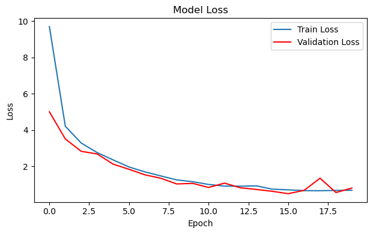

```python
# Plot training and validation loss graphs
plot_loss(history_combined_deep_wide)
```

#### 7.2.4 Plotting the metrics graph

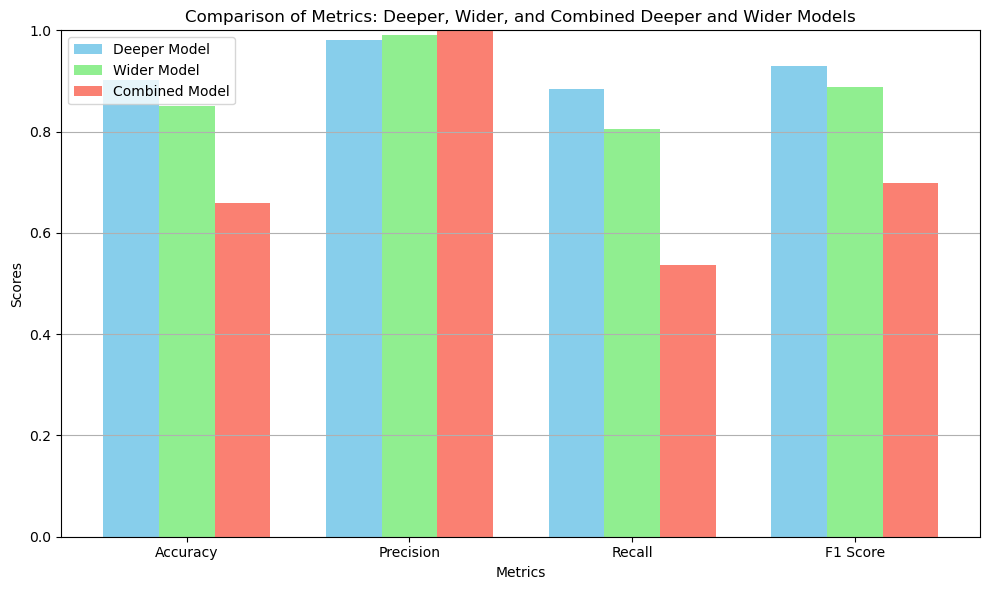

```python
# Extracting relevant Metric Scores
deeper_scores = {'Accuracy': deeper_metrics[1], 'Precision': deeper_metrics[2], 'Recall': deeper_metrics[3], 'F1 Score': deeper_metrics[4]}
wider_scores = {'Accuracy': wider_metrics[1], 'Precision': wider_metrics[2], 'Recall': wider_metrics[3], 'F1 Score': wider_metrics[4]}
combined_scores = {'Accuracy': combined_deep_wide_metrics[1], 'Precision': combined_deep_wide_metrics[2], 'Recall': combined_deep_wide_metrics[3],
                   'F1 Score': combined_deep_wide_metrics[4]}

# Extract metric names and their values
metrics = list(deeper_scores.keys())
deeper_values = list(deeper_scores.values())
wider_values = list(wider_scores.values())
combined_values = list(combined_scores.values())

# Create an index for the groups
x = np.arange(len(metrics))

# Define the width of the bars
width = 0.25

# Plotting the bar chart
plt.figure(figsize=(10, 6))
plt.bar(x - width, deeper_values, width, label='Deeper Model', color='skyblue')
plt.bar(x, wider_values, width, label='Wider Model', color='lightgreen')
plt.bar(x + width, combined_values, width, label='Combined Model', color='salmon')

# Adding labels and title
plt.xlabel('Metrics')
plt.ylabel('Scores')
plt.title('Comparison of Metrics: Deeper, Wider, and Combined Deeper and Wider Models')
plt.xticks(x, metrics)
plt.ylim(0, 1)  # Limits from 0 to 1 for better visualization of percentage-based scores
plt.legend(loc='best')

plt.grid(axis='y')
plt.tight_layout()
plt.show()
```

#### 7.2.5 Early stopping

Early stopping is a technique used to prevent overfitting by terminating training when the validation performance no longer improves. This method helps to avoid overfitting, reduces training time, and ensures optimal model performance by stopping training at the most effective point before overfitting starts. Below I will apply early stopping to the previously chosen deeper model to evaluate if it enhances performance.

```python
# Define the model
es_model = Sequential([
        Flatten(input_shape=(64, 64, 3)),  # Flatten the input layer for fully connected layers
        Dense(256, activation='relu', kernel_regularizer=l2(0.01)),  # First hidden layer with L2 regularization
        Dropout(0.3),  # Dropout layer to prevent overfitting
        Dense(128, activation='relu', kernel_regularizer=l2(0.01)),  # Second hidden layer with L2 regularization
        Dropout(0.3),  # Dropout layer to prevent overfitting
        Dense(64, activation='relu', kernel_regularizer=l2(0.01)),  # Third hidden layer with L2 regularization
        Dropout(0.3),  # Dropout layer to prevent overfitting
        Dense(32, activation='relu', kernel_regularizer=l2(0.01)),  # Fourth hidden layer with L2 regularization
        Dropout(0.3),  # Dropout layer to prevent overfitting
        Dense(1, activation='sigmoid')  # Output layer for binary classification
    ])

# Define early stopping callback
early_stopping = EarlyStopping(monitor='val_loss', patience=5, restore_best_weights=True)
# Compile the model
es_model.compile(optimizer=Adam(learning_rate=0.001), loss='binary_crossentropy',
                   metrics=['accuracy', Precision(name='precision'), Recall(name='recall'), F1Score(name='f1', average='micro')])
```

```python
# Train the model
history_es = es_model.fit(
    train_images,
    train_binary_labels,
    validation_data=(val_images, val_binary_labels),
    callbacks=[early_stopping],  # Include early stopping
    epochs=20,
    batch_size=32,
    verbose=2,
    class_weight=class_weights_dict
)
```

```
94/94 - 3s - 27ms/step - accuracy: 0.4038 - f1: 0.8488 - loss: 0.7186 - precision: 0.7235 - recall: 0.3099 - val_accuracy: 0.2620 - val_f1: 0.8492 - val_loss: 0.7164 - val_precision: 0.0000e+00 - val_recall: 0.0000e+00
94/94 - 3s - 27ms/step - accuracy: 0.5477 - f1: 0.8488 - loss: 0.7135 - precision: 0.7380 - recall: 0.5994 - val_accuracy: 0.2620 - val_f1: 0.8492 - val_loss: 0.7116 - val_precision: 0.0000e+00 - val_recall: 0.0000e+00
94/94 - 3s - 27ms/step - accuracy: 0.3332 - f1: 0.8488 - loss: 0.7094 - precision: 0.7425 - recall: 0.1466 - val_accuracy: 0.2620 - val_f1: 0.8492 - val_loss: 0.7078 - val_precision: 0.0000e+00 - val_recall: 0.0000e+00
94/94 - 3s - 27ms/step - accuracy: 0.4590 - f1: 0.8488 - loss: 0.7060 - precision: 0.7412 - recall: 0.4093 - val_accuracy: 0.7380 - val_f1: 0.8492 - val_loss: 0.7042 - val_precision: 0.7380 - val_recall: 1.0000
94/94 - 2s - 26ms/step - accuracy: 0.4041 - f1: 0.8488 - loss: 0.7034 - precision: 0.7390 - recall: 0.2967 - val_accuracy: 0.2620 - val_f1: 0.8492 - val_loss: 0.7030 - val_precision: 0.0000e+00 - val_recall: 0.0000e+00
94/94 - 3s - 27ms/step - accuracy: 0.4346 - f1: 0.8488 - loss: 0.7013 - precision: 0.7307 - recall: 0.3693 - val_accuracy: 0.7380 - val_f1: 0.8492 - val_loss: 0.6998 - val_precision: 0.7380 - val_recall: 1.0000
94/94 - 3s - 27ms/step - accuracy: 0.6082 - f1: 0.8488 - loss: 0.6995 - precision: 0.7370 - recall: 0.7287 - val_accuracy: 0.7380 - val_f1: 0.8492 - val_loss: 0.6983 - val_precision: 0.7380 - val_recall: 1.0000
94/94 - 3s - 27ms/step - accuracy: 0.5356 - f1: 0.8488 - loss: 0.6983 - precision: 0.7279 - recall: 0.5912 - val_accuracy: 0.7380 - val_f1: 0.8492 - val_loss: 0.6975 - val_precision: 0.7380 - val_recall: 1.0000
94/94 - 3s - 27ms/step - accuracy: 0.5406 - f1: 0.8488 - loss: 0.6971 - precision: 0.7325 - recall: 0.5939 - val_accuracy: 0.7380 - val_f1: 0.8492 - val_loss: 0.6966 - val_precision: 0.7380 - val_recall: 1.0000
94/94 - 3s - 27ms/step - accuracy: 0.5289 - f1: 0.8488 - loss: 0.6962 - precision: 0.7352 - recall: 0.5644 - val_accuracy: 0.7380 - val_f1: 0.8492 - val_loss: 0.6946 - val_precision: 0.7380 - val_recall: 1.0000
94/94 - 3s - 27ms/step - accuracy: 0.6480 - f1: 0.8488 - loss: 0.6956 - precision: 0.7324 - recall: 0.8235 - val_accuracy: 0.7380 - val_f1: 0.8492 - val_loss: 0.6945 - val_precision: 0.7380 - val_recall: 1.0000
94/94 - 3s - 27ms/step - accuracy: 0.5206 - f1: 0.8488 - loss: 0.6951 - precision: 0.7310 - recall: 0.5535 - val_accuracy: 0.7380 - val_f1: 0.8492 - val_loss: 0.6940 - val_precision: 0.7380 - val_recall: 1.0000
94/94 - 3s - 28ms/step - accuracy: 0.6986 - f1: 0.8488 - loss: 0.6946 - precision: 0.7348 - recall: 0.9251 - val_accuracy: 0.7380 - val_f1: 0.8492 - val_loss: 0.6940 - val_precision: 0.7380 - val_recall: 1.0000
94/94 - 3s - 28ms/step - accuracy: 0.4801 - f1: 0.8488 - loss: 0.6943 - precision: 0.7248 - recall: 0.4755 - val_accuracy: 0.2620 - val_f1: 0.8492 - val_loss: 0.6947 - val_precision: 0.0000e+00 - val_recall: 0.0000e+00
94/94 - 3s - 31ms/step - accuracy: 0.3714 - f1: 0.8488 - loss: 0.6941 - precision: 0.7458 - recall: 0.2237 - val_accuracy: 0.2620 - val_f1: 0.8492 - val_loss: 0.6950 - val_precision: 0.0000e+00 - val_recall: 0.0000e+00
94/94 - 3s - 27ms/step - accuracy: 0.3837 - f1: 0.8488 - loss: 0.6939 - precision: 0.7375 - recall: 0.2550 - val_accuracy: 0.2620 - val_f1: 0.8492 - val_loss: 0.6939 - val_precision: 0.0000e+00 - val_recall: 0.0000e+00
94/94 - 3s - 27ms/step - accuracy: 0.4159 - f1: 0.8488 - loss: 0.6937 - precision: 0.7390 - recall: 0.3212 - val_accuracy: 0.7380 - val_f1: 0.8492 - val_loss: 0.6928 - val_precision: 0.7380 - val_recall: 1.0000
94/94 - 3s - 27ms/step - accuracy: 0.5403 - f1: 0.8488 - loss: 0.6936 - precision: 0.7224 - recall: 0.6116 - val_accuracy: 0.7380 - val_f1: 0.8492 - val_loss: 0.6925 - val_precision: 0.7380 - val_recall: 1.0000
94/94 - 3s - 27ms/step - accuracy: 0.5624 - f1: 0.8488 - loss: 0.6935 - precision: 0.7309 - recall: 0.6434 - val_accuracy: 0.7380 - val_f1: 0.8492 - val_loss: 0.6919 - val_precision: 0.7380 - val_recall: 1.0000
94/94 - 3s - 27ms/step - accuracy: 0.5544 - f1: 0.8488 - loss: 0.6935 - precision: 0.7238 - recall: 0.6397 - val_accuracy: 0.2620 - val_f1: 0.8492 - val_loss: 0.6936 - val_precision: 0.0000e+00 - val_recall: 0.0000e+00
```

```python
# Evaluate the model on the test set
es_metrics = es_model.evaluate(test_images, test_binary_labels, verbose=0)
print(f"Test Loss: {es_metrics[0]:.3f}")
print(f"Test Accuracy: {es_metrics[1]:.3f}")
print(f"Test Precision: {es_metrics[2]:.3f}")
print(f"Test Recall: {es_metrics[3]:.3f}")
print(f"Test F1 Score: {es_metrics[4]:.3f}")
```

```
Test Loss: 0.692
Test Accuracy: 0.737
Test Precision: 0.737
Test Recall: 1.000
Test F1 Score: 0.849
```

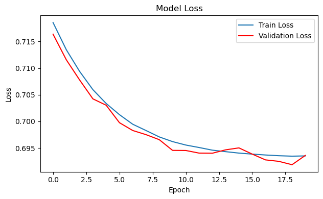

```python
# Plot training and validation loss graphs
plot_loss(history_es)
```

#### 7.2.6 Experimenting with Different Adaptive Learning Rate Optimizers

In this section, we investigate how different adaptive learning rate optimizers affect model performance. Optimizers are crucial in training neural networks as they update weights based on gradient calculations from backpropagation. The choice of optimizer can impact convergence speed and overall performance. We evaluated the Stochastic Gradient Descent (SGD), Adam, and RMSprop optimizers. For a fair comparison, we employed the same neural network architecture across all optimizers, training each for 20 epochs with a batch size of 32.

##### 7.2.6.1 Adam

Adam is an advanced optimizer that combines features from AdaGrad and RMSProp. It adapts the learning rate based on estimates of the first and second moments of the gradients, often leading to faster convergence.

```python
# Define the model
adam_model = Sequential([
        Flatten(input_shape=(64, 64, 3)),  # Flatten the input layer for fully connected layers
        Dense(256, activation='relu', kernel_regularizer=l2(0.01)),  # First hidden layer with L2 regularization
        Dropout(0.3),  # Dropout layer to prevent overfitting
        Dense(128, activation='relu', kernel_regularizer=l2(0.01)),  # Second hidden layer with L2 regularization
        Dropout(0.3),  # Dropout layer to prevent overfitting
        Dense(64, activation='relu', kernel_regularizer=l2(0.01)),  # Third hidden layer with L2 regularization
        Dropout(0.3),  # Dropout layer to prevent overfitting
        Dense(32, activation='relu', kernel_regularizer=l2(0.01)),  # Fourth hidden layer with L2 regularization
        Dropout(0.3),  # Dropout layer to prevent overfitting
        Dense(1, activation='sigmoid')  # Output layer for binary classification
    ])

# Compile the model
adam_model.compile(optimizer=Adam(learning_rate=0.001), loss='binary_crossentropy',
                   metrics=['accuracy', Precision(name='precision'), Recall(name='recall'), F1Score(name='f1', average='micro')])
```

```python
# Train the model
history_adam = adam_model.fit(
    train_images,
    train_binary_labels,
    validation_data=(val_images, val_binary_labels),
    epochs=20,
    batch_size=32,
    verbose=2,
    class_weight=class_weights_dict
)
```

```
94/94 - 6s - 65ms/step - accuracy: 0.5514 - f1: 0.8490 - loss: 5.2570 - precision: 0.7436 - recall: 0.5975 - val_accuracy: 0.2620 - val_f1: 0.8492 - val_loss: 3.0365 - val_precision: 0.0000e+00 - val_recall: 0.0000e+00
94/94 - 3s - 27ms/step - accuracy: 0.5677 - f1: 0.8488 - loss: 2.5248 - precision: 0.7846 - recall: 0.5703 - val_accuracy: 0.3757 - val_f1: 0.8492 - val_loss: 2.1944 - val_precision: 1.0000 - val_recall: 0.1540
94/94 - 3s - 27ms/step - accuracy: 0.6775 - f1: 0.8488 - loss: 1.9510 - precision: 0.8475 - recall: 0.6860 - val_accuracy: 0.8837 - val_f1: 0.8492 - val_loss: 1.6551 - val_precision: 0.9697 - val_recall: 0.8696
94/94 - 2s - 26ms/step - accuracy: 0.7273 - f1: 0.8488 - loss: 1.6710 - precision: 0.8793 - recall: 0.7305 - val_accuracy: 0.7219 - val_f1: 0.8492 - val_loss: 1.6231 - val_precision: 0.9886 - val_recall: 0.6304
94/94 - 2s - 26ms/step - accuracy: 0.7280 - f1: 0.8488 - loss: 1.4712 - precision: 0.8999 - recall: 0.7101 - val_accuracy: 0.8382 - val_f1: 0.8492 - val_loss: 1.2718 - val_precision: 0.9843 - val_recall: 0.7935
94/94 - 2s - 27ms/step - accuracy: 0.7444 - f1: 0.8488 - loss: 1.2927 - precision: 0.9206 - recall: 0.7151 - val_accuracy: 0.9131 - val_f1: 0.8492 - val_loss: 1.0183 - val_precision: 0.9674 - val_recall: 0.9130
94/94 - 3s - 27ms/step - accuracy: 0.7454 - f1: 0.8488 - loss: 1.1671 - precision: 0.9116 - recall: 0.7250 - val_accuracy: 0.8837 - val_f1: 0.8492 - val_loss: 0.9776 - val_precision: 0.9874 - val_recall: 0.8533
94/94 - 3s - 28ms/step - accuracy: 0.7558 - f1: 0.8488 - loss: 1.0434 - precision: 0.9187 - recall: 0.7337 - val_accuracy: 0.9091 - val_f1: 0.8492 - val_loss: 0.8145 - val_precision: 0.8941 - val_recall: 0.9946
94/94 - 3s - 27ms/step - accuracy: 0.7501 - f1: 0.8488 - loss: 1.0037 - precision: 0.9137 - recall: 0.7300 - val_accuracy: 0.9332 - val_f1: 0.8492 - val_loss: 0.7387 - val_precision: 0.9547 - val_recall: 0.9547
94/94 - 3s - 27ms/step - accuracy: 0.7283 - f1: 0.8488 - loss: 0.8966 - precision: 0.9148 - recall: 0.6965 - val_accuracy: 0.9091 - val_f1: 0.8492 - val_loss: 0.6756 - val_precision: 0.9708 - val_recall: 0.9040
94/94 - 3s - 27ms/step - accuracy: 0.7129 - f1: 0.8488 - loss: 0.9124 - precision: 0.9094 - recall: 0.6783 - val_accuracy: 0.8944 - val_f1: 0.8492 - val_loss: 0.7431 - val_precision: 0.9721 - val_recall: 0.8822
94/94 - 2s - 26ms/step - accuracy: 0.7237 - f1: 0.8488 - loss: 0.7938 - precision: 0.9285 - recall: 0.6774 - val_accuracy: 0.9305 - val_f1: 0.8492 - val_loss: 0.6227 - val_precision: 0.9195 - val_recall: 0.9928
94/94 - 3s - 27ms/step - accuracy: 0.6357 - f1: 0.8488 - loss: 0.7854 - precision: 0.9285 - recall: 0.5481 - val_accuracy: 0.8008 - val_f1: 0.8492 - val_loss: 0.8386 - val_precision: 0.9855 - val_recall: 0.7409
94/94 - 2s - 27ms/step - accuracy: 0.7959 - f1: 0.8488 - loss: 0.7231 - precision: 0.8821 - recall: 0.8348 - val_accuracy: 0.9318 - val_f1: 0.8492 - val_loss: 0.5301 - val_precision: 0.9580 - val_recall: 0.9493
94/94 - 2s - 27ms/step - accuracy: 0.8180 - f1: 0.8488 - loss: 0.6669 - precision: 0.8780 - recall: 0.8748 - val_accuracy: 0.9238 - val_f1: 0.8492 - val_loss: 0.4374 - val_precision: 0.9609 - val_recall: 0.9348
94/94 - 2s - 27ms/step - accuracy: 0.8207 - f1: 0.8488 - loss: 0.6389 - precision: 0.8774 - recall: 0.8798 - val_accuracy: 0.8436 - val_f1: 0.8492 - val_loss: 0.5637 - val_precision: 0.9866 - val_recall: 0.7989
94/94 - 2s - 27ms/step - accuracy: 0.8140 - f1: 0.8488 - loss: 0.6108 - precision: 0.8869 - recall: 0.8571 - val_accuracy: 0.9439 - val_f1: 0.8492 - val_loss: 0.5271 - val_precision: 0.9381 - val_recall: 0.9891
94/94 - 2s - 26ms/step - accuracy: 0.7932 - f1: 0.8488 - loss: 0.6242 - precision: 0.8668 - recall: 0.8503 - val_accuracy: 0.8824 - val_f1: 0.8492 - val_loss: 0.5522 - val_precision: 0.9854 - val_recall: 0.8533
94/94 - 2s - 26ms/step - accuracy: 0.8043 - f1: 0.8488 - loss: 0.6107 - precision: 0.8795 - recall: 0.8512 - val_accuracy: 0.9452 - val_f1: 0.8492 - val_loss: 0.4244 - val_precision: 0.9443 - val_recall: 0.9837
94/94 - 3s - 27ms/step - accuracy: 0.8143 - f1: 0.8488 - loss: 0.5581 - precision: 0.8784 - recall: 0.8684 - val_accuracy: 0.8516 - val_f1: 0.8492 - val_loss: 0.4861 - val_precision: 0.9868 - val_recall: 0.8098
```

```python
# Evaluate the model on the test set
adam_metrics = adam_model.evaluate(test_images, test_binary_labels, verbose=0)
print(f"Test Loss: {adam_metrics[0]:.3f}")
print(f"Test Accuracy: {adam_metrics[1]:.3f}")
print(f"Test Precision: {adam_metrics[2]:.3f}")
print(f"Test Recall: {adam_metrics[3]:.3f}")
print(f"Test F1 Score: {adam_metrics[4]:.3f}")
```

```
Test Loss: 0.509
Test Accuracy: 0.840
Test Precision: 0.989
Test Recall: 0.791
Test F1 Score: 0.879
```

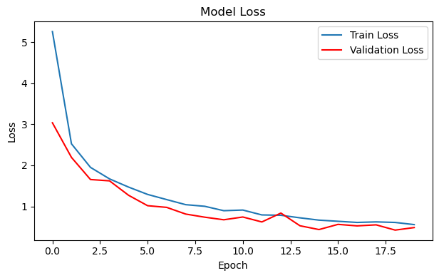

```python
# Plot training and validation loss graphs
plot_loss(history_adam)
```

The Adam model has shown strong precision and satisfactory recall, however, the accuracy and F1 Score, although still have decent performance, suggest room for improvement. Overall, Adam’s steady loss reduction highlights its reliability in managing the learning process, but further optimization and experimentation may be needed to enhance performance. The loss graph demonstrates a steady decline, indicating that the Adam optimizer effectively minimizes the loss over training.

##### 7.2.6.2 Stochastic Gradient Descent (SGD)

This basic optimizer updates weights using small batches of data, which can be simple but effective. Adam: An advanced optimizer that combines features from AdaGrad and RMSProp. It adapts the learning rate based on estimates of the first and second moments of the gradients, often leading to faster convergence.

```python
# Define the model
sgd_model = Sequential([
        Flatten(input_shape=(64, 64, 3)),  # Flatten the input layer for fully connected layers
        Dense(256, activation='relu', kernel_regularizer=l2(0.01)),  # First hidden layer with L2 regularization
        Dropout(0.3),  # Dropout layer to prevent overfitting
        Dense(128, activation='relu', kernel_regularizer=l2(0.01)),  # Second hidden layer with L2 regularization
        Dropout(0.3),  # Dropout layer to prevent overfitting
        Dense(64, activation='relu', kernel_regularizer=l2(0.01)),  # Third hidden layer with L2 regularization
        Dropout(0.3),  # Dropout layer to prevent overfitting
        Dense(32, activation='relu', kernel_regularizer=l2(0.01)),  # Fourth hidden layer with L2 regularization
        Dropout(0.3),  # Dropout layer to prevent overfitting
        Dense(1, activation='sigmoid')  # Output layer for binary classification
    ])

# Compile the model
sgd_model.compile(optimizer=SGD(learning_rate=0.001), loss='binary_crossentropy',
                   metrics=['accuracy', Precision(name='precision'), Recall(name='recall'), F1Score(name='f1', average='micro')])
```

```python
# Train the model
history_sgd = sgd_model.fit(
    train_images,
    train_binary_labels,
    validation_data=(val_images, val_binary_labels),
    epochs=20,
    batch_size=32,
    verbose=2,
    class_weight=class_weights_dict
)
```

```
94/94 - 4s - 40ms/step - accuracy: 0.4567 - f1: 0.8488 - loss: 8.6947 - precision: 0.7433 - recall: 0.4020 - val_accuracy: 0.4211 - val_f1: 0.8492 - val_loss: 8.6569 - val_precision: 0.9612 - val_recall: 0.2246
94/94 - 1s - 14ms/step - accuracy: 0.5253 - f1: 0.8488 - loss: 8.6263 - precision: 0.7980 - recall: 0.4769 - val_accuracy: 0.7701 - val_f1: 0.8492 - val_loss: 8.5705 - val_precision: 0.9260 - val_recall: 0.7482
94/94 - 1s - 15ms/step - accuracy: 0.5547 - f1: 0.8488 - loss: 8.5770 - precision: 0.8156 - recall: 0.5118 - val_accuracy: 0.8489 - val_f1: 0.8492 - val_loss: 8.4985 - val_precision: 0.9229 - val_recall: 0.8678
94/94 - 1s - 14ms/step - accuracy: 0.5995 - f1: 0.8488 - loss: 8.5259 - precision: 0.8293 - recall: 0.5753 - val_accuracy: 0.8596 - val_f1: 0.8492 - val_loss: 8.4204 - val_precision: 0.9178 - val_recall: 0.8895
94/94 - 1s - 14ms/step - accuracy: 0.6440 - f1: 0.8488 - loss: 8.4788 - precision: 0.8594 - recall: 0.6184 - val_accuracy: 0.8061 - val_f1: 0.8492 - val_loss: 8.4111 - val_precision: 0.9594 - val_recall: 0.7699
94/94 - 1s - 14ms/step - accuracy: 0.6855 - f1: 0.8488 - loss: 8.4133 - precision: 0.8821 - recall: 0.6620 - val_accuracy: 0.8369 - val_f1: 0.8492 - val_loss: 8.3226 - val_precision: 0.9555 - val_recall: 0.8170
94/94 - 1s - 14ms/step - accuracy: 0.7096 - f1: 0.8488 - loss: 8.3614 - precision: 0.8971 - recall: 0.6847 - val_accuracy: 0.8316 - val_f1: 0.8492 - val_loss: 8.2795 - val_precision: 0.9630 - val_recall: 0.8025
94/94 - 1s - 14ms/step - accuracy: 0.7377 - f1: 0.8488 - loss: 8.3103 - precision: 0.9002 - recall: 0.7246 - val_accuracy: 0.8850 - val_f1: 0.8492 - val_loss: 8.1808 - val_precision: 0.9413 - val_recall: 0.9004
94/94 - 1s - 14ms/step - accuracy: 0.7477 - f1: 0.8488 - loss: 8.2620 - precision: 0.9023 - recall: 0.7377 - val_accuracy: 0.8864 - val_f1: 0.8492 - val_loss: 8.1155 - val_precision: 0.9431 - val_recall: 0.9004
94/94 - 1s - 14ms/step - accuracy: 0.7762 - f1: 0.8488 - loss: 8.2111 - precision: 0.9178 - recall: 0.7650 - val_accuracy: 0.9011 - val_f1: 0.8492 - val_loss: 8.0502 - val_precision: 0.9314 - val_recall: 0.9348
94/94 - 1s - 14ms/step - accuracy: 0.7829 - f1: 0.8488 - loss: 8.1695 - precision: 0.9156 - recall: 0.7772 - val_accuracy: 0.8783 - val_f1: 0.8492 - val_loss: 8.0282 - val_precision: 0.9511 - val_recall: 0.8804
94/94 - 1s - 14ms/step - accuracy: 0.8023 - f1: 0.8488 - loss: 8.1117 - precision: 0.9274 - recall: 0.7940 - val_accuracy: 0.9024 - val_f1: 0.8492 - val_loss: 7.9564 - val_precision: 0.9477 - val_recall: 0.9185
94/94 - 1s - 14ms/step - accuracy: 0.8093 - f1: 0.8488 - loss: 8.0670 - precision: 0.9378 - recall: 0.7940 - val_accuracy: 0.8824 - val_f1: 0.8492 - val_loss: 7.9280 - val_precision: 0.9567 - val_recall: 0.8804
94/94 - 1s - 14ms/step - accuracy: 0.8147 - f1: 0.8488 - loss: 8.0319 - precision: 0.9301 - recall: 0.8094 - val_accuracy: 0.8971 - val_f1: 0.8492 - val_loss: 7.8876 - val_precision: 0.9507 - val_recall: 0.9076
94/94 - 1s - 14ms/step - accuracy: 0.8240 - f1: 0.8488 - loss: 7.9824 - precision: 0.9334 - recall: 0.8199 - val_accuracy: 0.8824 - val_f1: 0.8492 - val_loss: 7.8756 - val_precision: 0.9640 - val_recall: 0.8732
94/94 - 1s - 14ms/step - accuracy: 0.8297 - f1: 0.8488 - loss: 7.9634 - precision: 0.9375 - recall: 0.8240 - val_accuracy: 0.8650 - val_f1: 0.8492 - val_loss: 7.8875 - val_precision: 0.9767 - val_recall: 0.8370
94/94 - 1s - 14ms/step - accuracy: 0.8401 - f1: 0.8488 - loss: 7.9046 - precision: 0.9426 - recall: 0.8339 - val_accuracy: 0.8997 - val_f1: 0.8492 - val_loss: 7.7653 - val_precision: 0.9543 - val_recall: 0.9076
94/94 - 1s - 14ms/step - accuracy: 0.8558 - f1: 0.8488 - loss: 7.8650 - precision: 0.9448 - recall: 0.8544 - val_accuracy: 0.8797 - val_f1: 0.8492 - val_loss: 7.7676 - val_precision: 0.9657 - val_recall: 0.8678
94/94 - 1s - 14ms/step - accuracy: 0.8461 - f1: 0.8488 - loss: 7.8396 - precision: 0.9417 - recall: 0.8435 - val_accuracy: 0.9064 - val_f1: 0.8492 - val_loss: 7.6979 - val_precision: 0.9530 - val_recall: 0.9185
94/94 - 1s - 14ms/step - accuracy: 0.8581 - f1: 0.8488 - loss: 7.7934 - precision: 0.9504 - recall: 0.8521 - val_accuracy: 0.8850 - val_f1: 0.8492 - val_loss: 7.7021 - val_precision: 0.9736 - val_recall: 0.8678
```

```python
# Evaluate the model on the test set
sgd_metrics = sgd_model.evaluate(test_images, test_binary_labels, verbose=0)
print(f"Test Loss: {sgd_metrics[0]:.3f}")
print(f"Test Accuracy: {sgd_metrics[1]:.3f}")
print(f"Test Precision: {sgd_metrics[2]:.3f}")
print(f"Test Recall: {sgd_metrics[3]:.3f}")
print(f"Test F1 Score: {sgd_metrics[4]:.3f}")
```

```
Test Loss: 7.701
Test Accuracy: 0.888
Test Precision: 0.977
Test Recall: 0.868
Test F1 Score: 0.919
```

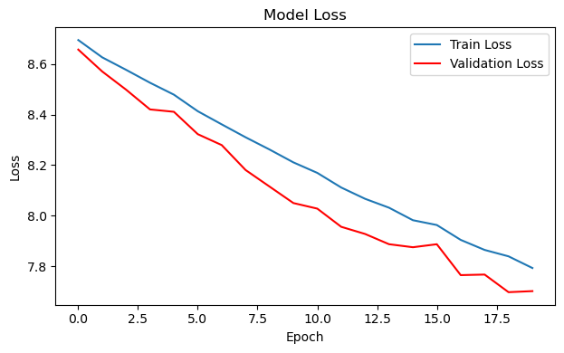

```python
# Plot training and validation loss graphs
plot_loss(history_sgd)
```

##### 7.2.6.3 RMSprop

The RMSprop optimizer maintains a moving average of squared gradients to adjust the learning rate, helping to stabilize the training process.

```python
# Define the model
rmsprop_model = Sequential([
        Flatten(input_shape=(64, 64, 3)),  # Flatten the input layer for fully connected layers
        Dense(256, activation='relu', kernel_regularizer=l2(0.01)),  # First hidden layer with L2 regularization
        Dropout(0.3),  # Dropout layer to prevent overfitting
        Dense(128, activation='relu', kernel_regularizer=l2(0.01)),  # Second hidden layer with L2 regularization
        Dropout(0.3),  # Dropout layer to prevent overfitting
        Dense(64, activation='relu', kernel_regularizer=l2(0.01)),  # Third hidden layer with L2 regularization
        Dropout(0.3),  # Dropout layer to prevent overfitting
        Dense(32, activation='relu', kernel_regularizer=l2(0.01)),  # Fourth hidden layer with L2 regularization
        Dropout(0.3),  # Dropout layer to prevent overfitting
        Dense(1, activation='sigmoid')  # Output layer for binary classification
    ])

# Compile the model
rmsprop_model.compile(optimizer=RMSprop(learning_rate=0.001), loss='binary_crossentropy',
                   metrics=['accuracy', Precision(name='precision'), Recall(name='recall'), F1Score(name='f1', average='micro')])
```

```python
# Train the model
history_rmsprop = rmsprop_model.fit(
    train_images,
    train_binary_labels,
    validation_data=(val_images, val_binary_labels),
    epochs=20,
    batch_size=32,
    verbose=2,
    class_weight=class_weights_dict
)
```

```
94/94 - 5s - 54ms/step - accuracy: 0.5065 - f1: 0.8483 - loss: 4.1471 - precision: 0.7682 - recall: 0.4737 - val_accuracy: 0.7380 - val_f1: 0.8492 - val_loss: 1.7825 - val_precision: 0.7380 - val_recall: 1.0000
94/94 - 2s - 23ms/step - accuracy: 0.6969 - f1: 0.8488 - loss: 1.3507 - precision: 0.8352 - recall: 0.7337 - val_accuracy: 0.8877 - val_f1: 0.8492 - val_loss: 0.8838 - val_precision: 0.9091 - val_recall: 0.9420
94/94 - 2s - 23ms/step - accuracy: 0.7715 - f1: 0.8488 - loss: 0.8154 - precision: 0.8430 - recall: 0.8480 - val_accuracy: 0.7473 - val_f1: 0.8492 - val_loss: 0.6664 - val_precision: 0.7449 - val_recall: 1.0000
94/94 - 2s - 23ms/step - accuracy: 0.7886 - f1: 0.8488 - loss: 0.6700 - precision: 0.8463 - recall: 0.8716 - val_accuracy: 0.9011 - val_f1: 0.8492 - val_loss: 0.3679 - val_precision: 0.9509 - val_recall: 0.9130
94/94 - 2s - 23ms/step - accuracy: 0.8076 - f1: 0.8488 - loss: 0.5999 - precision: 0.8612 - recall: 0.8811 - val_accuracy: 0.8516 - val_f1: 0.8492 - val_loss: 0.4223 - val_precision: 0.8336 - val_recall: 0.9982
94/94 - 2s - 23ms/step - accuracy: 0.7963 - f1: 0.8488 - loss: 0.6180 - precision: 0.8524 - recall: 0.8752 - val_accuracy: 0.9158 - val_f1: 0.8492 - val_loss: 0.3866 - val_precision: 0.9109 - val_recall: 0.9819
94/94 - 2s - 23ms/step - accuracy: 0.8103 - f1: 0.8488 - loss: 0.5711 - precision: 0.8623 - recall: 0.8838 - val_accuracy: 0.7660 - val_f1: 0.8492 - val_loss: 0.5794 - val_precision: 0.9871 - val_recall: 0.6920
94/94 - 2s - 23ms/step - accuracy: 0.8183 - f1: 0.8488 - loss: 0.5817 - precision: 0.8600 - recall: 0.9002 - val_accuracy: 0.9238 - val_f1: 0.8492 - val_loss: 0.3576 - val_precision: 0.9492 - val_recall: 0.9475
94/94 - 2s - 23ms/step - accuracy: 0.8123 - f1: 0.8488 - loss: 0.5713 - precision: 0.8605 - recall: 0.8897 - val_accuracy: 0.9372 - val_f1: 0.8492 - val_loss: 0.4096 - val_precision: 0.9316 - val_recall: 0.9873
94/94 - 2s - 23ms/step - accuracy: 0.8116 - f1: 0.8488 - loss: 0.5495 - precision: 0.8613 - recall: 0.8875 - val_accuracy: 0.8930 - val_f1: 0.8492 - val_loss: 0.3544 - val_precision: 0.8770 - val_recall: 0.9946
94/94 - 2s - 23ms/step - accuracy: 0.8137 - f1: 0.8488 - loss: 0.5688 - precision: 0.8691 - recall: 0.8798 - val_accuracy: 0.9318 - val_f1: 0.8492 - val_loss: 0.3335 - val_precision: 0.9341 - val_recall: 0.9764
94/94 - 2s - 23ms/step - accuracy: 0.8086 - f1: 0.8488 - loss: 0.5683 - precision: 0.8666 - recall: 0.8752 - val_accuracy: 0.7941 - val_f1: 0.8492 - val_loss: 0.4858 - val_precision: 0.9854 - val_recall: 0.7319
94/94 - 2s - 23ms/step - accuracy: 0.8217 - f1: 0.8488 - loss: 0.5607 - precision: 0.8628 - recall: 0.9015 - val_accuracy: 0.9291 - val_f1: 0.8492 - val_loss: 0.5247 - val_precision: 0.9495 - val_recall: 0.9547
94/94 - 2s - 22ms/step - accuracy: 0.8126 - f1: 0.8488 - loss: 0.5672 - precision: 0.8618 - recall: 0.8884 - val_accuracy: 0.8957 - val_f1: 0.8492 - val_loss: 0.3262 - val_precision: 0.9759 - val_recall: 0.8804
94/94 - 2s - 23ms/step - accuracy: 0.7966 - f1: 0.8488 - loss: 0.5775 - precision: 0.8664 - recall: 0.8562 - val_accuracy: 0.8877 - val_f1: 0.8492 - val_loss: 0.6128 - val_precision: 0.9776 - val_recall: 0.8678
94/94 - 2s - 23ms/step - accuracy: 0.8076 - f1: 0.8488 - loss: 0.5643 - precision: 0.8684 - recall: 0.8711 - val_accuracy: 0.8422 - val_f1: 0.8492 - val_loss: 0.4780 - val_precision: 0.8249 - val_recall: 0.9982
94/94 - 2s - 23ms/step - accuracy: 0.8137 - f1: 0.8488 - loss: 0.5584 - precision: 0.8588 - recall: 0.8943 - val_accuracy: 0.8382 - val_f1: 0.8492 - val_loss: 0.3837 - val_precision: 0.8212 - val_recall: 0.9982
94/94 - 2s - 23ms/step - accuracy: 0.8140 - f1: 0.8488 - loss: 0.5568 - precision: 0.8624 - recall: 0.8897 - val_accuracy: 0.8957 - val_f1: 0.8492 - val_loss: 0.3233 - val_precision: 0.9721 - val_recall: 0.8841
94/94 - 2s - 23ms/step - accuracy: 0.8247 - f1: 0.8488 - loss: 0.5351 - precision: 0.8614 - recall: 0.9083 - val_accuracy: 0.9104 - val_f1: 0.8492 - val_loss: 0.3221 - val_precision: 0.8956 - val_recall: 0.9946
94/94 - 2s - 23ms/step - accuracy: 0.8177 - f1: 0.8488 - loss: 0.5739 - precision: 0.8643 - recall: 0.8929 - val_accuracy: 0.8930 - val_f1: 0.8492 - val_loss: 0.6473 - val_precision: 0.8746 - val_recall: 0.9982
```

```python
# Evaluate the model on the test set
rmsprop_metrics = rmsprop_model.evaluate(test_images, test_binary_labels, verbose=0)
print(f"Test Loss: {rmsprop_metrics[0]:.3f}")
print(f"Test Accuracy: {rmsprop_metrics[1]:.3f}")
print(f"Test Precision: {rmsprop_metrics[2]:.3f}")
print(f"Test Recall: {rmsprop_metrics[3]:.3f}")
print(f"Test F1 Score: {rmsprop_metrics[4]:.3f}")
```

```
Test Loss: 0.657
Test Accuracy: 0.872
Test Precision: 0.856
Test Recall: 0.993
Test F1 Score: 0.919
```

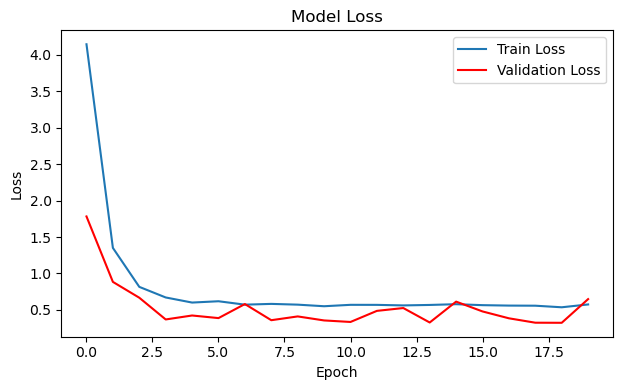

```python
# Plot training and validation loss graphs
plot_loss(history_rmsprop)
```

##### 7.2.6.4 plotting metrics graph

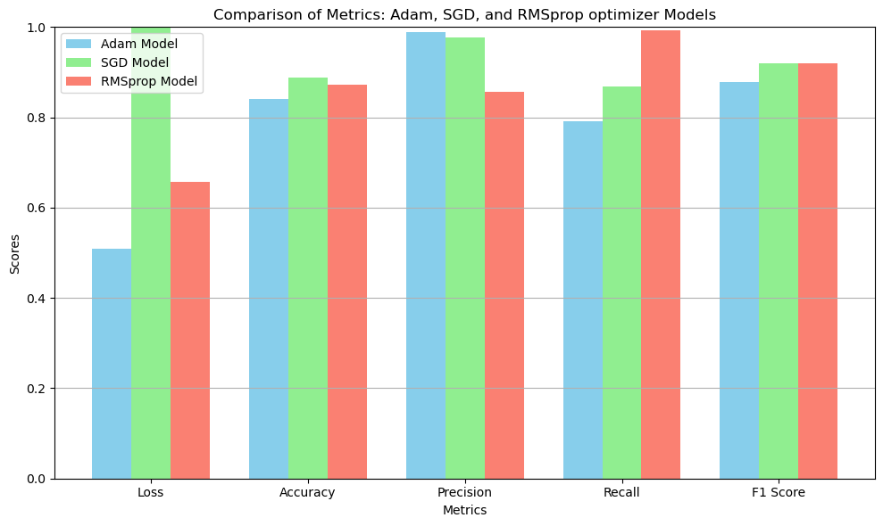

```python
# Extracting relevant Metric Scores
adam_scores = {'Loss':adam_metrics[0], 'Accuracy': adam_metrics[1], 'Precision': adam_metrics[2], 'Recall': adam_metrics[3], 'F1 Score': adam_metrics[4]}
sgd_scores = {'Loss':sgd_metrics[0], 'Accuracy': sgd_metrics[1], 'Precision': sgd_metrics[2], 'Recall': sgd_metrics[3], 'F1 Score': sgd_metrics[4]}
rmsprop_scores = {'Loss':rmsprop_metrics[0], 'Accuracy': rmsprop_metrics[1], 'Precision': rmsprop_metrics[2], 'Recall': rmsprop_metrics[3],
                   'F1 Score': rmsprop_metrics[4]}

# Extract metric names and their values
metrics = list(adam_scores.keys())
adam_values = list(adam_scores.values())
sgd_values = list(sgd_scores.values())
rmsprop_values = list(rmsprop_scores.values())

# Create an index for the groups
x = np.arange(len(metrics))

# Define the width of the bars
width = 0.25

# Plotting the bar chart
plt.figure(figsize=(10, 6))
plt.bar(x - width, adam_values, width, label='Adam Model', color='skyblue')
plt.bar(x, sgd_values, width, label='SGD Model', color='lightgreen')
plt.bar(x + width, rmsprop_values, width, label='RMSprop Model', color='salmon')

# Adding labels and title
plt.xlabel('Metrics')
plt.ylabel('Scores')
plt.title('Comparison of Metrics: Adam, SGD, and RMSprop optimizer Models')
plt.xticks(x, metrics)
plt.ylim(0, 1)  # Limits from 0 to 1 for better visualization of percentage-based scores
plt.legend(loc='best')

plt.grid(axis='y')
plt.tight_layout()
plt.show()
```

#### 7.2.7 Experimenting with different epochs

In this section, we explore the impact of varying the number of training epochs on model performance. The number of epochs determines how many times the learning algorithm will work through the entire training dataset. Choosing an appropriate number of epochs is crucial to achieving the best model performance, as too few epochs may lead to underfitting while too many can cause overfitting.

We will train the model with 10, 20 and 30 epoch counts to find the optimal balance. By evaluating the test loss, accuracy, precision, recall, and F1 Score for each epoch configuration, we aim to identify the most effective training duration that maximizes model performance while avoiding overfitting.

##### 7.2.7.1 10 Epochs

```python
# Define the model
epoch1_model = Sequential([
        Flatten(input_shape=(64, 64, 3)),  # Flatten the input layer for fully connected layers
        Dense(256, activation='relu', kernel_regularizer=l2(0.01)),  # First hidden layer with L2 regularization
        Dropout(0.3),  # Dropout layer to prevent overfitting
        Dense(128, activation='relu', kernel_regularizer=l2(0.01)),  # Second hidden layer with L2 regularization
        Dropout(0.3),  # Dropout layer to prevent overfitting
        Dense(64, activation='relu', kernel_regularizer=l2(0.01)),  # Third hidden layer with L2 regularization
        Dropout(0.3),  # Dropout layer to prevent overfitting
        Dense(32, activation='relu', kernel_regularizer=l2(0.01)),  # Fourth hidden layer with L2 regularization
        Dropout(0.3),  # Dropout layer to prevent overfitting
        Dense(1, activation='sigmoid')  # Output layer for binary classification
    ])

# Compile the model
epoch1_model.compile(optimizer=Adam(learning_rate=0.001), loss='binary_crossentropy',
                   metrics=['accuracy', Precision(name='precision'), Recall(name='recall'), F1Score(name='f1', average='micro')])
```

```python
# Train the model
history_epoch1 = epoch1_model.fit(
    train_images,
    train_binary_labels,
    validation_data=(val_images, val_binary_labels),
    epochs=10,
    batch_size=32,
    verbose=2,
    class_weight=class_weights_dict
)
```

```
94/94 - 6s - 69ms/step - accuracy: 0.5433 - f1: 0.8488 - loss: 4.8615 - precision: 0.7499 - recall: 0.5712 - val_accuracy: 0.2620 - val_f1: 0.8492 - val_loss: 2.8854 - val_precision: 0.0000e+00 - val_recall: 0.0000e+00
94/94 - 3s - 27ms/step - accuracy: 0.5169 - f1: 0.8488 - loss: 2.4147 - precision: 0.7624 - recall: 0.5009 - val_accuracy: 0.4532 - val_f1: 0.8492 - val_loss: 2.1153 - val_precision: 0.9864 - val_recall: 0.2627
94/94 - 2s - 27ms/step - accuracy: 0.6096 - f1: 0.8488 - loss: 1.9234 - precision: 0.8280 - recall: 0.5939 - val_accuracy: 0.6457 - val_f1: 0.8492 - val_loss: 1.8331 - val_precision: 0.9864 - val_recall: 0.5272
94/94 - 3s - 27ms/step - accuracy: 0.7337 - f1: 0.8488 - loss: 1.6624 - precision: 0.8644 - recall: 0.7577 - val_accuracy: 0.7754 - val_f1: 0.8492 - val_loss: 1.6095 - val_precision: 0.9898 - val_recall: 0.7029
94/94 - 2s - 27ms/step - accuracy: 0.7447 - f1: 0.8488 - loss: 1.4948 - precision: 0.8509 - recall: 0.7926 - val_accuracy: 0.8824 - val_f1: 0.8492 - val_loss: 1.2774 - val_precision: 0.8659 - val_recall: 0.9946
94/94 - 3s - 27ms/step - accuracy: 0.7916 - f1: 0.8488 - loss: 1.3406 - precision: 0.8572 - recall: 0.8607 - val_accuracy: 0.9131 - val_f1: 0.8492 - val_loss: 1.2022 - val_precision: 0.8998 - val_recall: 0.9928
94/94 - 3s - 27ms/step - accuracy: 0.8150 - f1: 0.8488 - loss: 1.2127 - precision: 0.8641 - recall: 0.8888 - val_accuracy: 0.9291 - val_f1: 0.8492 - val_loss: 0.8969 - val_precision: 0.9512 - val_recall: 0.9529
94/94 - 3s - 27ms/step - accuracy: 0.8177 - f1: 0.8488 - loss: 1.1277 - precision: 0.8662 - recall: 0.8902 - val_accuracy: 0.9238 - val_f1: 0.8492 - val_loss: 0.9397 - val_precision: 0.9592 - val_recall: 0.9366
94/94 - 3s - 27ms/step - accuracy: 0.8314 - f1: 0.8488 - loss: 1.0211 - precision: 0.8676 - recall: 0.9102 - val_accuracy: 0.8516 - val_f1: 0.8492 - val_loss: 0.9208 - val_precision: 0.9846 - val_recall: 0.8116
94/94 - 3s - 27ms/step - accuracy: 0.8464 - f1: 0.8488 - loss: 0.9328 - precision: 0.8727 - recall: 0.9270 - val_accuracy: 0.7754 - val_f1: 0.8492 - val_loss: 0.9534 - val_precision: 0.9848 - val_recall: 0.7065
```

```python
# Evaluate the model on the test set
epoch1_metrics = epoch1_model.evaluate(test_images, test_binary_labels, verbose=0)
print(f"Test Loss: {epoch1_metrics[0]:.3f}")
print(f"Test Accuracy: {epoch1_metrics[1]:.3f}")
print(f"Test Precision: {epoch1_metrics[2]:.3f}")
print(f"Test Recall: {epoch1_metrics[3]:.3f}")
print(f"Test F1 Score: {epoch1_metrics[4]:.3f}")
```

```
Test Loss: 0.966
Test Accuracy: 0.760
Test Precision: 0.998
Test Recall: 0.676
Test F1 Score: 0.806
```

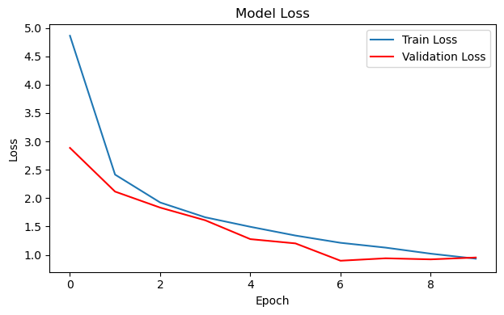

```python
# Plot training and validation loss graphs
plot_loss(history_epoch1)
```

The results indicate a relatively high test loss and moderate accuracy, with precision remaining high but recall lower. This suggests that while the model performs well in terms of precision, it may be underfitting due to the limited number of epochs, leading to suboptimal recall and overall F1 Score.

##### 7.2.7.2 20 Epochs

```python
# Define the model
epoch2_model = Sequential([
        Flatten(input_shape=(64, 64, 3)),  # Flatten the input layer for fully connected layers
        Dense(256, activation='relu', kernel_regularizer=l2(0.01)),  # First hidden layer with L2 regularization
        Dropout(0.3),  # Dropout layer to prevent overfitting
        Dense(128, activation='relu', kernel_regularizer=l2(0.01)),  # Second hidden layer with L2 regularization
        Dropout(0.3),  # Dropout layer to prevent overfitting
        Dense(64, activation='relu', kernel_regularizer=l2(0.01)),  # Third hidden layer with L2 regularization
        Dropout(0.3),  # Dropout layer to prevent overfitting
        Dense(32, activation='relu', kernel_regularizer=l2(0.01)),  # Fourth hidden layer with L2 regularization
        Dropout(0.3),  # Dropout layer to prevent overfitting
        Dense(1, activation='sigmoid')  # Output layer for binary classification
    ])

# Compile the model
epoch2_model.compile(optimizer=Adam(learning_rate=0.001), loss='binary_crossentropy',
                   metrics=['accuracy', Precision(name='precision'), Recall(name='recall'), F1Score(name='f1', average='micro')])
```

```python
# Train the model
history_epoch2 = epoch2_model.fit(
    train_images,
    train_binary_labels,
    validation_data=(val_images, val_binary_labels),
    epochs=20,
    batch_size=32,
    verbose=2,
    class_weight=class_weights_dict
)
```

```
94/94 - 6s - 68ms/step - accuracy: 0.4684 - f1: 0.8488 - loss: 4.8514 - precision: 0.7290 - recall: 0.4442 - val_accuracy: 0.7567 - val_f1: 0.8492 - val_loss: 2.7797 - val_precision: 0.7643 - val_recall: 0.9692
94/94 - 2s - 26ms/step - accuracy: 0.5065 - f1: 0.8488 - loss: 2.3530 - precision: 0.7409 - recall: 0.5086 - val_accuracy: 0.7754 - val_f1: 0.8492 - val_loss: 2.0326 - val_precision: 0.7674 - val_recall: 0.9982
94/94 - 2s - 26ms/step - accuracy: 0.5570 - f1: 0.8488 - loss: 1.8776 - precision: 0.7973 - recall: 0.5354 - val_accuracy: 0.3316 - val_f1: 0.8492 - val_loss: 1.8271 - val_precision: 1.0000 - val_recall: 0.0942
94/94 - 2s - 26ms/step - accuracy: 0.6076 - f1: 0.8488 - loss: 1.6338 - precision: 0.8324 - recall: 0.5858 - val_accuracy: 0.6511 - val_f1: 0.8492 - val_loss: 1.5741 - val_precision: 0.9866 - val_recall: 0.5344
94/94 - 2s - 26ms/step - accuracy: 0.7571 - f1: 0.8488 - loss: 1.4154 - precision: 0.8577 - recall: 0.8040 - val_accuracy: 0.8890 - val_f1: 0.8492 - val_loss: 1.2211 - val_precision: 0.9681 - val_recall: 0.8786
94/94 - 2s - 26ms/step - accuracy: 0.8006 - f1: 0.8488 - loss: 1.2562 - precision: 0.8615 - recall: 0.8693 - val_accuracy: 0.8596 - val_f1: 0.8492 - val_loss: 1.1696 - val_precision: 0.9827 - val_recall: 0.8243
94/94 - 3s - 27ms/step - accuracy: 0.7986 - f1: 0.8488 - loss: 1.1550 - precision: 0.8501 - recall: 0.8825 - val_accuracy: 0.8917 - val_f1: 0.8492 - val_loss: 1.0622 - val_precision: 0.8732 - val_recall: 0.9982
94/94 - 3s - 27ms/step - accuracy: 0.8220 - f1: 0.8488 - loss: 1.0464 - precision: 0.8663 - recall: 0.8970 - val_accuracy: 0.8917 - val_f1: 0.8492 - val_loss: 0.9241 - val_precision: 0.9816 - val_recall: 0.8696
94/94 - 2s - 26ms/step - accuracy: 0.8317 - f1: 0.8488 - loss: 0.9531 - precision: 0.8735 - recall: 0.9025 - val_accuracy: 0.9118 - val_f1: 0.8492 - val_loss: 0.8666 - val_precision: 0.9728 - val_recall: 0.9058
94/94 - 2s - 27ms/step - accuracy: 0.8428 - f1: 0.8488 - loss: 0.8663 - precision: 0.8756 - recall: 0.9170 - val_accuracy: 0.9345 - val_f1: 0.8492 - val_loss: 0.7262 - val_precision: 0.9499 - val_recall: 0.9620
94/94 - 2s - 26ms/step - accuracy: 0.8431 - f1: 0.8488 - loss: 0.8058 - precision: 0.8728 - recall: 0.9215 - val_accuracy: 0.9171 - val_f1: 0.8492 - val_loss: 0.6666 - val_precision: 0.9003 - val_recall: 0.9982
94/94 - 2s - 26ms/step - accuracy: 0.8528 - f1: 0.8488 - loss: 0.7490 - precision: 0.8763 - recall: 0.9319 - val_accuracy: 0.7928 - val_f1: 0.8492 - val_loss: 0.8209 - val_precision: 0.9853 - val_recall: 0.7301
94/94 - 2s - 27ms/step - accuracy: 0.8297 - f1: 0.8488 - loss: 0.7378 - precision: 0.8642 - recall: 0.9124 - val_accuracy: 0.9398 - val_f1: 0.8492 - val_loss: 0.6413 - val_precision: 0.9319 - val_recall: 0.9909
94/94 - 3s - 27ms/step - accuracy: 0.8488 - f1: 0.8488 - loss: 0.6771 - precision: 0.8776 - recall: 0.9238 - val_accuracy: 0.9385 - val_f1: 0.8492 - val_loss: 0.5168 - val_precision: 0.9274 - val_recall: 0.9946
94/94 - 2s - 27ms/step - accuracy: 0.8558 - f1: 0.8488 - loss: 0.6505 - precision: 0.8829 - recall: 0.9274 - val_accuracy: 0.9211 - val_f1: 0.8492 - val_loss: 0.5092 - val_precision: 0.9768 - val_recall: 0.9149
94/94 - 2s - 26ms/step - accuracy: 0.8508 - f1: 0.8488 - loss: 0.6235 - precision: 0.8782 - recall: 0.9260 - val_accuracy: 0.9385 - val_f1: 0.8492 - val_loss: 0.4831 - val_precision: 0.9634 - val_recall: 0.9529
94/94 - 2s - 26ms/step - accuracy: 0.8451 - f1: 0.8488 - loss: 0.6275 - precision: 0.8777 - recall: 0.9179 - val_accuracy: 0.9479 - val_f1: 0.8492 - val_loss: 0.5030 - val_precision: 0.9476 - val_recall: 0.9837
94/94 - 2s - 26ms/step - accuracy: 0.8431 - f1: 0.8488 - loss: 0.6235 - precision: 0.8703 - recall: 0.9251 - val_accuracy: 0.9492 - val_f1: 0.8492 - val_loss: 0.4831 - val_precision: 0.9477 - val_recall: 0.9855
94/94 - 3s - 27ms/step - accuracy: 0.8411 - f1: 0.8488 - loss: 0.6047 - precision: 0.8734 - recall: 0.9174 - val_accuracy: 0.9345 - val_f1: 0.8492 - val_loss: 0.4915 - val_precision: 0.9199 - val_recall: 0.9982
94/94 - 2s - 26ms/step - accuracy: 0.8528 - f1: 0.8488 - loss: 0.5703 - precision: 0.8769 - recall: 0.9310 - val_accuracy: 0.9238 - val_f1: 0.8492 - val_loss: 0.4437 - val_precision: 0.9679 - val_recall: 0.9275
```

```python
# Evaluate the model on the test set
epoch2_metrics = epoch2_model.evaluate(test_images, test_binary_labels, verbose=0)
print(f"Test Loss: {epoch2_metrics[0]:.3f}")
print(f"Test Accuracy: {epoch2_metrics[1]:.3f}")
print(f"Test Precision: {epoch2_metrics[2]:.3f}")
print(f"Test Recall: {epoch2_metrics[3]:.3f}")
print(f"Test F1 Score: {epoch2_metrics[4]:.3f}")
```

```
Test Loss: 0.445
Test Accuracy: 0.929
Test Precision: 0.967
Test Recall: 0.936
Test F1 Score: 0.951
```

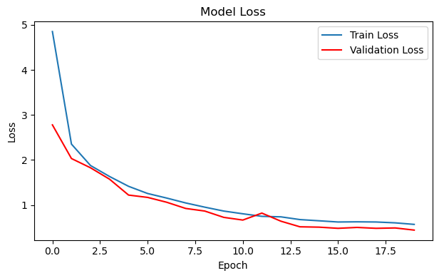

```python
# Plot training and validation loss graphs
plot_loss(history_epoch2)
```

The metrics show improved performance compared to the 10-epoch model, with lower loss, higher accuracy, and better balance between precision and recall. The steadily decreasing loss graph, which remains below the training loss graph, indicates effective learning without significant overfitting. This suggests that 20 epochs is a suitable choice for achieving a good trade-off between model complexity and performance.

##### 7.2.7.3 30 Epochs

```python
# Define the model
epoch3_model = Sequential([
        Flatten(input_shape=(64, 64, 3)),  # Flatten the input layer for fully connected layers
        Dense(256, activation='relu', kernel_regularizer=l2(0.01)),  # First hidden layer with L2 regularization
        Dropout(0.3),  # Dropout layer to prevent overfitting
        Dense(128, activation='relu', kernel_regularizer=l2(0.01)),  # Second hidden layer with L2 regularization
        Dropout(0.3),  # Dropout layer to prevent overfitting
        Dense(64, activation='relu', kernel_regularizer=l2(0.01)),  # Third hidden layer with L2 regularization
        Dropout(0.3),  # Dropout layer to prevent overfitting
        Dense(32, activation='relu', kernel_regularizer=l2(0.01)),  # Fourth hidden layer with L2 regularization
        Dropout(0.3),  # Dropout layer to prevent overfitting
        Dense(1, activation='sigmoid')  # Output layer for binary classification
    ])

# Compile the model
epoch3_model.compile(optimizer=Adam(learning_rate=0.001), loss='binary_crossentropy',
                   metrics=['accuracy', Precision(name='precision'), Recall(name='recall'), F1Score(name='f1', average='micro')])
```

```python
# Train the model
history_epoch3 = epoch3_model.fit(
    train_images,
    train_binary_labels,
    validation_data=(val_images, val_binary_labels),
    epochs=30,
    batch_size=32,
    verbose=2,
    class_weight=class_weights_dict
)
```

```
94/94 - 6s - 64ms/step - accuracy: 0.5176 - f1: 0.8488 - loss: 4.7782 - precision: 0.7527 - recall: 0.5150 - val_accuracy: 0.7380 - val_f1: 0.8492 - val_loss: 2.6267 - val_precision: 0.7380 - val_recall: 1.0000
94/94 - 2s - 26ms/step - accuracy: 0.5135 - f1: 0.8488 - loss: 2.2224 - precision: 0.7477 - recall: 0.5136 - val_accuracy: 0.7380 - val_f1: 0.8492 - val_loss: 1.8878 - val_precision: 0.7380 - val_recall: 1.0000
94/94 - 2s - 26ms/step - accuracy: 0.5122 - f1: 0.8488 - loss: 1.7406 - precision: 0.7388 - recall: 0.5236 - val_accuracy: 0.7447 - val_f1: 0.8492 - val_loss: 1.5959 - val_precision: 0.7429 - val_recall: 1.0000
94/94 - 2s - 27ms/step - accuracy: 0.5524 - f1: 0.8488 - loss: 1.4884 - precision: 0.7891 - recall: 0.5363 - val_accuracy: 0.3342 - val_f1: 0.8492 - val_loss: 1.5785 - val_precision: 1.0000 - val_recall: 0.0978
94/94 - 2s - 26ms/step - accuracy: 0.7330 - f1: 0.8488 - loss: 1.2762 - precision: 0.8533 - recall: 0.7704 - val_accuracy: 0.9011 - val_f1: 0.8492 - val_loss: 1.0507 - val_precision: 0.9596 - val_recall: 0.9040
94/94 - 2s - 27ms/step - accuracy: 0.7789 - f1: 0.8488 - loss: 1.1527 - precision: 0.8406 - recall: 0.8639 - val_accuracy: 0.8917 - val_f1: 0.8492 - val_loss: 0.9763 - val_precision: 0.9701 - val_recall: 0.8804
94/94 - 3s - 27ms/step - accuracy: 0.8213 - f1: 0.8488 - loss: 0.9956 - precision: 0.8721 - recall: 0.8879 - val_accuracy: 0.9412 - val_f1: 0.8492 - val_loss: 0.7931 - val_precision: 0.9379 - val_recall: 0.9855
94/94 - 3s - 27ms/step - accuracy: 0.8280 - f1: 0.8488 - loss: 0.9193 - precision: 0.8668 - recall: 0.9061 - val_accuracy: 0.9064 - val_f1: 0.8492 - val_loss: 0.8419 - val_precision: 0.9707 - val_recall: 0.9004
94/94 - 3s - 27ms/step - accuracy: 0.8284 - f1: 0.8488 - loss: 0.8519 - precision: 0.8640 - recall: 0.9106 - val_accuracy: 0.9278 - val_f1: 0.8492 - val_loss: 0.7454 - val_precision: 0.9495 - val_recall: 0.9529
94/94 - 3s - 27ms/step - accuracy: 0.8481 - f1: 0.8488 - loss: 0.7717 - precision: 0.8778 - recall: 0.9224 - val_accuracy: 0.9385 - val_f1: 0.8492 - val_loss: 0.6488 - val_precision: 0.9470 - val_recall: 0.9710
94/94 - 3s - 27ms/step - accuracy: 0.8294 - f1: 0.8488 - loss: 0.7659 - precision: 0.8574 - recall: 0.9220 - val_accuracy: 0.9358 - val_f1: 0.8492 - val_loss: 0.6565 - val_precision: 0.9549 - val_recall: 0.9583
94/94 - 3s - 27ms/step - accuracy: 0.8515 - f1: 0.8488 - loss: 0.6793 - precision: 0.8780 - recall: 0.9274 - val_accuracy: 0.9385 - val_f1: 0.8492 - val_loss: 0.5723 - val_precision: 0.9502 - val_recall: 0.9674
94/94 - 3s - 27ms/step - accuracy: 0.8307 - f1: 0.8488 - loss: 0.6808 - precision: 0.8724 - recall: 0.9025 - val_accuracy: 0.9385 - val_f1: 0.8492 - val_loss: 0.5405 - val_precision: 0.9486 - val_recall: 0.9692
94/94 - 2s - 27ms/step - accuracy: 0.8324 - f1: 0.8488 - loss: 0.6601 - precision: 0.8691 - recall: 0.9097 - val_accuracy: 0.9439 - val_f1: 0.8492 - val_loss: 0.5410 - val_precision: 0.9412 - val_recall: 0.9855
94/94 - 2s - 26ms/step - accuracy: 0.8424 - f1: 0.8488 - loss: 0.6295 - precision: 0.8708 - recall: 0.9233 - val_accuracy: 0.9118 - val_f1: 0.8492 - val_loss: 0.5399 - val_precision: 0.8945 - val_recall: 0.9982
94/94 - 3s - 27ms/step - accuracy: 0.8545 - f1: 0.8488 - loss: 0.5987 - precision: 0.8759 - recall: 0.9351 - val_accuracy: 0.9492 - val_f1: 0.8492 - val_loss: 0.4888 - val_precision: 0.9493 - val_recall: 0.9837
94/94 - 2s - 26ms/step - accuracy: 0.8438 - f1: 0.8488 - loss: 0.6063 - precision: 0.8682 - recall: 0.9292 - val_accuracy: 0.9465 - val_f1: 0.8492 - val_loss: 0.4725 - val_precision: 0.9507 - val_recall: 0.9783
94/94 - 2s - 26ms/step - accuracy: 0.8494 - f1: 0.8488 - loss: 0.5819 - precision: 0.8713 - recall: 0.9338 - val_accuracy: 0.9158 - val_f1: 0.8492 - val_loss: 0.4636 - val_precision: 0.9675 - val_recall: 0.9167
94/94 - 2s - 27ms/step - accuracy: 0.8454 - f1: 0.8488 - loss: 0.5767 - precision: 0.8729 - recall: 0.9251 - val_accuracy: 0.9385 - val_f1: 0.8492 - val_loss: 0.4412 - val_precision: 0.9703 - val_recall: 0.9457
94/94 - 3s - 27ms/step - accuracy: 0.8625 - f1: 0.8488 - loss: 0.5471 - precision: 0.8810 - recall: 0.9406 - val_accuracy: 0.9171 - val_f1: 0.8492 - val_loss: 0.4708 - val_precision: 0.9003 - val_recall: 0.9982
```

[output cut: 10 more lines]

```python
# Evaluate the model on the test set
epoch3_metrics = epoch3_model.evaluate(test_images, test_binary_labels, verbose=0)
print(f"Test Loss: {epoch3_metrics[0]:.3f}")
print(f"Test Accuracy: {epoch3_metrics[1]:.3f}")
print(f"Test Precision: {epoch3_metrics[2]:.3f}")
print(f"Test Recall: {epoch3_metrics[3]:.3f}")
print(f"Test F1 Score: {epoch3_metrics[4]:.3f}")
```

```
Test Loss: 0.408
Test Accuracy: 0.938
Test Precision: 0.955
Test Recall: 0.961
Test F1 Score: 0.958
```

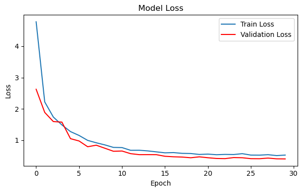

```python
# Plot training and validation loss graphs
plot_loss(history_epoch3)
```

##### 7.2.7.4 Plotting the metrics graph

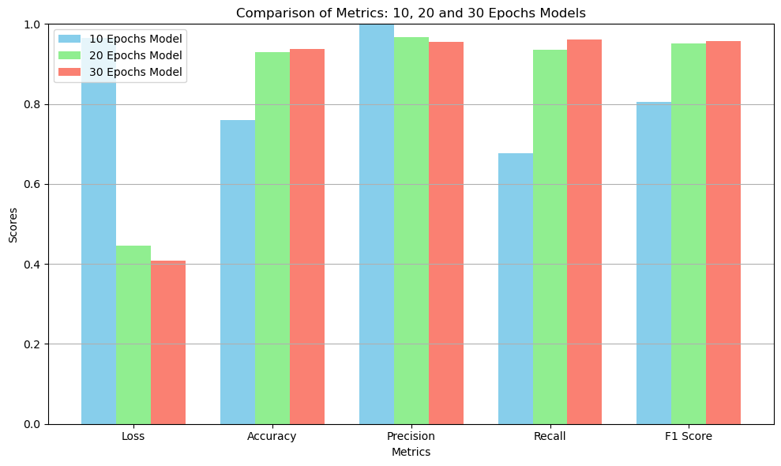

```python
# Extracting relevant Metric Scores
epoch1_scores = {'Loss':epoch1_metrics[0], 'Accuracy': epoch1_metrics[1], 'Precision': epoch1_metrics[2], 'Recall': epoch1_metrics[3],
               'F1 Score': epoch1_metrics[4]}
epoch2_scores = {'Loss':epoch2_metrics[0], 'Accuracy': epoch2_metrics[1], 'Precision': epoch2_metrics[2], 'Recall': epoch2_metrics[3],
              'F1 Score': epoch2_metrics[4]}
epoch3_scores = {'Loss':epoch3_metrics[0], 'Accuracy': epoch3_metrics[1], 'Precision': epoch3_metrics[2], 'Recall': epoch3_metrics[3],
                   'F1 Score': epoch3_metrics[4]}

# Extract metric names and their values
metrics = list(epoch1_scores.keys())
epoch1_values = list(epoch1_scores.values())
epoch2_values = list(epoch2_scores.values())
epoch3_values = list(epoch3_scores.values())

# Create an index for the groups
x = np.arange(len(metrics))

# Define the width of the bars
width = 0.25

# Plotting the bar chart
plt.figure(figsize=(10, 6))
plt.bar(x - width, epoch1_values, width, label='10 Epochs Model', color='skyblue')
plt.bar(x, epoch2_values, width, label='20 Epochs Model', color='lightgreen')
plt.bar(x + width, epoch3_values, width, label='30 Epochs Model', color='salmon')

# Adding labels and title
plt.xlabel('Metrics')
plt.ylabel('Scores')
plt.title('Comparison of Metrics: 10, 20 and 30 Epochs Models')
plt.xticks(x, metrics)
plt.ylim(0, 1)  # Limits from 0 to 1 for better visualization of percentage-based scores
plt.legend(loc='best')

plt.grid(axis='y')
plt.tight_layout()
plt.show()
```

Comparing the performance across different epochs, the 10-epoch model shows the highest test loss (0.966) and lower accuracy (0.760), indicating underfitting and insufficient training time. Although it has a high precision (0.998), it has a lower recall (0.676) and F1 score (0.806). The 20-epoch model demonstrates a significant improvement with a reduced test loss (0.445) and higher accuracy (0.929), reflecting substantial improvement in performance and a good balance between underfitting and overfitting. It also has a balanced precision (0.967) and recall (0.936), leading to a higher F1 score (0.951). The 30-epoch model further enhances performance, achieving the lowest test loss (0.408), the highest accuracy (0.938), and strong precision (0.955) and recall (0.961), with the best F1 score (0.958). The steadily decreasing loss graph with minimal outliers for the 30-epoch model indicates it effectively balances bias and variance, making it the optimal choice for the best overall performance and generalization.

### 7.3 Hyperparameter Tuning with K-Fold Cross-Validation

Hyperparameter tuning is crucial for optimizing model performance, and K-Fold cross-validation provides a robust method to assess model effectiveness. In this validation method, the data is divided into K subsets. The model trains on K-1 of these subsets and validates on the remaining subset, repeating the process K times. The results are then averaged to obtain a reliable performance estimate.

For this tuning, we used grid search together with K-Fold cross-validation to explore different combinations of hyperparameters, including dropout rate, batch size, and learning rate. The process involved defining a model with these parameters and evaluating its performance across multiple folds. We used the KerasClassifier and GridSearchCV from scikit-learn to automate this process. The base model used a well-defined architecture consisting of several dense layers, dropout layers for regularization, and L2 regularization to mitigate overfitting. The architecture was designed based on all the earlier experiments to help decide the best parameters.

Hyperparameters Considered:  
Learning Rate: I tested different values to determine the optimal rate for weight updates.  
Dropout Rate: Various dropout rates were evaluated to identify the most effective rate for reducing overfitting.  
Batch Size: Different batch sizes were tested to find a balance between computational efficiency and model performance.  
Grid Search with K-Fold Cross-Validation: Using KerasClassifier from scikeras and GridSearchCV from scikit-learn, I set up the grid search to evaluate combinations of these hyperparameters. Due to computing resource constraints, the epochs for each model were limited to 10. Despite this limitation, grid search was used to find the best performing parameter combination across 3 folds of cross-validation.

```python
# Define the model function
def create_model(learning_rate=0.001, dropout_rate=0.3):
    model = Sequential([
        Flatten(input_shape=(64, 64, 3)),  # Flatten the input layer for fully connected layers
        Dense(256, activation='relu', kernel_regularizer=l2(0.01)),  # First hidden layer with L2 regularization
        Dropout(dropout_rate),  # Dropout layer to prevent overfitting
        Dense(128, activation='relu', kernel_regularizer=l2(0.01)),  # Second hidden layer with L2 regularization
        Dropout(dropout_rate),  # Dropout layer to prevent overfitting
        Dense(64, activation='relu', kernel_regularizer=l2(0.01)),  # Third hidden layer with L2 regularization
        Dropout(dropout_rate),  # Dropout layer to prevent overfitting
        Dense(32, activation='relu', kernel_regularizer=l2(0.01)),  # Fourth hidden layer with L2 regularization
        Dropout(dropout_rate),  # Dropout layer to prevent overfitting
        Dense(1, activation='sigmoid')  # Output layer for binary classification
    ])
    # Compile the model
    model.compile(optimizer=Adam(learning_rate=learning_rate),
                  loss='binary_crossentropy',
                  metrics=['accuracy', Precision(name='precision'), Recall(name='recall')])

    return model

# Create a KerasClassifier using a lambda function to pass the parameters correctly
model = KerasClassifier(model=create_model, verbose=0)

# Define the grid search parameters
param_grid = {
    'model__learning_rate': [0.0001, 0.001, 0.01],
    'model__dropout_rate': [0.3, 0.5, 0.7],
    'batch_size': [32, 64, 128]
}

# Initialize K-Fold with 3 splits
kfold = KFold(n_splits=3, shuffle=True, random_state=42)

# Perform grid search with K-Fold cross-validation
grid = GridSearchCV(estimator=model, param_grid=param_grid, cv=kfold, n_jobs=-1, scoring='accuracy')

# Fit the grid search
grid_result = grid.fit(train_images, train_binary_labels, epochs=10)

# Display best hyperparameters
print(f"Best Hyperparameters: {grid_result.best_params_}")
```

```
Best Hyperparameters: {'batch_size': 64, 'model__dropout_rate': 0.3, 'model__learning_rate': 0.001}
```

The grid search identified the best hyperparameters as follows:  
`Batch Size`: 64  
`Dropout Rate`: 0.3  
`Learning Rate`: 0.001

With the best hyperparameters determined, I will now use these values to construct and train the final model. This final model will leverage the optimal parameters to achieve the best possible performance on the task, utilizing all the insights gained from the previous experimental phases.

### 7.4 Constructing the Best Model

Using the optimal hyperparameters identified from K-Fold cross-validation—namely, a batch size of 64, a dropout rate of 0.3, and a learning rate of 0.001—I will now construct the final model. This model will integrate other best practices discovered through earlier experimentation, including:

- Architecture: The deeper model architecture, which has proven effective in capturing complex patterns and hierarchical features in the data.
- Regularization: Implementation of dropout layers and L2 regularization to combat overfitting and improve generalization.
- Optimizer: The Adam optimizer, selected for its adaptive learning rate capabilities that enhance convergence.
- Epochs: Training the model for 30 epochs to ensure thorough learning without overfitting.

This comprehensive approach combines the strengths of each technique and parameter to build a robust model. The next step will be to train this model and evaluate its performance, focusing on metrics such as accuracy, precision, recall, and F1 score to assess its effectiveness in comparison to previous models.

```python
# Define the model
best_model = Sequential([
        Flatten(input_shape=(64, 64, 3)),  # Flatten the input layer for fully connected layers
        Dense(256, activation='relu', kernel_regularizer=l2(0.01)),  # First hidden layer with L2 regularization
        Dropout(0.3),  # Dropout layer to prevent overfitting
        Dense(128, activation='relu', kernel_regularizer=l2(0.01)),  # Second hidden layer with L2 regularization
        Dropout(0.3),  # Dropout layer to prevent overfitting
        Dense(64, activation='relu', kernel_regularizer=l2(0.01)),  # Third hidden layer with L2 regularization
        Dropout(0.3),  # Dropout layer to prevent overfitting
        Dense(32, activation='relu', kernel_regularizer=l2(0.01)),  # Fourth hidden layer with L2 regularization
        Dropout(0.3),  # Dropout layer to prevent overfitting
        Dense(1, activation='sigmoid')  # Output layer for binary classification
    ])

# Compile the model
best_model.compile(optimizer=Adam(learning_rate=0.001), loss='binary_crossentropy',
                   metrics=['accuracy', Precision(name='precision'), Recall(name='recall'), F1Score(name='f1', average='micro')])

# Print the model summary to check the structure
best_model.summary()
```

```
Model: "sequential_22"
```

```
┏━━━━━━━━━━━━━━━━━━━━━━━━━━━━━━━━━┳━━━━━━━━━━━━━━━━━━━━━━━━┳━━━━━━━━━━━━━━━┓
┃ Layer (type)                    ┃ Output Shape           ┃       Param # ┃
┡━━━━━━━━━━━━━━━━━━━━━━━━━━━━━━━━━╇━━━━━━━━━━━━━━━━━━━━━━━━╇━━━━━━━━━━━━━━━┩
│ flatten_22 (Flatten)            │ (None, 12288)          │             0 │
├─────────────────────────────────┼────────────────────────┼───────────────┤
│ dense_105 (Dense)               │ (None, 256)            │     3,145,984 │
├─────────────────────────────────┼────────────────────────┼───────────────┤
│ dropout_76 (Dropout)            │ (None, 256)            │             0 │
├─────────────────────────────────┼────────────────────────┼───────────────┤
│ dense_106 (Dense)               │ (None, 128)            │        32,896 │
├─────────────────────────────────┼────────────────────────┼───────────────┤
│ dropout_77 (Dropout)            │ (None, 128)            │             0 │
├─────────────────────────────────┼────────────────────────┼───────────────┤
│ dense_107 (Dense)               │ (None, 64)             │         8,256 │
├─────────────────────────────────┼────────────────────────┼───────────────┤
│ dropout_78 (Dropout)            │ (None, 64)             │             0 │
├─────────────────────────────────┼────────────────────────┼───────────────┤
│ dense_108 (Dense)               │ (None, 32)             │         2,080 │
├─────────────────────────────────┼────────────────────────┼───────────────┤
│ dropout_79 (Dropout)            │ (None, 32)             │             0 │
├─────────────────────────────────┼────────────────────────┼───────────────┤
│ dense_109 (Dense)               │ (None, 1)              │            33 │
└─────────────────────────────────┴────────────────────────┴───────────────┘
```

```
 Total params: 3,189,249 (12.17 MB)
```

```
 Trainable params: 3,189,249 (12.17 MB)
```

```
 Non-trainable params: 0 (0.00 B)
```

```python
# Train the model
history_best = best_model.fit(
    train_images,
    train_binary_labels,
    validation_data=(val_images, val_binary_labels),
    epochs=30,
    batch_size=64,
    verbose=2,
    class_weight=class_weights_dict
)
```

```
47/47 - 5s - 104ms/step - accuracy: 0.5289 - f1: 0.8488 - loss: 5.7457 - precision: 0.7497 - recall: 0.5422 - val_accuracy: 0.8783 - val_f1: 0.8492 - val_loss: 3.4710 - val_precision: 0.8913 - val_recall: 0.9511
47/47 - 1s - 30ms/step - accuracy: 0.6323 - f1: 0.8488 - loss: 2.9091 - precision: 0.8181 - recall: 0.6447 - val_accuracy: 0.7380 - val_f1: 0.8492 - val_loss: 2.3975 - val_precision: 0.9863 - val_recall: 0.6540
47/47 - 1s - 30ms/step - accuracy: 0.7233 - f1: 0.8488 - loss: 2.1322 - precision: 0.8905 - recall: 0.7123 - val_accuracy: 0.8663 - val_f1: 0.8492 - val_loss: 1.7442 - val_precision: 0.9689 - val_recall: 0.8460
47/47 - 1s - 29ms/step - accuracy: 0.7866 - f1: 0.8488 - loss: 1.7397 - precision: 0.9147 - recall: 0.7836 - val_accuracy: 0.9225 - val_f1: 0.8492 - val_loss: 1.4036 - val_precision: 0.9395 - val_recall: 0.9565
47/47 - 1s - 28ms/step - accuracy: 0.8070 - f1: 0.8488 - loss: 1.4775 - precision: 0.9320 - recall: 0.7963 - val_accuracy: 0.9184 - val_f1: 0.8492 - val_loss: 1.2046 - val_precision: 0.9623 - val_recall: 0.9257
47/47 - 1s - 29ms/step - accuracy: 0.7952 - f1: 0.8488 - loss: 1.3523 - precision: 0.9321 - recall: 0.7790 - val_accuracy: 0.8984 - val_f1: 0.8492 - val_loss: 1.3255 - val_precision: 0.9648 - val_recall: 0.8949
47/47 - 1s - 29ms/step - accuracy: 0.7518 - f1: 0.8488 - loss: 1.3058 - precision: 0.9098 - recall: 0.7364 - val_accuracy: 0.8369 - val_f1: 0.8492 - val_loss: 1.1763 - val_precision: 0.9864 - val_recall: 0.7899
47/47 - 1s - 28ms/step - accuracy: 0.7474 - f1: 0.8488 - loss: 1.1576 - precision: 0.9210 - recall: 0.7191 - val_accuracy: 0.9184 - val_f1: 0.8492 - val_loss: 0.8768 - val_precision: 0.9658 - val_recall: 0.9221
47/47 - 1s - 28ms/step - accuracy: 0.7615 - f1: 0.8488 - loss: 1.0756 - precision: 0.9149 - recall: 0.7459 - val_accuracy: 0.9291 - val_f1: 0.8492 - val_loss: 0.8610 - val_precision: 0.9400 - val_recall: 0.9656
47/47 - 1s - 28ms/step - accuracy: 0.7524 - f1: 0.8488 - loss: 0.9904 - precision: 0.9169 - recall: 0.7305 - val_accuracy: 0.9372 - val_f1: 0.8492 - val_loss: 0.7798 - val_precision: 0.9316 - val_recall: 0.9873
47/47 - 1s - 28ms/step - accuracy: 0.7728 - f1: 0.8488 - loss: 0.8905 - precision: 0.9201 - recall: 0.7577 - val_accuracy: 0.9158 - val_f1: 0.8492 - val_loss: 0.6776 - val_precision: 0.9729 - val_recall: 0.9112
47/47 - 1s - 28ms/step - accuracy: 0.7447 - f1: 0.8488 - loss: 0.8392 - precision: 0.9251 - recall: 0.7114 - val_accuracy: 0.8810 - val_f1: 0.8492 - val_loss: 0.7455 - val_precision: 0.9833 - val_recall: 0.8533
47/47 - 1s - 28ms/step - accuracy: 0.7531 - f1: 0.8488 - loss: 0.7771 - precision: 0.9282 - recall: 0.7210 - val_accuracy: 0.9398 - val_f1: 0.8492 - val_loss: 0.5712 - val_precision: 0.9503 - val_recall: 0.9692
47/47 - 1s - 28ms/step - accuracy: 0.7504 - f1: 0.8488 - loss: 0.7433 - precision: 0.9204 - recall: 0.7241 - val_accuracy: 0.9037 - val_f1: 0.8492 - val_loss: 0.5591 - val_precision: 0.9762 - val_recall: 0.8913
47/47 - 1s - 28ms/step - accuracy: 0.7364 - f1: 0.8488 - loss: 0.7122 - precision: 0.9296 - recall: 0.6951 - val_accuracy: 0.9345 - val_f1: 0.8492 - val_loss: 0.5462 - val_precision: 0.9532 - val_recall: 0.9583
47/47 - 1s - 28ms/step - accuracy: 0.7417 - f1: 0.8488 - loss: 0.6622 - precision: 0.9420 - recall: 0.6924 - val_accuracy: 0.8476 - val_f1: 0.8492 - val_loss: 0.5907 - val_precision: 0.9867 - val_recall: 0.8043
47/47 - 1s - 29ms/step - accuracy: 0.7477 - f1: 0.8488 - loss: 0.6278 - precision: 0.9305 - recall: 0.7110 - val_accuracy: 0.9078 - val_f1: 0.8492 - val_loss: 0.4591 - val_precision: 0.9708 - val_recall: 0.9022
47/47 - 1s - 29ms/step - accuracy: 0.7595 - f1: 0.8488 - loss: 0.6279 - precision: 0.9299 - recall: 0.7287 - val_accuracy: 0.9398 - val_f1: 0.8492 - val_loss: 0.5232 - val_precision: 0.9393 - val_recall: 0.9819
47/47 - 1s - 29ms/step - accuracy: 0.7879 - f1: 0.8488 - loss: 0.6290 - precision: 0.8957 - recall: 0.8063 - val_accuracy: 0.9385 - val_f1: 0.8492 - val_loss: 0.4214 - val_precision: 0.9502 - val_recall: 0.9674
47/47 - 1s - 28ms/step - accuracy: 0.7872 - f1: 0.8488 - loss: 0.5972 - precision: 0.9045 - recall: 0.7954 - val_accuracy: 0.9385 - val_f1: 0.8492 - val_loss: 0.3785 - val_precision: 0.9332 - val_recall: 0.9873
```

[output cut: 10 more lines]

```python
# Evaluate the model on the test set
best_metrics = best_model.evaluate(test_images, test_binary_labels, verbose=0)
print(f"Test Loss: {best_metrics[0]:.3f}")
print(f"Test Accuracy: {best_metrics[1]:.3f}")
print(f"Test Precision: {best_metrics[2]:.3f}")
print(f"Test Recall: {best_metrics[3]:.3f}")
print(f"Test F1 Score: {best_metrics[4]:.3f}")
```

```
Test Loss: 0.443
Test Accuracy: 0.940
Test Precision: 0.945
Test Recall: 0.975
Test F1 Score: 0.960
```

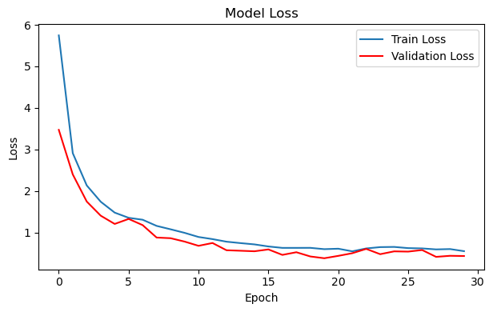

```python
# Plot training and validation loss graphs
plot_loss(history_best)
```

**Best Model Results:**

- `Test Loss`: 0.443
- `Test Accuracy`: 0.940
- `Test Precision`: 0.945
- `Test Recall`: 0.975
- `Test F1 Score`: 0.960

#### 7.4.1 Testing the Best Model

To evaluate the best model, I will select a random image from the test dataset and use the model to predict its classification. This will help determine whether the model can accurately classify images. By comparing the predicted label with the actual label, I can assess the model's accuracy on individual samples.

```
1/1 ━━━━━━━━━━━━━━━━━━━━ 0s 20ms/step
```

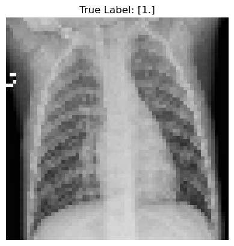

```
True Label: [1.]
Predicted Class: 1
Prediction: Correct!
```

```python
# Select a random index from the test set
random_index = random.randint(0, len(test_images) - 1)

# Get the random image and its corresponding label
random_image = test_images[random_index]
true_label = test_binary_labels[random_index]

# Preprocess the image to match input dimensions for the model
img_array = np.expand_dims(random_image, axis=0)  # Add batch dimension
img_array = img_array / 255.0  # Normalize if required (adjust based on your preprocessing)

# Make a prediction
prediction = best_model.predict(img_array)
predicted_class = (prediction > 0.5).astype(int)[0][0]  # Convert prediction to class label (0 or 1)

# Display the random image
plt.imshow(random_image)
plt.title(f"True Label: {true_label}")
plt.axis('off')
plt.show()

# Display results
print(f"True Label: {true_label}")
print(f"Predicted Class: {predicted_class}")

# Check if the prediction is correct or wrong
if predicted_class == true_label:
    print("Prediction: Correct!")
else:
    print("Prediction: Wrong!")
```

## 8. Conclusion

The objective of this report was to develop a robust neural network model for accurately classifying chest X-ray images into two categories. This was achieved by experimenting with different model architectures, regularization techniques, optimizers, and hyperparameters. The following summarizes the key findings and outcomes:

Key Learning Points: Throughout this project, the importance of hyperparameter tuning in enhancing model performance has been emphasized. The choice of regularization techniques such as L2 regularization and dropout was essential in preventing overfitting and ensuring the model generalized well to unseen data. Experimenting with different model architectures demonstrated that deeper models with sufficient regularization could achieve superior results. Finally, K-Fold cross-validation proved invaluable in identifying the best set of hyperparameters for the model.

Future Directions:

- Exploring more advanced architectures, such as Convolutional Neural Networks (CNNs), which may better capture spatial features in the images.
- Utilizing transfer learning to leverage pre-trained models on larger datasets, which may further improve performance.
- Investigating other data augmentation techniques to enhance the dataset size and diversity, potentially improving the model's robustness and accuracy, such as applying random transformations, such as rotations, translations, flips, and zooms, to artificially increase the training dataset size and make the model more robust.

Overall, the objective of developing an optimal model for classifying chest X-ray images was successfully achieved, and the findings from this study provide a solid foundation for future improvements and exploration.

### References

- Kostas Diamantaras(2020) Chest Xrays: bacterial /viral pneumonia/normal  
  https://www.kaggle.com/datasets/kostasdiamantaras/chest-xrays-bacterial-viral-pneumonia-normal
- Kermany, Daniel; Zhang, Kang; Goldbaum, Michael (2018), “Labeled Optical Coherence Tomography (OCT) and Chest X-Ray Images for Classification”, Mendeley Data, V2, doi: 10.17632/rscbjbr9sj.2

https://data.mendeley.com/datasets/rscbjbr9sj/2

- **Chollet, F.**(2018) Deep Learning with Python. Manning Publications.